# Same Day VAR models predicting Coping and Self-Efficacy

Kevin Kuehn

06/08/2020

# Reading in the data, converting data from matrix to a data frame

```r
data<-read.csv("~/Documents/Writing/YDSP collab/YDSP/Daily data.csv")
data2<-read.spss("~/Documents/Writing/YDSP collab/YDSP/Baseline_variables.sav")
data<-as.data.frame(data)
```

30 variables and 952 observations. 28 observations per person, 34 people (no ID 208 and 219)

Each day, teens indicated whether or not they engaged in eight coping strategies in reference to suicidal ideation (“When you had thoughts of killing yourself in the last 24 hours, did you do any of these things to deal or cope with your thoughts?”) or, when suicidal ideation was not present, in reference to feelings or stressful events (“In the last 24 hours, did you do any of these things to deal or cope with your feelings or any stressful situations?). The eight coping behaviors included: (1) talked to a family member, (2) talked to a friend or another support person, (3) talked to a therapist, counselor, or doctor, (4) contacted a crisis line, (5) tried to distract self with something else, (6) tried to relax or do something comforting, (7) tried to tell self something calming or positive, and (8) tried a cognitive strategy that involved either (a) thinking about reasons for living (on days suicidal ideation was endorsed) or (b) thinking differently about the situation (on days when ideation was not endorsed).

For purposes of these analyses, we could only use participants who had invariant SI and/or who had enough data so that we could impute (> 50% of data).

# Lagging each of the predictor variables for imputation

```r
data<-slide(data=data, Var="coping_sum_3avg",TimeVar="Day",GroupVar ="ID",NewVar="coping_sum_3avg.lag",slideBy=-1)
```

```
##
## Lagging coping_sum_3avg by 1 time units.
```

```r
data<-slide(data=data, Var="all_coping_talkfamily",TimeVar="Day",GroupVar ="ID",NewVar="all_coping_talkfamily.lag",slideBy=-1)
```

```
##
## Lagging all_coping_talkfamily by 1 time units.
```

```r
data<-slide(data=data, Var="all_coping_talkMH",TimeVar="Day",GroupVar ="ID",NewVar="all_coping_talkMH.lag",slideBy=-1)
```

```
##
## Lagging all_coping_talkMH by 1 time units.
```

```r
data<-slide(data=data, Var="all_coping_copingthought",TimeVar="Day",GroupVar ="ID",NewVar="all_coping_copingthought.lag",slideBy=-1)
```

```
##
## Lagging all_coping_copingthought by 1 time units.
```

```r
data<-slide(data=data, Var="all_coping_thinking",TimeVar="Day",GroupVar ="ID",NewVar="all_coping_thinking.lag",slideBy=-1)
```

```
##
## Lagging all_coping_thinking by 1 time units.
```

```r
data<-slide(data=data, Var="all_coping_talkfriend",TimeVar="Day",GroupVar ="ID",NewVar="all_coping_talkfriend.lag",slideBy=-1)
```

```
##
## Lagging all_coping_talkfriend by 1 time units.
```

```r
data<-slide(data=data, Var="all_coping_dis_rel_combined",TimeVar="Day",GroupVar ="ID",NewVar="all_coping_dis_rel_combined.lag",slideBy=-1)
```

```
##
## Lagging all_coping_dis_rel_combined by 1 time units.
```

```r
data<-slide(data=data, Var="all_coping_crisisline",TimeVar="Day",GroupVar ="ID",NewVar="all_coping_crisisline.lag",slideBy=-1)
```

```
##
## Lagging all_coping_crisisline by 1 time units.
```

```r
data<-slide(data=data, Var="coping_sum",TimeVar="Day",GroupVar ="ID",NewVar="coping_sum.lag",slideBy=-1)
```

```
##
## Lagging coping_sum by 1 time units.
```

```r
data<-slide(data=data, Var="all_coping_any",TimeVar="Day",GroupVar ="ID",NewVar="all_coping_any.lag",slideBy=-1)
```

```
##
## Lagging all_coping_any by 1 time units.
```

```r
data<-slide(data=data, Var="SIUrge",TimeVar="Day",GroupVar ="ID",NewVar="SIUrge.lag",slideBy=-1)
```

```
##
## Lagging SIUrge by 1 time units.
```

```r
data<-slide(data=data, Var="Self_Efficacy",TimeVar="Day",GroupVar ="ID",NewVar="Self_Efficacy.lag",slideBy=-1)
```

```
##
## Lagging Self_Efficacy by 1 time units.
```

# Splitting the data into individual data files based on ID

```r
pdat_split <- split(data, data$ID)

new_names<-as.character(c(unique(data$ID)))

for(i in seq_along(pdat_split)){
  new_names[i] <- paste0("pdat", i, sep="")
}

for (i in 1:length(pdat_split)) {
  assign(new_names[i], pdat_split[[i]])
}
```

# Person 202

## Specifying the data structure for imputation

```r
MImodel = pdat2[c(-1,-2)]
MImodel[,1] = as.factor(MImodel[,1])
MImodel[,2] = as.factor(MImodel[,2])
MImodel[,3] = as.factor(MImodel[,3])
MImodel[,4] = as.factor(MImodel[,4])
MImodel[,5] = as.factor(MImodel[,5])
MImodel[,6] = as.factor(MImodel[,6])
MImodel[,7] = as.factor(MImodel[,7])
MImodel[,10] = as.factor(MImodel[,10])
MImodel[,14] = as.factor(MImodel[,14])
MImodel[,15] = as.factor(MImodel[,15])
MImodel[,16] = as.factor(MImodel[,16])
MImodel[,17] = as.factor(MImodel[,17])
MImodel[,18] = as.factor(MImodel[,18])
MImodel[,19] = as.factor(MImodel[,19])
MImodel[,20] = as.factor(MImodel[,20])
MImodel[,22] = as.factor(MImodel[,22])
```

## Imputation

```r
m = 5
imp = mice(MImodel,m = m)
```

```
##
##  * Please inspect the loggedEvents
```

```r
k=24

qhat = matrix(NA, nrow = m,ncol = k)

u = array(NA,dim = c(k,k,m))

for (i in 1:m) {
data.impute = mice::complete(imp,action = i)}

all_coping_talkfamily.imp = as.factor(as.factor(data.impute[,1]))
all_coping_talkMH.imp = as.factor(as.factor(data.impute[,2]))
all_coping_copingthought.imp = as.factor(as.factor(data.impute[,3]))
all_coping_thinking.imp = as.factor(as.factor(data.impute[,4]))
all_coping_talkfriend.imp = as.factor(as.factor(data.impute[,5]))
all_coping_dis_rel_combined.imp = as.factor(as.factor(data.impute[,6]))
all_coping_crisisline.imp  = as.factor(as.factor(data.impute[,7]))
coping_sum.imp = data.impute[,8]
coping_sum_3avg.imp  = data.impute[,9]
all_coping_any.imp = as.factor(as.factor(data.impute[,10]))
SIUrge.imp  = data.impute[,11]
Self_Efficacy.imp = data.impute[,12]

pdat2.imp<-data.frame(all_coping_talkfamily.imp = all_coping_talkfamily.imp,
                      all_coping_talkMH.imp =all_coping_talkMH.imp,
                      all_coping_copingthought.imp = all_coping_copingthought.imp,
                      all_coping_thinking.imp = all_coping_thinking.imp,
                      all_coping_talkfriend.imp = all_coping_talkfriend.imp,
                      all_coping_dis_rel_combined.imp = all_coping_dis_rel_combined.imp,
                      all_coping_any.imp = all_coping_any.imp,
                      SIUrge.imp = SIUrge.imp,
                      Self_Efficacy.imp = Self_Efficacy.imp,
                      coping_sum_3avg.imp = coping_sum_3avg.imp,
                      coping_sum.imp = coping_sum.imp)
```

## Restructuring Data file to create splines

```r
na.df <- data.frame(SIUrge.imp = NA)
vars<-c("SIUrge.imp")
pdat2.1<-pdat2.imp[vars]
pdat2.2<- do.call(rbind, apply(pdat2.1, 1, function(x) {rbind(x, na.df)}))

na.df <- data.frame(all_coping_talkfamily.imp = NA,
        all_coping_talkMH.imp = NA,
        all_coping_copingthought.imp = NA,
        all_coping_thinking.imp = NA,
        all_coping_talkfriend.imp = NA,
        all_coping_dis_rel_combined.imp = NA,
        all_coping_any.imp = NA,
        Self_Efficacy.imp = NA,
        coping_sum.imp = NA,
        coping_sum_3avg.imp = NA)

vars<-c("all_coping_talkfamily.imp",
        "all_coping_talkMH.imp",
        "all_coping_copingthought.imp",
        "all_coping_thinking.imp",
        "all_coping_talkfriend.imp",
        "all_coping_dis_rel_combined.imp",
        "all_coping_any.imp",
        "Self_Efficacy.imp",
        "coping_sum.imp",
        "coping_sum_3avg.imp")
pdat2.3<-pdat2.imp[vars]
pdat2.4 <- do.call(rbind, apply(pdat2.3, 1, function(x) {rbind(na.df, x)}))

pdat2.imp<-cbind(pdat2.4, pdat2.2)
pdat2.imp$Day<-c(1:56)
```

## Creating splines

```r
pdat2.imp<-data.frame(na.spline(pdat2.imp))
pdat2.imp<-round(pdat2.imp)
pdat2.imp$SIUrge.imp[pdat2.imp$SIUrge.imp>7]<-7
pdat2.imp$SIUrge.imp[pdat2.imp$SIUrge.imp<0]<-0
pdat2.imp$Self_Efficacy.imp[pdat2.imp$Self_Efficacy.imp>10]<-10
pdat2.imp$Self_Efficacy.imp[pdat2.imp$Self_Efficacy.imp<0]<-0
pdat2.imp$all_coping_talkMH.imp[pdat2.imp$all_coping_talkMH.imp==-2]<-0
```

```r
cols <- c("all_coping_talkfamily.imp",
        "all_coping_talkMH.imp",
        "all_coping_copingthought.imp",
        "all_coping_thinking.imp",
        "all_coping_talkfriend.imp",
        "all_coping_dis_rel_combined.imp",
        "all_coping_any.imp")

pdat2.imp <- pdat2.imp %>%
     mutate_at(c(cols),list(~recode(., `-3`=0,`-2`=0,`-1`=0,`2`= 1,`3`=1)))

pdat2.imp[cols] <- lapply(pdat2.imp[cols], factor)
```

## Comparing pre vs post splines

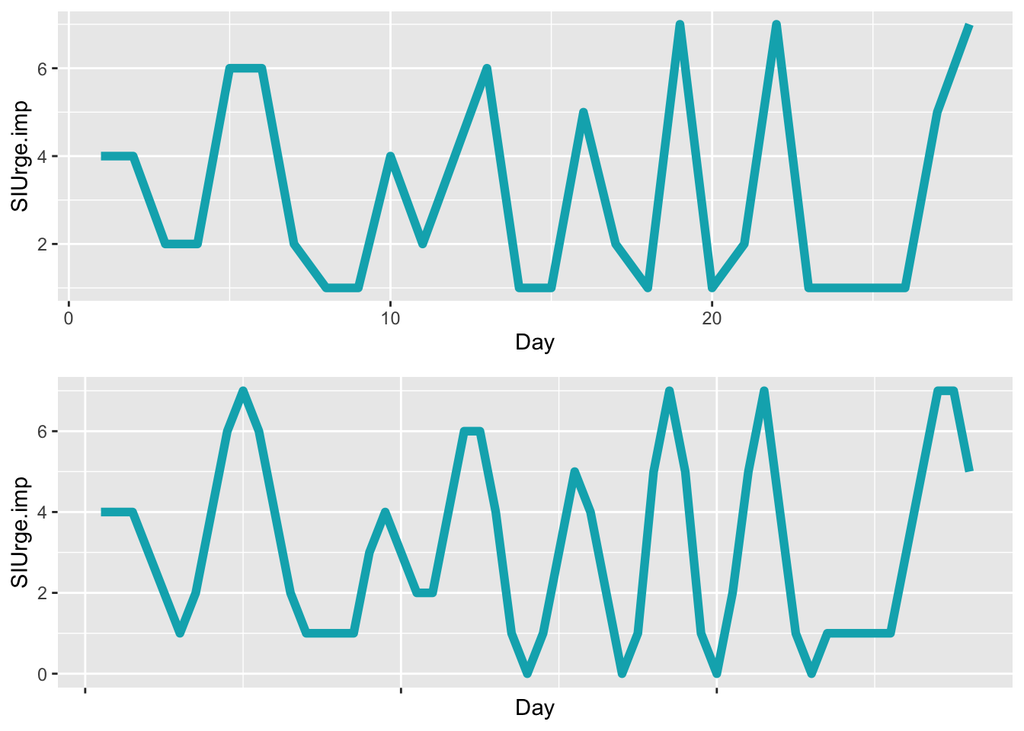

```r
a<-ggplot(data = pdat2, aes(x = Day, y = SIUrge.imp))+
  geom_line(color = "#00AFBB", size = 2)
b<-ggplot(data = pdat2.imp, aes(x = Day, y = SIUrge.imp))+
  geom_line(color = "#00AFBB", size = 2)
ggarrange(a, b + rremove("x.text"),
          ncol = 1, nrow = 2)
```

## Extracting Residuals

```r
mod1<-lm(coping_sum_3avg.imp~Day, data=pdat2.imp)
Coping_sum_3avg_resid = as.numeric(rstandard(mod1))

mod2<-glm(all_coping_talkfamily.imp~Day, data=pdat2.imp, family=binomial(link="logit"))
Coping_TalkFamily_resid<-as.numeric(rstandard(mod2))

mod3<-glm(all_coping_talkMH.imp~Day, data=pdat2.imp, family=binomial(link="logit"))
Coping_TalkMH_resid<-as.numeric(rstandard(mod3))

mod4<-glm(all_coping_any.imp~Day, data=pdat2.imp, family=binomial(link="logit"))
Coping_any_resid<-as.numeric(rstandard(mod4))

mod5<-glm(all_coping_dis_rel_combined.imp~Day, data=pdat2.imp, family=binomial(link="logit"))
Coping_dis_rel_resid<-as.numeric(rstandard(mod5))

mod6<-glm(all_coping_copingthought.imp~Day, data=pdat2.imp, family=binomial(link="logit"))
Coping_Thought_resid<-as.numeric(rstandard(mod6))

mod7<-glm(all_coping_thinking.imp~Day, data=pdat2.imp, family=binomial(link="logit"))
Coping_Thinking_resid<-as.numeric(rstandard(mod7))

mod8<-lm(coping_sum.imp~Day, data=pdat2.imp, na.action=na.exclude)
Coping_sum_resid<-as.numeric(rstandard(mod8))

mod9<-glm(all_coping_talkfriend.imp~Day, data=pdat2.imp, family=binomial(link="logit"))
Coping_TalkFriend_resid<-as.numeric(rstandard(mod9))

mod10<-lm(SIUrge.imp~Day, data=pdat2.imp)
SIUrge_resid<-as.numeric(rstandard(mod10))

mod11<-lm(Self_Efficacy.imp~Day, data=pdat2.imp)
Efficacy_resid<-as.numeric(rstandard(mod11))

pdat2<-as.data.frame(cbind(Coping_TalkFamily_resid, Coping_TalkMH_resid, Coping_dis_rel_resid, Coping_Thought_resid, Coping_Thinking_resid, Coping_TalkFriend_resid, Coping_sum_resid, Efficacy_resid, SIUrge_resid, Coping_any_resid, Coping_sum_3avg_resid))
```

## Calculating difference scores

```r
attach(pdat2)
Coping_TalkFamily_resid=diff(Coping_TalkFamily_resid)
Coping_TalkMH_resid = diff(Coping_TalkMH_resid)
Coping_dis_rel_resid = diff(Coping_dis_rel_resid)
Coping_Thought_resid = diff(Coping_Thought_resid)
Coping_Thinking_resid = diff(Coping_Thinking_resid)
Coping_TalkFriend_resid = diff(Coping_TalkFriend_resid)
Coping_any_resid = diff(Coping_any_resid)
Coping_sum_resid = diff(Coping_sum_resid)
SIUrge_resid =  diff(SIUrge_resid)
Efficacy_resid=diff(Efficacy_resid)
Coping_sum_3avg_resid = diff(Coping_sum_3avg_resid)

pdat2<-as.data.frame(cbind(Coping_TalkFamily_resid, Coping_TalkMH_resid, Coping_dis_rel_resid, Coping_Thought_resid, Coping_Thinking_resid, Coping_TalkFriend_resid, Coping_sum_resid, Efficacy_resid, SIUrge_resid, Coping_sum_3avg_resid))
pdat2$day<-c(1:55)
```

## Same Day models with SI Urge predicting changes in coping

```r
pdat2.2<-c("SIUrge_resid", "Coping_sum_3avg_resid")
pdat2.2<-pdat2[pdat2.2]
coping_var=VAR(pdat2.2,p=1,  type="const")
causality(coping_var, cause="SIUrge_resid")$Granger
```

```
##
##  Granger causality H0: SIUrge_resid do not Granger-cause
##  Coping_sum_3avg_resid
##
## data:  VAR object coping_var
## F-Test = 0.056427, df1 = 1, df2 = 102, p-value = 0.8127
```

```r
summary(coping_var)
```

```
##
## VAR Estimation Results:
## =========================
## Endogenous variables: SIUrge_resid, Coping_sum_3avg_resid
## Deterministic variables: const
## Sample size: 54
## Log Likelihood: -95.085
## Roots of the characteristic polynomial:
## 0.5055 0.05981
## Call:
## VAR(y = pdat2.2, p = 1, type = "const")
##
##
## Estimation results for equation SIUrge_resid:
## =============================================
## SIUrge_resid = SIUrge_resid.l1 + Coping_sum_3avg_resid.l1 + const
##
##                           Estimate Std. Error t value Pr(>|t|)
## SIUrge_resid.l1           0.504926   0.123644   4.084 0.000157 ***
## Coping_sum_3avg_resid.l1 -0.015048   0.200297  -0.075 0.940407
## const                    -0.004476   0.099857  -0.045 0.964423
## ---
## Signif. codes:  0 '***' 0.001 '**' 0.01 '*' 0.05 '.' 0.1 ' ' 1
##
##
## Residual standard error: 0.7328 on 51 degrees of freedom
## Multiple R-Squared: 0.2475,  Adjusted R-squared: 0.218
## F-statistic: 8.389 on 2 and 51 DF,  p-value: 0.0007086
##
##
## Estimation results for equation Coping_sum_3avg_resid:
## ======================================================
## Coping_sum_3avg_resid = SIUrge_resid.l1 + Coping_sum_3avg_resid.l1 + const
##
##                          Estimate Std. Error t value Pr(>|t|)
## SIUrge_resid.l1          -0.01990    0.08379  -0.238    0.813
## Coping_sum_3avg_resid.l1 -0.05928    0.13574  -0.437    0.664
## const                    -0.03542    0.06767  -0.523    0.603
##
##
## Residual standard error: 0.4966 on 51 degrees of freedom
## Multiple R-Squared: 0.005256,    Adjusted R-squared: -0.03375
## F-statistic: 0.1347 on 2 and 51 DF,  p-value: 0.8743
##
##
##
## Covariance matrix of residuals:
##                       SIUrge_resid Coping_sum_3avg_resid
## SIUrge_resid                0.5370                0.0489
## Coping_sum_3avg_resid       0.0489                0.2466
##
## Correlation matrix of residuals:
##                       SIUrge_resid Coping_sum_3avg_resid
## SIUrge_resid                1.0000                0.1344
## Coping_sum_3avg_resid       0.1344                1.0000
```

```r
pdat2.2<-c("SIUrge_resid", "Coping_TalkFamily_resid")
pdat2.2<-pdat2[pdat2.2]
coping_var=VAR(pdat2.2,p=1,  type="const")
causality(coping_var, cause="SIUrge_resid")$Granger
```

```
##
##  Granger causality H0: SIUrge_resid do not Granger-cause
##  Coping_TalkFamily_resid
##
## data:  VAR object coping_var
## F-Test = 5.3662, df1 = 1, df2 = 102, p-value = 0.02253
```

```r
summary(coping_var)
```

```
##
## VAR Estimation Results:
## =========================
## Endogenous variables: SIUrge_resid, Coping_TalkFamily_resid
## Deterministic variables: const
## Sample size: 54
## Log Likelihood: -128.081
## Roots of the characteristic polynomial:
## 0.3678 0.113
## Call:
## VAR(y = pdat2.2, p = 1, type = "const")
##
##
## Estimation results for equation SIUrge_resid:
## =============================================
## SIUrge_resid = SIUrge_resid.l1 + Coping_TalkFamily_resid.l1 + const
##
##                            Estimate Std. Error t value Pr(>|t|)
## SIUrge_resid.l1             0.56572    0.12160   4.652 2.36e-05 ***
## Coping_TalkFamily_resid.l1 -0.23637    0.11198  -2.111   0.0397 *
## const                      -0.01067    0.09574  -0.111   0.9117
## ---
## Signif. codes:  0 '***' 0.001 '**' 0.01 '*' 0.05 '.' 0.1 ' ' 1
##
##
## Residual standard error: 0.7028 on 51 degrees of freedom
## Multiple R-Squared: 0.3079,  Adjusted R-squared: 0.2808
## F-statistic: 11.34 on 2 and 51 DF,  p-value: 8.397e-05
##
##
## Estimation results for equation Coping_TalkFamily_resid:
## ========================================================
## Coping_TalkFamily_resid = SIUrge_resid.l1 + Coping_TalkFamily_resid.l1 + const
##
##                            Estimate Std. Error t value Pr(>|t|)
## SIUrge_resid.l1             0.37902    0.16362   2.317   0.0246 *
## Coping_TalkFamily_resid.l1 -0.08488    0.15068  -0.563   0.5757
## const                       0.02154    0.12882   0.167   0.8679
## ---
## Signif. codes:  0 '***' 0.001 '**' 0.01 '*' 0.05 '.' 0.1 ' ' 1
##
##
## Residual standard error: 0.9456 on 51 degrees of freedom
## Multiple R-Squared: 0.0952,  Adjusted R-squared: 0.05972
## F-statistic: 2.683 on 2 and 51 DF,  p-value: 0.07799
##
##
##
## Covariance matrix of residuals:
##                         SIUrge_resid Coping_TalkFamily_resid
## SIUrge_resid                 0.49392                -0.01508
## Coping_TalkFamily_resid     -0.01508                 0.89424
##
## Correlation matrix of residuals:
##                         SIUrge_resid Coping_TalkFamily_resid
## SIUrge_resid                 1.00000                -0.02269
## Coping_TalkFamily_resid     -0.02269                 1.00000
```

```r
pdat2.2<-c("Coping_TalkMH_resid", "SIUrge_resid")
pdat2.2<-pdat2[pdat2.2]
coping_var=VAR(pdat2.2,p=1,  type="const")
causality(coping_var, cause="SIUrge_resid")$Granger
```

```
##
##  Granger causality H0: SIUrge_resid do not Granger-cause
##  Coping_TalkMH_resid
##
## data:  VAR object coping_var
## F-Test = 13.601, df1 = 1, df2 = 102, p-value = 0.0003646
```

```r
summary(coping_var)
```

```
##
## VAR Estimation Results:
## =========================
## Endogenous variables: Coping_TalkMH_resid, SIUrge_resid
## Deterministic variables: const
## Sample size: 54
## Log Likelihood: -129.076
## Roots of the characteristic polynomial:
## 0.2617 0.1802
## Call:
## VAR(y = pdat2.2, p = 1, type = "const")
##
##
## Estimation results for equation Coping_TalkMH_resid:
## ====================================================
## Coping_TalkMH_resid = Coping_TalkMH_resid.l1 + SIUrge_resid.l1 + const
##
##                        Estimate Std. Error t value Pr(>|t|)
## Coping_TalkMH_resid.l1 -0.18880    0.13436  -1.405 0.166045
## SIUrge_resid.l1         0.66799    0.18113   3.688 0.000549 ***
## const                   0.02422    0.13600   0.178 0.859340
## ---
## Signif. codes:  0 '***' 0.001 '**' 0.01 '*' 0.05 '.' 0.1 ' ' 1
##
##
## Residual standard error: 0.9986 on 51 degrees of freedom
## Multiple R-Squared: 0.2105,  Adjusted R-squared: 0.1796
## F-statistic:   6.8 on 2 and 51 DF,  p-value: 0.00241
##
##
## Estimation results for equation SIUrge_resid:
## =============================================
## SIUrge_resid = Coping_TalkMH_resid.l1 + SIUrge_resid.l1 + const
##
##                         Estimate Std. Error t value Pr(>|t|)
## Coping_TalkMH_resid.l1 -0.248863   0.092241  -2.698  0.00943 **
## SIUrge_resid.l1         0.630714   0.124346   5.072 5.56e-06 ***
## const                   0.001254   0.093367   0.013  0.98933
## ---
## Signif. codes:  0 '***' 0.001 '**' 0.01 '*' 0.05 '.' 0.1 ' ' 1
##
##
## Residual standard error: 0.6856 on 51 degrees of freedom
## Multiple R-Squared: 0.3414,  Adjusted R-squared: 0.3156
## F-statistic: 13.22 on 2 and 51 DF,  p-value: 2.366e-05
##
##
##
## Covariance matrix of residuals:
##                     Coping_TalkMH_resid SIUrge_resid
## Coping_TalkMH_resid              0.9973       0.1034
## SIUrge_resid                     0.1034       0.4700
##
## Correlation matrix of residuals:
##                     Coping_TalkMH_resid SIUrge_resid
## Coping_TalkMH_resid               1.000        0.151
## SIUrge_resid                      0.151        1.000
```

```r
pdat2.2<-c("Coping_dis_rel_resid", "SIUrge_resid")
pdat2.2<-pdat2[pdat2.2]
coping_var=VAR(pdat2.2,p=1,  type="const")
causality(coping_var, cause="SIUrge_resid")$Granger
```

```
##
##  Granger causality H0: SIUrge_resid do not Granger-cause
##  Coping_dis_rel_resid
##
## data:  VAR object coping_var
## F-Test = 0.19811, df1 = 1, df2 = 102, p-value = 0.6572
```

```r
summary(coping_var)
```

```
##
## VAR Estimation Results:
## =========================
## Endogenous variables: Coping_dis_rel_resid, SIUrge_resid
## Deterministic variables: const
## Sample size: 54
## Log Likelihood: -129.748
## Roots of the characteristic polynomial:
## 0.5045 0.00955
## Call:
## VAR(y = pdat2.2, p = 1, type = "const")
##
##
## Estimation results for equation Coping_dis_rel_resid:
## =====================================================
## Coping_dis_rel_resid = Coping_dis_rel_resid.l1 + SIUrge_resid.l1 + const
##
##                          Estimate Std. Error t value Pr(>|t|)
## Coping_dis_rel_resid.l1 -0.008065   0.140296  -0.057    0.954
## SIUrge_resid.l1         -0.070328   0.158007  -0.445    0.658
## const                   -0.041691   0.127731  -0.326    0.745
##
##
## Residual standard error: 0.9372 on 51 degrees of freedom
## Multiple R-Squared: 0.003876,    Adjusted R-squared: -0.03519
## F-statistic: 0.09923 on 2 and 51 DF,  p-value: 0.9057
##
##
## Estimation results for equation SIUrge_resid:
## =============================================
## SIUrge_resid = Coping_dis_rel_resid.l1 + SIUrge_resid.l1 + const
##
##                          Estimate Std. Error t value Pr(>|t|)
## Coping_dis_rel_resid.l1 -0.010822   0.109699  -0.099 0.921798
## SIUrge_resid.l1          0.502970   0.123547   4.071 0.000163 ***
## const                   -0.004618   0.099874  -0.046 0.963301
## ---
## Signif. codes:  0 '***' 0.001 '**' 0.01 '*' 0.05 '.' 0.1 ' ' 1
##
##
## Residual standard error: 0.7328 on 51 degrees of freedom
## Multiple R-Squared: 0.2476,  Adjusted R-squared: 0.2181
## F-statistic: 8.391 on 2 and 51 DF,  p-value: 0.0007072
##
##
##
## Covariance matrix of residuals:
##                      Coping_dis_rel_resid SIUrge_resid
## Coping_dis_rel_resid              0.87828     -0.04515
## SIUrge_resid                     -0.04515      0.53697
##
## Correlation matrix of residuals:
##                      Coping_dis_rel_resid SIUrge_resid
## Coping_dis_rel_resid              1.00000     -0.06575
## SIUrge_resid                     -0.06575      1.00000
```

```r
pdat2.2<-c("Coping_Thought_resid", "SIUrge_resid")
pdat2.2<-pdat2[pdat2.2]
coping_var=VAR(pdat2.2,p=1,  type="const")
causality(coping_var, cause="SIUrge_resid")$Granger
```

```
##
##  Granger causality H0: SIUrge_resid do not Granger-cause
##  Coping_Thought_resid
##
## data:  VAR object coping_var
## F-Test = 1.7513, df1 = 1, df2 = 102, p-value = 0.1887
```

```r
summary(coping_var)
```

```
##
## VAR Estimation Results:
## =========================
## Endogenous variables: Coping_Thought_resid, SIUrge_resid
## Deterministic variables: const
## Sample size: 54
## Log Likelihood: -127.459
## Roots of the characteristic polynomial:
## 0.495 0.01052
## Call:
## VAR(y = pdat2.2, p = 1, type = "const")
##
##
## Estimation results for equation Coping_Thought_resid:
## =====================================================
## Coping_Thought_resid = Coping_Thought_resid.l1 + SIUrge_resid.l1 + const
##
##                         Estimate Std. Error t value Pr(>|t|)
## Coping_Thought_resid.l1 -0.03819    0.13156  -0.290    0.773
## SIUrge_resid.l1         -0.20802    0.15719  -1.323    0.192
## const                    0.05322    0.12432   0.428    0.670
##
##
## Residual standard error: 0.913 on 51 degrees of freedom
## Multiple R-Squared: 0.0332,  Adjusted R-squared: -0.004715
## F-statistic: 0.8756 on 2 and 51 DF,  p-value: 0.4228
##
##
## Estimation results for equation SIUrge_resid:
## =============================================
## SIUrge_resid = Coping_Thought_resid.l1 + SIUrge_resid.l1 + const
##
##                          Estimate Std. Error t value Pr(>|t|)
## Coping_Thought_resid.l1  0.070943   0.105128   0.675 0.502836
## SIUrge_resid.l1          0.522673   0.125611   4.161 0.000122 ***
## const                   -0.004702   0.099345  -0.047 0.962438
## ---
## Signif. codes:  0 '***' 0.001 '**' 0.01 '*' 0.05 '.' 0.1 ' ' 1
##
##
## Residual standard error: 0.7296 on 51 degrees of freedom
## Multiple R-Squared: 0.2541,  Adjusted R-squared: 0.2249
## F-statistic: 8.687 on 2 and 51 DF,  p-value: 0.0005665
##
##
##
## Covariance matrix of residuals:
##                      Coping_Thought_resid SIUrge_resid
## Coping_Thought_resid               0.8336      -0.1112
## SIUrge_resid                      -0.1112       0.5323
##
## Correlation matrix of residuals:
##                      Coping_Thought_resid SIUrge_resid
## Coping_Thought_resid                1.000       -0.167
## SIUrge_resid                       -0.167        1.000
```

```r
pdat2.2<-c("Coping_Thinking_resid", "SIUrge_resid")
pdat2.2<-pdat2[pdat2.2]
coping_var=VAR(pdat2.2,p=1,  type="const")
causality(coping_var, cause="SIUrge_resid")$Granger
```

```
##
##  Granger causality H0: SIUrge_resid do not Granger-cause
##  Coping_Thinking_resid
##
## data:  VAR object coping_var
## F-Test = 0.60949, df1 = 1, df2 = 102, p-value = 0.4368
```

```r
summary(coping_var)
```

```
##
## VAR Estimation Results:
## =========================
## Endogenous variables: Coping_Thinking_resid, SIUrge_resid
## Deterministic variables: const
## Sample size: 54
## Log Likelihood: -130.744
## Roots of the characteristic polynomial:
## 0.5072 0.03105
## Call:
## VAR(y = pdat2.2, p = 1, type = "const")
##
##
## Estimation results for equation Coping_Thinking_resid:
## ======================================================
## Coping_Thinking_resid = Coping_Thinking_resid.l1 + SIUrge_resid.l1 + const
##
##                          Estimate Std. Error t value Pr(>|t|)
## Coping_Thinking_resid.l1 -0.03767    0.14647  -0.257    0.798
## SIUrge_resid.l1          -0.13771    0.17639  -0.781    0.439
## const                    -0.04034    0.13598  -0.297    0.768
##
##
## Residual standard error: 0.9981 on 51 degrees of freedom
## Multiple R-Squared: 0.01181, Adjusted R-squared: -0.02694
## F-statistic: 0.3049 on 2 and 51 DF,  p-value: 0.7386
##
##
## Estimation results for equation SIUrge_resid:
## =============================================
## SIUrge_resid = Coping_Thinking_resid.l1 + SIUrge_resid.l1 + const
##
##                           Estimate Std. Error t value Pr(>|t|)
## Coping_Thinking_resid.l1  0.026213   0.107490   0.244 0.808316
## SIUrge_resid.l1           0.513863   0.129442   3.970 0.000226 ***
## const                    -0.003333   0.099787  -0.033 0.973486
## ---
## Signif. codes:  0 '***' 0.001 '**' 0.01 '*' 0.05 '.' 0.1 ' ' 1
##
##
## Residual standard error: 0.7324 on 51 degrees of freedom
## Multiple R-Squared: 0.2483,  Adjusted R-squared: 0.2189
## F-statistic: 8.424 on 2 and 51 DF,  p-value: 0.0006898
##
##
##
## Covariance matrix of residuals:
##                       Coping_Thinking_resid SIUrge_resid
## Coping_Thinking_resid                0.9961      -0.2171
## SIUrge_resid                        -0.2171       0.5364
##
## Correlation matrix of residuals:
##                       Coping_Thinking_resid SIUrge_resid
## Coping_Thinking_resid                 1.000       -0.297
## SIUrge_resid                         -0.297        1.000
```

```r
pdat2.2<-c("Coping_TalkFriend_resid", "SIUrge_resid")
pdat2.2<-pdat2[pdat2.2]
coping_var=VAR(pdat2.2,p=1,  type="const")
causality(coping_var, cause="SIUrge_resid")$Granger
```

```
##
##  Granger causality H0: SIUrge_resid do not Granger-cause
##  Coping_TalkFriend_resid
##
## data:  VAR object coping_var
## F-Test = 6.981, df1 = 1, df2 = 102, p-value = 0.009536
```

```r
summary(coping_var)
```

```
##
## VAR Estimation Results:
## =========================
## Endogenous variables: Coping_TalkFriend_resid, SIUrge_resid
## Deterministic variables: const
## Sample size: 54
## Log Likelihood: -136.184
## Roots of the characteristic polynomial:
## 0.2873 0.2049
## Call:
## VAR(y = pdat2.2, p = 1, type = "const")
##
##
## Estimation results for equation Coping_TalkFriend_resid:
## ========================================================
## Coping_TalkFriend_resid = Coping_TalkFriend_resid.l1 + SIUrge_resid.l1 + const
##
##                            Estimate Std. Error t value Pr(>|t|)
## Coping_TalkFriend_resid.l1 -0.04461    0.12711  -0.351   0.7271
## SIUrge_resid.l1             0.49178    0.18613   2.642   0.0109 *
## const                      -0.02704    0.14959  -0.181   0.8573
## ---
## Signif. codes:  0 '***' 0.001 '**' 0.01 '*' 0.05 '.' 0.1 ' ' 1
##
##
## Residual standard error: 1.098 on 51 degrees of freedom
## Multiple R-Squared: 0.1204,  Adjusted R-squared: 0.08591
## F-statistic: 3.491 on 2 and 51 DF,  p-value: 0.03795
##
##
## Estimation results for equation SIUrge_resid:
## =============================================
## SIUrge_resid = Coping_TalkFriend_resid.l1 + SIUrge_resid.l1 + const
##
##                              Estimate Std. Error t value Pr(>|t|)
## Coping_TalkFriend_resid.l1 -0.1683819  0.0814643  -2.067   0.0438 *
## SIUrge_resid.l1             0.5367775  0.1192875   4.500 3.96e-05 ***
## const                       0.0001333  0.0958731   0.001   0.9989
## ---
## Signif. codes:  0 '***' 0.001 '**' 0.01 '*' 0.05 '.' 0.1 ' ' 1
##
##
## Residual standard error: 0.704 on 51 degrees of freedom
## Multiple R-Squared: 0.3056,  Adjusted R-squared: 0.2784
## F-statistic: 11.22 on 2 and 51 DF,  p-value: 9.136e-05
##
##
##
## Covariance matrix of residuals:
##                         Coping_TalkFriend_resid SIUrge_resid
## Coping_TalkFriend_resid                 1.20648     -0.04384
## SIUrge_resid                           -0.04384      0.49556
##
## Correlation matrix of residuals:
##                         Coping_TalkFriend_resid SIUrge_resid
## Coping_TalkFriend_resid                  1.0000      -0.0567
## SIUrge_resid                            -0.0567       1.0000
```

```r
pdat2.2<-c("Coping_sum_resid", "SIUrge_resid")
pdat2.2<-pdat2[pdat2.2]
coping_var=VAR(pdat2.2,p=1,  type="const")
causality(coping_var, cause="SIUrge_resid")$Granger
```

```
##
##  Granger causality H0: SIUrge_resid do not Granger-cause
##  Coping_sum_resid
##
## data:  VAR object coping_var
## F-Test = 15.3, df1 = 1, df2 = 102, p-value = 0.0001655
```

```r
summary(coping_var)
```

```
##
## VAR Estimation Results:
## =========================
## Endogenous variables: Coping_sum_resid, SIUrge_resid
## Deterministic variables: const
## Sample size: 54
## Log Likelihood: -100.305
## Roots of the characteristic polynomial:
## 0.516 0.516
## Call:
## VAR(y = pdat2.2, p = 1, type = "const")
##
##
## Estimation results for equation Coping_sum_resid:
## =================================================
## Coping_sum_resid = Coping_sum_resid.l1 + SIUrge_resid.l1 + const
##
##                     Estimate Std. Error t value Pr(>|t|)
## Coping_sum_resid.l1  0.11970    0.12602   0.950 0.346692
## SIUrge_resid.l1      0.43134    0.11028   3.911 0.000272 ***
## const               -0.02161    0.08317  -0.260 0.796090
## ---
## Signif. codes:  0 '***' 0.001 '**' 0.01 '*' 0.05 '.' 0.1 ' ' 1
##
##
## Residual standard error: 0.6108 on 51 degrees of freedom
## Multiple R-Squared: 0.3002,  Adjusted R-squared: 0.2727
## F-statistic: 10.94 on 2 and 51 DF,  p-value: 0.0001114
##
##
## Estimation results for equation SIUrge_resid:
## =============================================
## SIUrge_resid = Coping_sum_resid.l1 + SIUrge_resid.l1 + const
##
##                       Estimate Std. Error t value Pr(>|t|)
## Coping_sum_resid.l1 -0.4383594  0.1381972  -3.172  0.00256 **
## SIUrge_resid.l1      0.6448324  0.1209277   5.332 2.23e-06 ***
## const                0.0008683  0.0912074   0.010  0.99244
## ---
## Signif. codes:  0 '***' 0.001 '**' 0.01 '*' 0.05 '.' 0.1 ' ' 1
##
##
## Residual standard error: 0.6698 on 51 degrees of freedom
## Multiple R-Squared: 0.3715,  Adjusted R-squared: 0.3468
## F-statistic: 15.07 on 2 and 51 DF,  p-value: 7.205e-06
##
##
##
## Covariance matrix of residuals:
##                  Coping_sum_resid SIUrge_resid
## Coping_sum_resid          0.37303      0.09762
## SIUrge_resid              0.09762      0.44857
##
## Correlation matrix of residuals:
##                  Coping_sum_resid SIUrge_resid
## Coping_sum_resid           1.0000       0.2386
## SIUrge_resid               0.2386       1.0000
```

```r
pdat2.2<-c("Efficacy_resid", "SIUrge_resid")
pdat2.2<-pdat2[pdat2.2]
coping_var=VAR(pdat2.2,p=1,  type="const")
causality(coping_var, cause="SIUrge_resid")$Granger
```

```
##
##  Granger causality H0: SIUrge_resid do not Granger-cause Efficacy_resid
##
## data:  VAR object coping_var
## F-Test = 5.7675, df1 = 1, df2 = 102, p-value = 0.01814
```

```r
summary(coping_var)
```

```
##
## VAR Estimation Results:
## =========================
## Endogenous variables: Efficacy_resid, SIUrge_resid
## Deterministic variables: const
## Sample size: 54
## Log Likelihood: -112.45
## Roots of the characteristic polynomial:
## 0.6057 0.6057
## Call:
## VAR(y = pdat2.2, p = 1, type = "const")
##
##
## Estimation results for equation Efficacy_resid:
## ===============================================
## Efficacy_resid = Efficacy_resid.l1 + SIUrge_resid.l1 + const
##
##                   Estimate Std. Error t value Pr(>|t|)
## Efficacy_resid.l1  0.57141    0.14084   4.057 0.000171 ***
## SIUrge_resid.l1    0.30542    0.12718   2.402 0.020008 *
## const             -0.04533    0.10113  -0.448 0.655893
## ---
## Signif. codes:  0 '***' 0.001 '**' 0.01 '*' 0.05 '.' 0.1 ' ' 1
##
##
## Residual standard error: 0.7408 on 51 degrees of freedom
## Multiple R-Squared: 0.2715,  Adjusted R-squared: 0.2429
## F-statistic: 9.504 on 2 and 51 DF,  p-value: 0.0003104
##
##
## Estimation results for equation SIUrge_resid:
## =============================================
## SIUrge_resid = Efficacy_resid.l1 + SIUrge_resid.l1 + const
##
##                   Estimate Std. Error t value Pr(>|t|)
## Efficacy_resid.l1 -0.39734    0.12774  -3.111 0.003055 **
## SIUrge_resid.l1    0.42976    0.11534   3.726 0.000488 ***
## const              0.01620    0.09172   0.177 0.860495
## ---
## Signif. codes:  0 '***' 0.001 '**' 0.01 '*' 0.05 '.' 0.1 ' ' 1
##
##
## Residual standard error: 0.6719 on 51 degrees of freedom
## Multiple R-Squared: 0.3675,  Adjusted R-squared: 0.3427
## F-statistic: 14.81 on 2 and 51 DF,  p-value: 8.468e-06
##
##
##
## Covariance matrix of residuals:
##                Efficacy_resid SIUrge_resid
## Efficacy_resid        0.54879     -0.01753
## SIUrge_resid         -0.01753      0.45142
##
## Correlation matrix of residuals:
##                Efficacy_resid SIUrge_resid
## Efficacy_resid        1.00000     -0.03522
## SIUrge_resid         -0.03522      1.00000
```

```r
df <- pdat2.imp %>%
  dplyr::select(Day, SIUrge.imp, Self_Efficacy.imp) %>%
  tidyr::gather(key = "variable", value = "value", -Day)

a<-ggplot(df, aes(x = Day, y = value)) +
  geom_line(aes(color = variable), size = 1) +
  scale_color_manual(values = c("#00AFBB", "#E7B800"), name="Variable", labels=c("Efficacy", "Suicidal Urge")) + labs(y="Value") +
  theme_minimal()
```

# Person 204

## Specifying Data Structure

```r
MImodel = pdat4[c(-1,-2)]
MImodel[,1] = as.factor(MImodel[,1])
MImodel[,2] = as.factor(MImodel[,2])
MImodel[,3] = as.factor(MImodel[,3])
MImodel[,4] = as.factor(MImodel[,4])
MImodel[,5] = as.factor(MImodel[,5])
MImodel[,6] = as.factor(MImodel[,6])
MImodel[,7] = as.factor(MImodel[,7])
MImodel[,10] = as.factor(MImodel[,10])
MImodel[,14] = as.factor(MImodel[,14])
MImodel[,15] = as.factor(MImodel[,15])
MImodel[,16] = as.factor(MImodel[,16])
MImodel[,17] = as.factor(MImodel[,17])
MImodel[,18] = as.factor(MImodel[,18])
MImodel[,19] = as.factor(MImodel[,19])
MImodel[,20] = as.factor(MImodel[,20])
MImodel[,22] = as.factor(MImodel[,22])
```

## Imputation

```r
m = 5
imp = mice(MImodel,m = m)
```

```
##
##  * Please inspect the loggedEvents
```

```r
k=24

qhat = matrix(NA, nrow = m,ncol = k)

u = array(NA,dim = c(k,k,m))

for (i in 1:m) {
data.impute = mice::complete(imp,action = i)}

all_coping_talkfamily.imp = as.factor(data.impute[,1])
all_coping_talkMH.imp = as.factor(data.impute[,2])
all_coping_copingthought.imp = as.factor(data.impute[,3])
all_coping_thinking.imp = as.factor(data.impute[,4])
all_coping_talkfriend.imp = as.factor(data.impute[,5])
all_coping_dis_rel_combined.imp = as.factor(data.impute[,6])
all_coping_crisisline.imp  = as.factor(data.impute[,7])
coping_sum.imp = data.impute[,8]
coping_sum_3avg.imp  = data.impute[,9]
all_coping_any.imp = as.factor(data.impute[,10])
SIUrge.imp  = data.impute[,11]
Self_Efficacy.imp = data.impute[,12]

pdat4.imp<-data.frame(all_coping_talkfamily.imp = all_coping_talkfamily.imp,
                      all_coping_talkMH.imp =all_coping_talkMH.imp,
                      all_coping_copingthought.imp = all_coping_copingthought.imp,
                      all_coping_thinking.imp = all_coping_thinking.imp,
                      all_coping_talkfriend.imp = all_coping_talkfriend.imp,
                      all_coping_dis_rel_combined.imp = all_coping_dis_rel_combined.imp,
                      all_coping_any.imp = all_coping_any.imp,
                      SIUrge.imp = SIUrge.imp,
                      Self_Efficacy.imp = Self_Efficacy.imp,
                      coping_sum_3avg.imp = coping_sum_3avg.imp,
                      coping_sum.imp = coping_sum.imp)
```

## Restructing to create splines

```r
na.df <- data.frame(SIUrge.imp = NA)
vars<-c("SIUrge.imp")
pdat4.1<-pdat4.imp[vars]
pdat4.2<- do.call(rbind, apply(pdat4.1, 1, function(x) {rbind(x, na.df)}))

na.df <- data.frame(all_coping_talkfamily.imp = NA,
        all_coping_talkMH.imp = NA,
        all_coping_copingthought.imp = NA,
        all_coping_thinking.imp = NA,
        all_coping_talkfriend.imp = NA,
        all_coping_dis_rel_combined.imp = NA,
        all_coping_any.imp = NA,
        Self_Efficacy.imp = NA,
        coping_sum.imp = NA,
        coping_sum_3avg.imp = NA)

vars<-c("all_coping_talkfamily.imp",
        "all_coping_talkMH.imp",
        "all_coping_copingthought.imp",
        "all_coping_thinking.imp",
        "all_coping_talkfriend.imp",
        "all_coping_dis_rel_combined.imp",
        "all_coping_any.imp",
        "Self_Efficacy.imp",
        "coping_sum.imp",
        "coping_sum_3avg.imp")
pdat4.3<-pdat4.imp[vars]
pdat4.4 <- do.call(rbind, apply(pdat4.3, 1, function(x) {rbind(na.df, x)}))

pdat4.imp<-cbind(pdat4.4, pdat4.2)
pdat4.imp$Day<-c(1:56)
```

## Creating splines

```r
pdat4.imp<-data.frame(na.spline(pdat4.imp))
pdat4.imp<-round(pdat4.imp)
pdat4.imp$SIUrge.imp[pdat4.imp$SIUrge.imp>7]<-7
pdat4.imp$SIUrge.imp[pdat4.imp$SIUrge.imp<0]<-0
pdat4.imp$Self_Efficacy.imp[pdat4.imp$Self_Efficacy.imp>10]<-10
pdat4.imp$Self_Efficacy.imp[pdat4.imp$Self_Efficacy.imp<0]<-0
```

```r
cols <- c("all_coping_talkfamily.imp",
        "all_coping_talkMH.imp",
        "all_coping_copingthought.imp",
        "all_coping_thinking.imp",
        "all_coping_talkfriend.imp",
        "all_coping_dis_rel_combined.imp",
        "all_coping_any.imp")

pdat4.imp <- pdat4.imp %>%
     mutate_at(c(cols),list(~recode(., `-3`=0,`-2`=0,`-1`=0,`2`= 1,`3`=1)))

pdat4.imp[cols] <- lapply(pdat4.imp[cols], factor)
```

## Comparing pre vs post splines

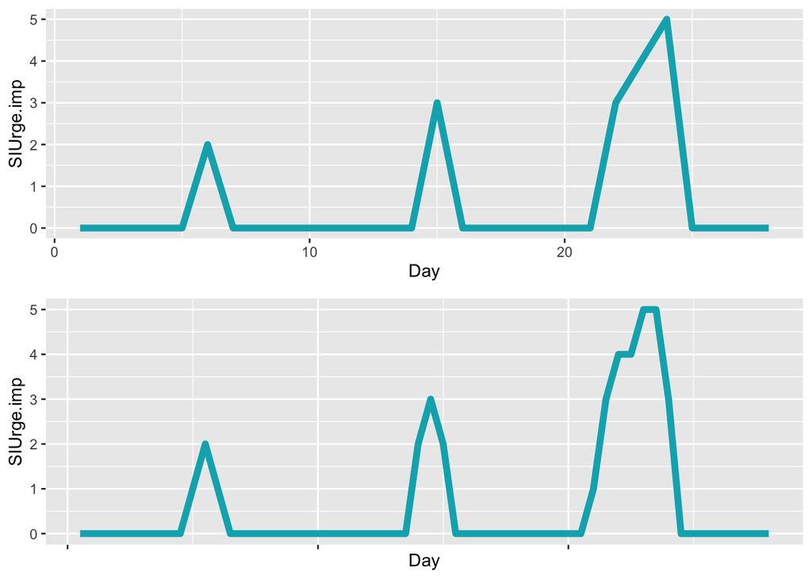

```r
a<-ggplot(data = pdat4, aes(x = Day, y = SIUrge.imp))+
  geom_line(color = "#00AFBB", size = 2)
b<-ggplot(data = pdat4.imp, aes(x = Day, y = SIUrge.imp))+
  geom_line(color = "#00AFBB", size = 2)
ggarrange(a, b + rremove("x.text"),
          ncol = 1, nrow = 2)
```

## Extracting Residuals

```r
mod1<-lm(coping_sum_3avg.imp~Day, data=pdat4.imp)
Coping_sum_3avg_resid=rstandard(mod1)

mod2<-glm(all_coping_talkfamily.imp~Day, data=pdat4.imp, family=binomial(link="logit"))
Coping_TalkFamily_resid<-as.numeric(rstandard(mod2))

mod3<-glm(all_coping_talkMH.imp~Day, data=pdat4.imp, family=binomial(link="logit"))
Coping_TalkMH_resid<-as.numeric(rstandard(mod3))

mod4<-glm(all_coping_any.imp~Day, data=pdat4.imp, family=binomial(link="logit"))
Coping_any_resid<-as.numeric(rstandard(mod4))

mod5<-glm(all_coping_dis_rel_combined.imp~Day, data=pdat4.imp, family=binomial(link="logit"))
Coping_dis_rel_resid<-as.numeric(rstandard(mod5))

mod6<-glm(all_coping_copingthought.imp~Day, data=pdat4.imp, family=binomial(link="logit"))
Coping_Thought_resid<-as.numeric(rstandard(mod6))

mod7<-glm(all_coping_thinking.imp~Day, data=pdat4.imp, family=binomial(link="logit"))
Coping_Thinking_resid<-as.numeric(rstandard(mod7))

mod8<-lm(coping_sum.imp~Day, data=pdat4.imp)
Coping_sum_resid<-as.numeric(rstandard(mod8))

mod9<-glm(all_coping_talkfriend.imp~Day, data=pdat4.imp, family=binomial(link="logit"))
Coping_TalkFriend_resid<-as.numeric(rstandard(mod9))

mod10<-lm(SIUrge.imp~Day, data=pdat4.imp, na.action=na.exclude)
SIUrge_resid<-as.numeric(rstandard(mod10))

mod11<-lm(Self_Efficacy.imp~Day, data=pdat4.imp, na.action=na.exclude)
Efficacy_resid<-as.numeric(rstandard(mod11))

pdat4<-as.data.frame(cbind(Coping_TalkFamily_resid, Coping_TalkMH_resid, Coping_dis_rel_resid, Coping_Thought_resid, Coping_Thinking_resid, Coping_TalkFriend_resid, Coping_sum_resid, Efficacy_resid, SIUrge_resid, Coping_sum_3avg_resid))
```

## Calculating Difference Scores

```r
attach(pdat4)
Coping_TalkFamily_resid=diff(Coping_TalkFamily_resid)
Coping_TalkMH_resid = diff(Coping_TalkMH_resid)
Coping_dis_rel_resid = diff(Coping_dis_rel_resid)
Coping_Thought_resid = diff(Coping_Thought_resid)
Coping_Thinking_resid = diff(Coping_Thinking_resid)
Coping_TalkFriend_resid = diff(Coping_TalkFriend_resid)
Coping_any_resid = diff(Coping_any_resid)
Coping_sum_resid = diff(Coping_sum_resid)
SIUrge_resid =  diff(SIUrge_resid)
Efficacy_resid =  diff(Efficacy_resid)
Coping_sum_3avg_resid = diff(Coping_sum_3avg_resid)

pdat4<-as.data.frame(cbind(Coping_TalkFamily_resid, Coping_TalkMH_resid, Coping_dis_rel_resid, Coping_Thought_resid, Coping_Thinking_resid, Coping_TalkFriend_resid, Coping_sum_resid, Efficacy_resid, SIUrge_resid, Coping_sum_3avg_resid))
pdat4$day<-c(1:55)
```

## Same Day models with SI Urge Predicting Changes in Coping

```r
pdat4.2<-c("Coping_sum_3avg_resid", "SIUrge_resid")
pdat4.2<-pdat4[pdat4.2]
coping_var=VAR(pdat4.2,p=1,  type="const")
causality(coping_var, cause="SIUrge_resid")$Granger
```

```
##
##  Granger causality H0: SIUrge_resid do not Granger-cause
##  Coping_sum_3avg_resid
##
## data:  VAR object coping_var
## F-Test = 0.00038425, df1 = 1, df2 = 102, p-value = 0.9844
```

```r
summary(coping_var)
```

```
##
## VAR Estimation Results:
## =========================
## Endogenous variables: Coping_sum_3avg_resid, SIUrge_resid
## Deterministic variables: const
## Sample size: 54
## Log Likelihood: -74.337
## Roots of the characteristic polynomial:
## 0.4081 0.06836
## Call:
## VAR(y = pdat4.2, p = 1, type = "const")
##
##
## Estimation results for equation Coping_sum_3avg_resid:
## ======================================================
## Coping_sum_3avg_resid = Coping_sum_3avg_resid.l1 + SIUrge_resid.l1 + const
##
##                          Estimate Std. Error t value Pr(>|t|)
## Coping_sum_3avg_resid.l1  0.06779    0.13460   0.504    0.617
## SIUrge_resid.l1          -0.00184    0.09389  -0.020    0.984
## const                    -0.01061    0.05810  -0.183    0.856
##
##
## Residual standard error: 0.4258 on 51 degrees of freedom
## Multiple R-Squared: 0.00495, Adjusted R-squared: -0.03407
## F-statistic: 0.1268 on 2 and 51 DF,  p-value: 0.8812
##
##
## Estimation results for equation SIUrge_resid:
## =============================================
## SIUrge_resid = Coping_sum_3avg_resid.l1 + SIUrge_resid.l1 + const
##
##                           Estimate Std. Error t value Pr(>|t|)
## Coping_sum_3avg_resid.l1  0.104907   0.182510   0.575   0.5680
## SIUrge_resid.l1           0.408697   0.127313   3.210   0.0023 **
## const                    -0.008395   0.078788  -0.107   0.9156
## ---
## Signif. codes:  0 '***' 0.001 '**' 0.01 '*' 0.05 '.' 0.1 ' ' 1
##
##
## Residual standard error: 0.5774 on 51 degrees of freedom
## Multiple R-Squared: 0.1753,  Adjusted R-squared: 0.1429
## F-statistic: 5.419 on 2 and 51 DF,  p-value: 0.007349
##
##
##
## Covariance matrix of residuals:
##                       Coping_sum_3avg_resid SIUrge_resid
## Coping_sum_3avg_resid               0.18133      0.01203
## SIUrge_resid                        0.01203      0.33340
##
## Correlation matrix of residuals:
##                       Coping_sum_3avg_resid SIUrge_resid
## Coping_sum_3avg_resid               1.00000      0.04891
## SIUrge_resid                        0.04891      1.00000
```

```r
pdat4.2<-c("Coping_TalkFamily_resid", "SIUrge_resid")
pdat4.2<-pdat4[pdat4.2]
coping_var=VAR(pdat4.2,p=1,  type="const")
causality(coping_var, cause="SIUrge_resid")$Granger
```

```
##
##  Granger causality H0: SIUrge_resid do not Granger-cause
##  Coping_TalkFamily_resid
##
## data:  VAR object coping_var
## F-Test = 1.0806e-08, df1 = 1, df2 = 102, p-value = 0.9999
```

```r
summary(coping_var)
```

```
##
## VAR Estimation Results:
## =========================
## Endogenous variables: Coping_TalkFamily_resid, SIUrge_resid
## Deterministic variables: const
## Sample size: 54
## Log Likelihood: -105.794
## Roots of the characteristic polynomial:
## 0.4122 0.003782
## Call:
## VAR(y = pdat4.2, p = 1, type = "const")
##
##
## Estimation results for equation Coping_TalkFamily_resid:
## ========================================================
## Coping_TalkFamily_resid = Coping_TalkFamily_resid.l1 + SIUrge_resid.l1 + const
##
##                              Estimate Std. Error t value Pr(>|t|)
## Coping_TalkFamily_resid.l1 -3.787e-03  1.400e-01  -0.027    0.979
## SIUrge_resid.l1            -1.762e-05  1.695e-01   0.000    1.000
## const                      -3.932e-02  1.050e-01  -0.375    0.709
##
##
## Residual standard error: 0.7698 on 51 degrees of freedom
## Multiple R-Squared: 1.434e-05,   Adjusted R-squared: -0.0392
## F-statistic: 0.0003658 on 2 and 51 DF,  p-value: 0.9996
##
##
## Estimation results for equation SIUrge_resid:
## =============================================
## SIUrge_resid = Coping_TalkFamily_resid.l1 + SIUrge_resid.l1 + const
##
##                             Estimate Std. Error t value Pr(>|t|)
## Coping_TalkFamily_resid.l1  0.124929   0.103908   1.202  0.23480
## SIUrge_resid.l1             0.412199   0.125808   3.276  0.00189 **
## const                      -0.006504   0.077880  -0.084  0.93377
## ---
## Signif. codes:  0 '***' 0.001 '**' 0.01 '*' 0.05 '.' 0.1 ' ' 1
##
##
## Residual standard error: 0.5712 on 51 degrees of freedom
## Multiple R-Squared: 0.1928,  Adjusted R-squared: 0.1611
## F-statistic:  6.09 on 2 and 51 DF,  p-value: 0.004248
##
##
##
## Covariance matrix of residuals:
##                         Coping_TalkFamily_resid SIUrge_resid
## Coping_TalkFamily_resid                0.592600     0.000281
## SIUrge_resid                           0.000281     0.326314
##
## Correlation matrix of residuals:
##                         Coping_TalkFamily_resid SIUrge_resid
## Coping_TalkFamily_resid               1.0000000    0.0006391
## SIUrge_resid                          0.0006391    1.0000000
```

```r
pdat4.2<-c("Coping_TalkMH_resid", "SIUrge_resid")
pdat4.2<-pdat4[pdat4.2]
coping_var=VAR(pdat4.2,p=1,  type="const")
causality(coping_var, cause="SIUrge_resid")$Granger
```

```
##
##  Granger causality H0: SIUrge_resid do not Granger-cause
##  Coping_TalkMH_resid
##
## data:  VAR object coping_var
## F-Test = 4.1646, df1 = 1, df2 = 102, p-value = 0.04386
```

```r
summary(coping_var)
```

```
##
## VAR Estimation Results:
## =========================
## Endogenous variables: Coping_TalkMH_resid, SIUrge_resid
## Deterministic variables: const
## Sample size: 54
## Log Likelihood: -109.738
## Roots of the characteristic polynomial:
## 0.3454 0.05453
## Call:
## VAR(y = pdat4.2, p = 1, type = "const")
##
##
## Estimation results for equation Coping_TalkMH_resid:
## ====================================================
## Coping_TalkMH_resid = Coping_TalkMH_resid.l1 + SIUrge_resid.l1 + const
##
##                         Estimate Std. Error t value Pr(>|t|)
## Coping_TalkMH_resid.l1 -0.018974   0.134960  -0.141   0.8887
## SIUrge_resid.l1         0.370526   0.181566   2.041   0.0465 *
## const                  -0.004304   0.111983  -0.038   0.9695
## ---
## Signif. codes:  0 '***' 0.001 '**' 0.01 '*' 0.05 '.' 0.1 ' ' 1
##
##
## Residual standard error: 0.8224 on 51 degrees of freedom
## Multiple R-Squared: 0.07549, Adjusted R-squared: 0.03924
## F-statistic: 2.082 on 2 and 51 DF,  p-value: 0.1351
##
##
## Estimation results for equation SIUrge_resid:
## =============================================
## SIUrge_resid = Coping_TalkMH_resid.l1 + SIUrge_resid.l1 + const
##
##                        Estimate Std. Error t value Pr(>|t|)
## Coping_TalkMH_resid.l1 -0.07228    0.09452  -0.765   0.4479
## SIUrge_resid.l1         0.41890    0.12716   3.294   0.0018 **
## const                  -0.01209    0.07843  -0.154   0.8781
## ---
## Signif. codes:  0 '***' 0.001 '**' 0.01 '*' 0.05 '.' 0.1 ' ' 1
##
##
## Residual standard error: 0.576 on 51 degrees of freedom
## Multiple R-Squared: 0.1793,  Adjusted R-squared: 0.1471
## F-statistic: 5.572 on 2 and 51 DF,  p-value: 0.006478
##
##
##
## Covariance matrix of residuals:
##                     Coping_TalkMH_resid SIUrge_resid
## Coping_TalkMH_resid             0.67642     -0.02496
## SIUrge_resid                   -0.02496      0.33176
##
## Correlation matrix of residuals:
##                     Coping_TalkMH_resid SIUrge_resid
## Coping_TalkMH_resid             1.00000     -0.05268
## SIUrge_resid                   -0.05268      1.00000
```

```r
pdat4.2<-c("Coping_dis_rel_resid", "SIUrge_resid")
pdat4.2<-pdat4[pdat4.2]
coping_var=VAR(pdat4.2,p=1,  type="const")
causality(coping_var, cause="SIUrge_resid")$Granger
```

```
##
##  Granger causality H0: SIUrge_resid do not Granger-cause
##  Coping_dis_rel_resid
##
## data:  VAR object coping_var
## F-Test = 3.4565e-07, df1 = 1, df2 = 102, p-value = 0.9995
```

```r
summary(coping_var)
```

```
##
## VAR Estimation Results:
## =========================
## Endogenous variables: Coping_dis_rel_resid, SIUrge_resid
## Deterministic variables: const
## Sample size: 54
## Log Likelihood: -115.418
## Roots of the characteristic polynomial:
## 0.4122 0.002746
## Call:
## VAR(y = pdat4.2, p = 1, type = "const")
##
##
## Estimation results for equation Coping_dis_rel_resid:
## =====================================================
## Coping_dis_rel_resid = Coping_dis_rel_resid.l1 + SIUrge_resid.l1 + const
##
##                           Estimate Std. Error t value Pr(>|t|)
## Coping_dis_rel_resid.l1 -0.0027459  0.1400278  -0.020    0.984
## SIUrge_resid.l1         -0.0001175  0.1998024  -0.001    1.000
## const                   -0.0352553  0.1236149  -0.285    0.777
##
##
## Residual standard error: 0.9072 on 51 degrees of freedom
## Multiple R-Squared: 7.547e-06,   Adjusted R-squared: -0.03921
## F-statistic: 0.0001924 on 2 and 51 DF,  p-value: 0.9998
##
##
## Estimation results for equation SIUrge_resid:
## =============================================
## SIUrge_resid = Coping_dis_rel_resid.l1 + SIUrge_resid.l1 + const
##
##                           Estimate Std. Error t value Pr(>|t|)
## Coping_dis_rel_resid.l1 -2.299e-05  8.941e-02   0.000  0.99980
## SIUrge_resid.l1          4.122e-01  1.276e-01   3.231  0.00216 **
## const                   -1.140e-02  7.893e-02  -0.144  0.88574
## ---
## Signif. codes:  0 '***' 0.001 '**' 0.01 '*' 0.05 '.' 0.1 ' ' 1
##
##
## Residual standard error: 0.5793 on 51 degrees of freedom
## Multiple R-Squared: 0.1699,  Adjusted R-squared: 0.1374
## F-statistic: 5.219 on 2 and 51 DF,  p-value: 0.008664
##
##
##
## Covariance matrix of residuals:
##                      Coping_dis_rel_resid SIUrge_resid
## Coping_dis_rel_resid             8.23e-01   -0.0000231
## SIUrge_resid                    -2.31e-05    0.3355628
##
## Correlation matrix of residuals:
##                      Coping_dis_rel_resid SIUrge_resid
## Coping_dis_rel_resid            1.000e+00   -4.395e-05
## SIUrge_resid                   -4.395e-05    1.000e+00
```

```r
pdat4.2<-c("Coping_Thought_resid", "SIUrge_resid")
pdat4.2<-pdat4[pdat4.2]
coping_var=VAR(pdat4.2,p=1,  type="const")
causality(coping_var, cause="SIUrge_resid")$Granger
```

```
##
##  Granger causality H0: SIUrge_resid do not Granger-cause
##  Coping_Thought_resid
##
## data:  VAR object coping_var
## F-Test = 5.1684e-07, df1 = 1, df2 = 102, p-value = 0.9994
```

```r
summary(coping_var)
```

```
##
## VAR Estimation Results:
## =========================
## Endogenous variables: Coping_Thought_resid, SIUrge_resid
## Deterministic variables: const
## Sample size: 54
## Log Likelihood: -100.755
## Roots of the characteristic polynomial:
## 0.4122 0.0002698
## Call:
## VAR(y = pdat4.2, p = 1, type = "const")
##
##
## Estimation results for equation Coping_Thought_resid:
## =====================================================
## Coping_Thought_resid = Coping_Thought_resid.l1 + SIUrge_resid.l1 + const
##
##                           Estimate Std. Error t value Pr(>|t|)
## Coping_Thought_resid.l1  0.0002698  0.1400280   0.002    0.998
## SIUrge_resid.l1         -0.0001095  0.1522905  -0.001    0.999
## const                    0.0060110  0.0941486   0.064    0.949
##
##
## Residual standard error: 0.6915 on 51 degrees of freedom
## Multiple R-Squared: 8.294e-08,   Adjusted R-squared: -0.03922
## F-statistic: 2.115e-06 on 2 and 51 DF,  p-value: 1
##
##
## Estimation results for equation SIUrge_resid:
## =============================================
## SIUrge_resid = Coping_Thought_resid.l1 + SIUrge_resid.l1 + const
##
##                           Estimate Std. Error t value Pr(>|t|)
## Coping_Thought_resid.l1 -8.115e-05  1.173e-01  -0.001  0.99945
## SIUrge_resid.l1          4.122e-01  1.276e-01   3.231  0.00216 **
## const                   -1.140e-02  7.887e-02  -0.145  0.88566
## ---
## Signif. codes:  0 '***' 0.001 '**' 0.01 '*' 0.05 '.' 0.1 ' ' 1
##
##
## Residual standard error: 0.5793 on 51 degrees of freedom
## Multiple R-Squared: 0.1699,  Adjusted R-squared: 0.1374
## F-statistic: 5.219 on 2 and 51 DF,  p-value: 0.008664
##
##
##
## Covariance matrix of residuals:
##                      Coping_Thought_resid SIUrge_resid
## Coping_Thought_resid            4.781e-01   -3.408e-05
## SIUrge_resid                   -3.408e-05    3.356e-01
##
## Correlation matrix of residuals:
##                      Coping_Thought_resid SIUrge_resid
## Coping_Thought_resid            1.000e+00   -8.508e-05
## SIUrge_resid                   -8.508e-05    1.000e+00
```

```r
pdat4.2<-c("Coping_Thinking_resid", "SIUrge_resid")
pdat4.2<-pdat4[pdat4.2]
coping_var=VAR(pdat4.2,p=1,  type="const")
causality(coping_var, cause="SIUrge_resid")$Granger
```

```
##
##  Granger causality H0: SIUrge_resid do not Granger-cause
##  Coping_Thinking_resid
##
## data:  VAR object coping_var
## F-Test = 2.5552, df1 = 1, df2 = 102, p-value = 0.113
```

```r
summary(coping_var)
```

```
##
## VAR Estimation Results:
## =========================
## Endogenous variables: Coping_Thinking_resid, SIUrge_resid
## Deterministic variables: const
## Sample size: 54
## Log Likelihood: -120.776
## Roots of the characteristic polynomial:
## 0.4561 0.1347
## Call:
## VAR(y = pdat4.2, p = 1, type = "const")
##
##
## Estimation results for equation Coping_Thinking_resid:
## ======================================================
## Coping_Thinking_resid = Coping_Thinking_resid.l1 + SIUrge_resid.l1 + const
##
##                           Estimate Std. Error t value Pr(>|t|)
## Coping_Thinking_resid.l1 -0.048506   0.139989  -0.346    0.730
## SIUrge_resid.l1           0.374177   0.234081   1.598    0.116
## const                     0.008865   0.141257   0.063    0.950
##
##
## Residual standard error: 1.037 on 51 degrees of freedom
## Multiple R-Squared: 0.04771, Adjusted R-squared: 0.01037
## F-statistic: 1.278 on 2 and 51 DF,  p-value: 0.2875
##
##
## Estimation results for equation SIUrge_resid:
## =============================================
## SIUrge_resid = Coping_Thinking_resid.l1 + SIUrge_resid.l1 + const
##
##                          Estimate Std. Error t value Pr(>|t|)
## Coping_Thinking_resid.l1  0.11619    0.07645   1.520  0.13474
## SIUrge_resid.l1           0.37000    0.12784   2.894  0.00558 **
## const                    -0.01238    0.07714  -0.161  0.87309
## ---
## Signif. codes:  0 '***' 0.001 '**' 0.01 '*' 0.05 '.' 0.1 ' ' 1
##
##
## Residual standard error: 0.5666 on 51 degrees of freedom
## Multiple R-Squared: 0.2059,  Adjusted R-squared: 0.1747
## F-statistic: 6.611 on 2 and 51 DF,  p-value: 0.0028
##
##
##
## Covariance matrix of residuals:
##                       Coping_Thinking_resid SIUrge_resid
## Coping_Thinking_resid               1.07637      0.09348
## SIUrge_resid                        0.09348      0.32102
##
## Correlation matrix of residuals:
##                       Coping_Thinking_resid SIUrge_resid
## Coping_Thinking_resid                 1.000        0.159
## SIUrge_resid                          0.159        1.000
```

```r
pdat4.2<-c("Coping_TalkFriend_resid", "SIUrge_resid")
pdat4.2<-pdat4[pdat4.2]
coping_var=VAR(pdat4.2,p=1,  type="const")
causality(coping_var, cause="SIUrge_resid")$Granger
```

```
##
##  Granger causality H0: SIUrge_resid do not Granger-cause
##  Coping_TalkFriend_resid
##
## data:  VAR object coping_var
## F-Test = 0.18073, df1 = 1, df2 = 102, p-value = 0.6716
```

```r
summary(coping_var)
```

```
##
## VAR Estimation Results:
## =========================
## Endogenous variables: Coping_TalkFriend_resid, SIUrge_resid
## Deterministic variables: const
## Sample size: 54
## Log Likelihood: -118.432
## Roots of the characteristic polynomial:
## 0.4247 0.02478
## Call:
## VAR(y = pdat4.2, p = 1, type = "const")
##
##
## Estimation results for equation Coping_TalkFriend_resid:
## ========================================================
## Coping_TalkFriend_resid = Coping_TalkFriend_resid.l1 + SIUrge_resid.l1 + const
##
##                             Estimate Std. Error t value Pr(>|t|)
## Coping_TalkFriend_resid.l1 -0.003375   0.140013  -0.024    0.981
## SIUrge_resid.l1             0.091337   0.214851   0.425    0.673
## const                      -0.009220   0.132606  -0.070    0.945
##
##
## Residual standard error: 0.9739 on 51 degrees of freedom
## Multiple R-Squared: 0.003531,    Adjusted R-squared: -0.03555
## F-statistic: 0.09036 on 2 and 51 DF,  p-value: 0.9137
##
##
## Estimation results for equation SIUrge_resid:
## =============================================
## SIUrge_resid = Coping_TalkFriend_resid.l1 + SIUrge_resid.l1 + const
##
##                            Estimate Std. Error t value Pr(>|t|)
## Coping_TalkFriend_resid.l1  0.10032    0.08208   1.222  0.22726
## SIUrge_resid.l1             0.40333    0.12596   3.202  0.00235 **
## const                      -0.01046    0.07774  -0.135  0.89348
## ---
## Signif. codes:  0 '***' 0.001 '**' 0.01 '*' 0.05 '.' 0.1 ' ' 1
##
##
## Residual standard error: 0.571 on 51 degrees of freedom
## Multiple R-Squared: 0.1935,  Adjusted R-squared: 0.1619
## F-statistic: 6.119 on 2 and 51 DF,  p-value: 0.00415
##
##
##
## Covariance matrix of residuals:
##                         Coping_TalkFriend_resid SIUrge_resid
## Coping_TalkFriend_resid                 0.94853      0.02087
## SIUrge_resid                            0.02087      0.32601
##
## Correlation matrix of residuals:
##                         Coping_TalkFriend_resid SIUrge_resid
## Coping_TalkFriend_resid                 1.00000      0.03753
## SIUrge_resid                            0.03753      1.00000
```

```r
pdat4.2<-c("Coping_sum_resid", "SIUrge_resid")
pdat4.2<-pdat4[pdat4.2]
coping_var=VAR(pdat4.2,p=1,  type="const")
causality(coping_var, cause="SIUrge_resid")$Granger
```

```
##
##  Granger causality H0: SIUrge_resid do not Granger-cause
##  Coping_sum_resid
##
## data:  VAR object coping_var
## F-Test = 0.37762, df1 = 1, df2 = 102, p-value = 0.5402
```

```r
summary(coping_var)
```

```
##
## VAR Estimation Results:
## =========================
## Endogenous variables: Coping_sum_resid, SIUrge_resid
## Deterministic variables: const
## Sample size: 54
## Log Likelihood: -85.707
## Roots of the characteristic polynomial:
## 0.4432 0.2813
## Call:
## VAR(y = pdat4.2, p = 1, type = "const")
##
##
## Estimation results for equation Coping_sum_resid:
## =================================================
## Coping_sum_resid = Coping_sum_resid.l1 + SIUrge_resid.l1 + const
##
##                     Estimate Std. Error t value Pr(>|t|)
## Coping_sum_resid.l1 0.322209   0.120231   2.680  0.00989 **
## SIUrge_resid.l1     0.072159   0.117426   0.615  0.54161
## const               0.006969   0.072163   0.097  0.92344
## ---
## Signif. codes:  0 '***' 0.001 '**' 0.01 '*' 0.05 '.' 0.1 ' ' 1
##
##
## Residual standard error: 0.5273 on 51 degrees of freedom
## Multiple R-Squared: 0.1389,  Adjusted R-squared: 0.1051
## F-statistic: 4.114 on 2 and 51 DF,  p-value: 0.02207
##
##
## Estimation results for equation SIUrge_resid:
## =============================================
## SIUrge_resid = Coping_sum_resid.l1 + SIUrge_resid.l1 + const
##
##                      Estimate Std. Error t value Pr(>|t|)
## Coping_sum_resid.l1  0.068560   0.131731   0.520  0.60500
## SIUrge_resid.l1      0.402289   0.128658   3.127  0.00292 **
## const               -0.007232   0.079066  -0.091  0.92748
## ---
## Signif. codes:  0 '***' 0.001 '**' 0.01 '*' 0.05 '.' 0.1 ' ' 1
##
##
## Residual standard error: 0.5777 on 51 degrees of freedom
## Multiple R-Squared: 0.1743,  Adjusted R-squared: 0.1419
## F-statistic: 5.383 on 2 and 51 DF,  p-value: 0.007569
##
##
##
## Covariance matrix of residuals:
##                  Coping_sum_resid SIUrge_resid
## Coping_sum_resid          0.27805      0.03029
## SIUrge_resid              0.03029      0.33379
##
## Correlation matrix of residuals:
##                  Coping_sum_resid SIUrge_resid
## Coping_sum_resid          1.00000      0.09942
## SIUrge_resid              0.09942      1.00000
```

```r
pdat4.2<-c("Efficacy_resid", "SIUrge_resid")
pdat4.2<-pdat4[pdat4.2]
coping_var=VAR(pdat4.2,p=1,  type="const")
causality(coping_var, cause="SIUrge_resid")$Granger
```

```
##
##  Granger causality H0: SIUrge_resid do not Granger-cause Efficacy_resid
##
## data:  VAR object coping_var
## F-Test = 3.2332, df1 = 1, df2 = 102, p-value = 0.07512
```

```r
summary(coping_var)
```

```
##
## VAR Estimation Results:
## =========================
## Endogenous variables: Efficacy_resid, SIUrge_resid
## Deterministic variables: const
## Sample size: 54
## Log Likelihood: -90.95
## Roots of the characteristic polynomial:
## 0.3673 0.3673
## Call:
## VAR(y = pdat4.2, p = 1, type = "const")
##
##
## Estimation results for equation Efficacy_resid:
## ===============================================
## Efficacy_resid = Efficacy_resid.l1 + SIUrge_resid.l1 + const
##
##                   Estimate Std. Error t value Pr(>|t|)
## Efficacy_resid.l1  0.24033    0.15575   1.543   0.1290
## SIUrge_resid.l1   -0.23866    0.13273  -1.798   0.0781 .
## const              0.03049    0.07969   0.383   0.7036
## ---
## Signif. codes:  0 '***' 0.001 '**' 0.01 '*' 0.05 '.' 0.1 ' ' 1
##
##
## Residual standard error: 0.5852 on 51 degrees of freedom
## Multiple R-Squared: 0.1262,  Adjusted R-squared: 0.09189
## F-statistic: 3.682 on 2 and 51 DF,  p-value: 0.0321
##
##
## Estimation results for equation SIUrge_resid:
## =============================================
## SIUrge_resid = Efficacy_resid.l1 + SIUrge_resid.l1 + const
##
##                    Estimate Std. Error t value Pr(>|t|)
## Efficacy_resid.l1  0.124509   0.153201   0.813  0.42016
## SIUrge_resid.l1    0.437586   0.130552   3.352  0.00152 **
## const             -0.009992   0.078382  -0.127  0.89906
## ---
## Signif. codes:  0 '***' 0.001 '**' 0.01 '*' 0.05 '.' 0.1 ' ' 1
##
##
## Residual standard error: 0.5756 on 51 degrees of freedom
## Multiple R-Squared: 0.1805,  Adjusted R-squared: 0.1484
## F-statistic: 5.617 on 2 and 51 DF,  p-value: 0.00624
##
##
##
## Covariance matrix of residuals:
##                Efficacy_resid SIUrge_resid
## Efficacy_resid        0.34240     -0.04286
## SIUrge_resid         -0.04286      0.33127
##
## Correlation matrix of residuals:
##                Efficacy_resid SIUrge_resid
## Efficacy_resid         1.0000      -0.1273
## SIUrge_resid          -0.1273       1.0000
```

## Plotting SI Urge and the 3 day coping diversity variable over time

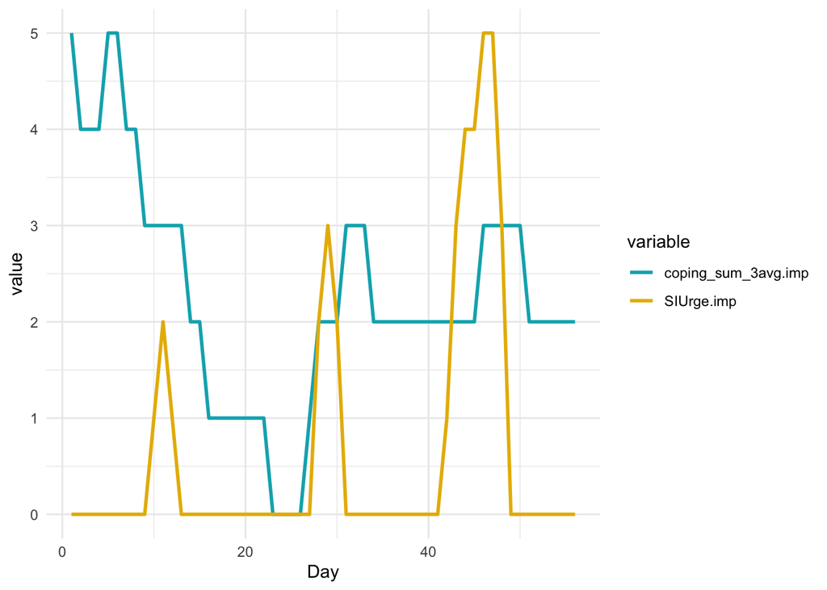

```r
df <- pdat4.imp %>%
  dplyr::select(Day, SIUrge.imp, coping_sum_3avg.imp) %>%
  tidyr::gather(key = "variable", value = "value", -Day)

ggplot(df, aes(x = Day, y = value)) +
  geom_line(aes(color = variable), size = 1) +
  scale_color_manual(values = c("#00AFBB", "#E7B800")) +
  theme_minimal()
```

# 205

## Specifying the data structure

```r
MImodel = pdat5[c(-1,-2)]
MImodel[,1] = as.factor(MImodel[,1])
MImodel[,2] = as.factor(MImodel[,2])
MImodel[,3] = as.factor(MImodel[,3])
MImodel[,4] = as.factor(MImodel[,4])
MImodel[,5] = as.factor(MImodel[,5])
MImodel[,6] = as.factor(MImodel[,6])
MImodel[,7] = as.factor(MImodel[,7])
MImodel[,10] = as.factor(MImodel[,10])
MImodel[,14] = as.factor(MImodel[,14])
MImodel[,15] = as.factor(MImodel[,15])
MImodel[,16] = as.factor(MImodel[,16])
MImodel[,17] = as.factor(MImodel[,17])
MImodel[,18] = as.factor(MImodel[,18])
MImodel[,19] = as.factor(MImodel[,19])
MImodel[,20] = as.factor(MImodel[,20])
MImodel[,22] = as.factor(MImodel[,22])
```

## Imputation

```r
m = 5
imp = mice(MImodel,m = m)
```

```
##
##  * Please inspect the loggedEvents
```

```r
k=24

qhat = matrix(NA, nrow = m,ncol = k)

u = array(NA,dim = c(k,k,m))

for (i in 1:m) {
data.impute = mice::complete(imp,action = i)}

all_coping_talkfamily.imp = as.factor(data.impute[,1])
all_coping_talkMH.imp = as.factor(data.impute[,2])
all_coping_copingthought.imp = as.factor(data.impute[,3])
all_coping_thinking.imp = as.factor(data.impute[,4])
all_coping_talkfriend.imp = as.factor(data.impute[,5])
all_coping_dis_rel_combined.imp = as.factor(data.impute[,6])
all_coping_crisisline.imp  = as.factor(data.impute[,7])
coping_sum.imp = data.impute[,8]
coping_sum_3avg.imp  = data.impute[,9]
all_coping_any.imp = as.factor(data.impute[,10])
SIUrge.imp  = data.impute[,11]
Self_Efficacy.imp = data.impute[,12]

pdat5.imp<-data.frame(all_coping_talkfamily.imp = all_coping_talkfamily.imp,
                               all_coping_talkMH.imp =all_coping_talkMH.imp,
                               all_coping_copingthought.imp = all_coping_copingthought.imp,
                               all_coping_thinking.imp = all_coping_thinking.imp,
                               all_coping_talkfriend.imp = all_coping_talkfriend.imp,
                               all_coping_dis_rel_combined.imp = all_coping_dis_rel_combined.imp,
                               all_coping_any.imp = all_coping_any.imp,
                               SIUrge.imp = SIUrge.imp,
                               Self_Efficacy.imp = Self_Efficacy.imp,
                               coping_sum_3avg.imp = coping_sum_3avg.imp,
                               coping_sum.imp = coping_sum.imp,
                               all_coping_any.imp = all_coping_any.imp)
```

## Restructuring Data file to create splines

```r
na.df <- data.frame(SIUrge.imp = NA)
vars<-c("SIUrge.imp")
pdat5.1<-pdat5.imp[vars]
pdat5.2<- do.call(rbind, apply(pdat5.1, 1, function(x) {rbind(x, na.df)}))

na.df <- data.frame(all_coping_talkfamily.imp = NA,
        all_coping_talkMH.imp = NA,
        all_coping_copingthought.imp = NA,
        all_coping_thinking.imp = NA,
        all_coping_talkfriend.imp = NA,
        all_coping_dis_rel_combined.imp = NA,
        all_coping_any.imp = NA,
        Self_Efficacy.imp = NA,
        coping_sum.imp = NA,
        coping_sum_3avg.imp = NA)

vars<-c("all_coping_talkfamily.imp",
        "all_coping_talkMH.imp",
        "all_coping_copingthought.imp",
        "all_coping_thinking.imp",
        "all_coping_talkfriend.imp",
        "all_coping_dis_rel_combined.imp",
        "all_coping_any.imp",
        "Self_Efficacy.imp",
        "coping_sum.imp",
        "coping_sum_3avg.imp")
pdat5.3<-pdat5.imp[vars]
pdat5.4 <- do.call(rbind, apply(pdat5.3, 1, function(x) {rbind(na.df, x)}))

pdat5.imp<-cbind(pdat5.4, pdat5.2)
pdat5.imp$Day<-c(1:56)
```

## Creating splines

```r
pdat5.imp<-data.frame(na.spline(pdat5.imp))
pdat5.imp<-round(pdat5.imp)
pdat5.imp$SIUrge.imp[pdat5.imp$SIUrge.imp>7]<-7
pdat5.imp$SIUrge.imp[pdat5.imp$SIUrge.imp<0]<-0
pdat5.imp$Self_Efficacy.imp[pdat5.imp$Self_Efficacy.imp>10]<-10
pdat5.imp$Self_Efficacy.imp[pdat5.imp$Self_Efficacy.imp<0]<-0
```

```r
pdat5.imp <- pdat5.imp %>%
     mutate_at(c(cols),list(~recode(., `-3`=0,`-2`=0,`-1`=0,`2`= 1,`3`=1)))

cols <- c("all_coping_talkfamily.imp",
        "all_coping_talkMH.imp",
        "all_coping_copingthought.imp",
        "all_coping_thinking.imp",
        "all_coping_talkfriend.imp",
        "all_coping_dis_rel_combined.imp",
        "all_coping_any.imp")
pdat5.imp[cols] <- lapply(pdat5.imp[cols], factor)
```

## Comparing pre vs post splines

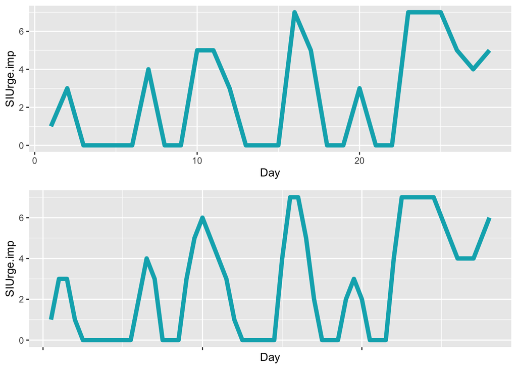

```r
a<-ggplot(data = pdat5, aes(x = Day, y = SIUrge.imp))+
  geom_line(color = "#00AFBB", size = 2)
b<-ggplot(data = pdat5.imp, aes(x = Day, y = SIUrge.imp))+
  geom_line(color = "#00AFBB", size = 2)
ggarrange(a, b + rremove("x.text"),
          ncol = 1, nrow = 2)
```

## Extracting residuals

```r
mod1<-lm(coping_sum_3avg.imp~Day, data=pdat5.imp)
Coping_sum_3avg_resid=as.numeric(rstandard(mod1))

mod2<-glm(all_coping_talkfamily.imp~Day, data=pdat5.imp, family=binomial(link="logit"))
Coping_TalkFamily_resid<-as.numeric(rstandard(mod2))

mod3<-glm(all_coping_talkMH.imp~Day, data=pdat5.imp, family=binomial(link="logit"))
Coping_TalkMH_resid<-as.numeric(rstandard(mod3))

mod4<-glm(all_coping_any.imp~Day, data=pdat5.imp, family=binomial(link="logit"))
Coping_any_resid<-as.numeric(rstandard(mod4))

mod6<-glm(all_coping_copingthought.imp~Day, data=pdat5.imp, family=binomial(link="logit"))
Coping_Thought_resid<-as.numeric(rstandard(mod6))

mod8<-lm(coping_sum.imp~Day, data=pdat5.imp, na.action=na.exclude)
Coping_sum_resid<-as.numeric(rstandard(mod8))

mod9<-glm(all_coping_talkfriend.imp~Day, data=pdat5.imp, family=binomial(link="logit"))
Coping_TalkFriend_resid<-as.numeric(rstandard(mod9))

mod10<-lm(SIUrge.imp~Day, data=pdat5.imp, na.action=na.exclude)
SIUrge_resid<-as.numeric(rstandard(mod10))

mod11<-lm(Self_Efficacy.imp~Day, data=pdat5.imp, na.action=na.exclude)
Efficacy_resid<-as.numeric(rstandard(mod11))

pdat5<-as.data.frame(cbind(Coping_TalkFamily_resid, Coping_TalkMH_resid, Coping_Thought_resid, Coping_Thinking_resid, Coping_TalkFriend_resid, Coping_sum_resid, Efficacy_resid, SIUrge_resid, Coping_any_resid, Coping_sum_3avg_resid))
```

## Person 5: Calculating Difference Scores

```r
attach(pdat5)
Coping_TalkFamily_resid=diff(Coping_TalkFamily_resid)
Coping_TalkMH_resid = diff(Coping_TalkMH_resid)
Coping_Thought_resid = diff(Coping_Thought_resid)
Coping_TalkFriend_resid = diff(Coping_TalkFriend_resid)
Coping_any_resid = diff(Coping_any_resid)
Coping_sum_resid = diff(Coping_sum_resid)
SIUrge_resid =  diff(SIUrge_resid)
Efficacy_resid =  diff(Efficacy_resid)
Coping_Thinking_resid = diff(Coping_Thinking_resid)
Coping_sum_3avg_resid = diff(Coping_sum_3avg_resid)


pdat5<-as.data.frame(cbind(Coping_TalkFamily_resid, Coping_TalkMH_resid, Coping_Thought_resid, Coping_Thinking_resid, Coping_TalkFriend_resid, Coping_sum_resid, Efficacy_resid, SIUrge_resid, Coping_sum_3avg_resid))
pdat5$day<-c(1:55)
```

## Person 5: Same Days models with SI Urge Predicting Changes in Coping

```r
pdat5.2<-c("Coping_TalkFamily_resid", "SIUrge_resid")
pdat5.2<-pdat5[pdat5.2]
coping_var=VAR(pdat5.2,p=1,  type="const")
causality(coping_var, cause="SIUrge_resid")$Granger
```

```
##
##  Granger causality H0: SIUrge_resid do not Granger-cause
##  Coping_TalkFamily_resid
##
## data:  VAR object coping_var
## F-Test = 1.7464, df1 = 1, df2 = 102, p-value = 0.1893
```

```r
summary(coping_var)
```

```
##
## VAR Estimation Results:
## =========================
## Endogenous variables: Coping_TalkFamily_resid, SIUrge_resid
## Deterministic variables: const
## Sample size: 54
## Log Likelihood: -130.043
## Roots of the characteristic polynomial:
## 0.4872 0.02983
## Call:
## VAR(y = pdat5.2, p = 1, type = "const")
##
##
## Estimation results for equation Coping_TalkFamily_resid:
## ========================================================
## Coping_TalkFamily_resid = Coping_TalkFamily_resid.l1 + SIUrge_resid.l1 + const
##
##                            Estimate Std. Error t value Pr(>|t|)
## Coping_TalkFamily_resid.l1 -0.01507    0.13806  -0.109    0.914
## SIUrge_resid.l1            -0.28841    0.21824  -1.322    0.192
## const                      -0.03044    0.15142  -0.201    0.841
##
##
## Residual standard error: 1.112 on 51 degrees of freedom
## Multiple R-Squared: 0.03311, Adjusted R-squared: -0.004804
## F-statistic: 0.8733 on 2 and 51 DF,  p-value: 0.4237
##
##
## Estimation results for equation SIUrge_resid:
## =============================================
## SIUrge_resid = Coping_TalkFamily_resid.l1 + SIUrge_resid.l1 + const
##
##                            Estimate Std. Error t value Pr(>|t|)
## Coping_TalkFamily_resid.l1 -0.02570    0.07689  -0.334 0.739526
## SIUrge_resid.l1             0.47247    0.12154   3.887 0.000294 ***
## const                      -0.01007    0.08433  -0.119 0.905390
## ---
## Signif. codes:  0 '***' 0.001 '**' 0.01 '*' 0.05 '.' 0.1 ' ' 1
##
##
## Residual standard error: 0.6195 on 51 degrees of freedom
## Multiple R-Squared: 0.233,   Adjusted R-squared: 0.2029
## F-statistic: 7.747 on 2 and 51 DF,  p-value: 0.001154
##
##
##
## Covariance matrix of residuals:
##                         Coping_TalkFamily_resid SIUrge_resid
## Coping_TalkFamily_resid                1.237286     0.009802
## SIUrge_resid                           0.009802     0.383756
##
## Correlation matrix of residuals:
##                         Coping_TalkFamily_resid SIUrge_resid
## Coping_TalkFamily_resid                 1.00000      0.01422
## SIUrge_resid                            0.01422      1.00000
```

```r
pdat5.2<-c("Coping_TalkMH_resid", "SIUrge_resid")
pdat5.2<-pdat5[pdat5.2]
coping_var=VAR(pdat5.2,p=1,  type="const")
causality(coping_var, cause="SIUrge_resid")$Granger
```

```
##
##  Granger causality H0: SIUrge_resid do not Granger-cause
##  Coping_TalkMH_resid
##
## data:  VAR object coping_var
## F-Test = 1.6117, df1 = 1, df2 = 102, p-value = 0.2071
```

```r
summary(coping_var)
```

```
##
## VAR Estimation Results:
## =========================
## Endogenous variables: Coping_TalkMH_resid, SIUrge_resid
## Deterministic variables: const
## Sample size: 54
## Log Likelihood: -125.117
## Roots of the characteristic polynomial:
## 0.4554 0.008791
## Call:
## VAR(y = pdat5.2, p = 1, type = "const")
##
##
## Estimation results for equation Coping_TalkMH_resid:
## ====================================================
## Coping_TalkMH_resid = Coping_TalkMH_resid.l1 + SIUrge_resid.l1 + const
##
##                        Estimate Std. Error t value Pr(>|t|)
## Coping_TalkMH_resid.l1 -0.01751    0.13841  -0.127    0.900
## SIUrge_resid.l1         0.25376    0.19989   1.270    0.210
## const                  -0.04501    0.13860  -0.325    0.747
##
##
## Residual standard error: 1.018 on 51 degrees of freedom
## Multiple R-Squared: 0.03064, Adjusted R-squared: -0.007376
## F-statistic: 0.806 on 2 and 51 DF,  p-value: 0.4523
##
##
## Estimation results for equation SIUrge_resid:
## =============================================
## SIUrge_resid = Coping_TalkMH_resid.l1 + SIUrge_resid.l1 + const
##
##                        Estimate Std. Error t value Pr(>|t|)
## Coping_TalkMH_resid.l1 -0.04902    0.08408  -0.583 0.562439
## SIUrge_resid.l1         0.48167    0.12142   3.967 0.000228 ***
## const                  -0.01149    0.08420  -0.136 0.891967
## ---
## Signif. codes:  0 '***' 0.001 '**' 0.01 '*' 0.05 '.' 0.1 ' ' 1
##
##
## Residual standard error: 0.6181 on 51 degrees of freedom
## Multiple R-Squared: 0.2364,  Adjusted R-squared: 0.2065
## F-statistic: 7.896 on 2 and 51 DF,  p-value: 0.00103
##
##
##
## Covariance matrix of residuals:
##                     Coping_TalkMH_resid SIUrge_resid
## Coping_TalkMH_resid            1.035353     0.002716
## SIUrge_resid                   0.002716     0.382050
##
## Correlation matrix of residuals:
##                     Coping_TalkMH_resid SIUrge_resid
## Coping_TalkMH_resid            1.000000     0.004319
## SIUrge_resid                   0.004319     1.000000
```

```r
pdat5.2<-c("Coping_Thought_resid", "SIUrge_resid")
pdat5.2<-pdat5[pdat5.2]
coping_var=VAR(pdat5.2,p=1,  type="const")
causality(coping_var, cause="SIUrge_resid")$Granger
```

```
##
##  Granger causality H0: SIUrge_resid do not Granger-cause
##  Coping_Thought_resid
##
## data:  VAR object coping_var
## F-Test = 0.66997, df1 = 1, df2 = 102, p-value = 0.415
```

```r
summary(coping_var)
```

```
##
## VAR Estimation Results:
## =========================
## Endogenous variables: Coping_Thought_resid, SIUrge_resid
## Deterministic variables: const
## Sample size: 54
## Log Likelihood: -114.664
## Roots of the characteristic polynomial:
## 0.4383 0.04988
## Call:
## VAR(y = pdat5.2, p = 1, type = "const")
##
##
## Estimation results for equation Coping_Thought_resid:
## =====================================================
## Coping_Thought_resid = Coping_Thought_resid.l1 + SIUrge_resid.l1 + const
##
##                         Estimate Std. Error t value Pr(>|t|)
## Coping_Thought_resid.l1  0.03118    0.14523   0.215    0.831
## SIUrge_resid.l1          0.15242    0.18622   0.819    0.417
## const                   -0.01978    0.12409  -0.159    0.874
##
##
## Residual standard error: 0.9116 on 51 degrees of freedom
## Multiple R-Squared: 0.01297, Adjusted R-squared: -0.02573
## F-statistic: 0.3352 on 2 and 51 DF,  p-value: 0.7168
##
##
## Estimation results for equation SIUrge_resid:
## =============================================
## SIUrge_resid = Coping_Thought_resid.l1 + SIUrge_resid.l1 + const
##
##                         Estimate Std. Error t value Pr(>|t|)
## Coping_Thought_resid.l1 -0.04994    0.09856  -0.507 0.614544
## SIUrge_resid.l1          0.45704    0.12637   3.617 0.000684 ***
## const                   -0.01036    0.08421  -0.123 0.902555
## ---
## Signif. codes:  0 '***' 0.001 '**' 0.01 '*' 0.05 '.' 0.1 ' ' 1
##
##
## Residual standard error: 0.6186 on 51 degrees of freedom
## Multiple R-Squared: 0.2352,  Adjusted R-squared: 0.2052
## F-statistic: 7.841 on 2 and 51 DF,  p-value: 0.001073
##
##
##
## Covariance matrix of residuals:
##                      Coping_Thought_resid SIUrge_resid
## Coping_Thought_resid               0.8309      -0.2222
## SIUrge_resid                      -0.2222       0.3827
##
## Correlation matrix of residuals:
##                      Coping_Thought_resid SIUrge_resid
## Coping_Thought_resid               1.0000      -0.3941
## SIUrge_resid                      -0.3941       1.0000
```

```r
pdat5.2<-c("Coping_TalkFriend_resid", "SIUrge_resid")
pdat5.2<-pdat5[pdat5.2]
coping_var=VAR(pdat5.2,p=1,  type="const")
causality(coping_var, cause="SIUrge_resid")$Granger
```

```
##
##  Granger causality H0: SIUrge_resid do not Granger-cause
##  Coping_TalkFriend_resid
##
## data:  VAR object coping_var
## F-Test = 1.7832, df1 = 1, df2 = 102, p-value = 0.1847
```

```r
summary(coping_var)
```

```
##
## VAR Estimation Results:
## =========================
## Endogenous variables: Coping_TalkFriend_resid, SIUrge_resid
## Deterministic variables: const
## Sample size: 54
## Log Likelihood: -120.322
## Roots of the characteristic polynomial:
## 0.3661 0.1093
## Call:
## VAR(y = pdat5.2, p = 1, type = "const")
##
##
## Estimation results for equation Coping_TalkFriend_resid:
## ========================================================
## Coping_TalkFriend_resid = Coping_TalkFriend_resid.l1 + SIUrge_resid.l1 + const
##
##                             Estimate Std. Error t value Pr(>|t|)
## Coping_TalkFriend_resid.l1  0.012279   0.137945   0.089    0.929
## SIUrge_resid.l1            -0.253020   0.189477  -1.335    0.188
## const                       0.005553   0.131484   0.042    0.966
##
##
## Residual standard error: 0.9662 on 51 degrees of freedom
## Multiple R-Squared: 0.03378, Adjusted R-squared: -0.004107
## F-statistic: 0.8916 on 2 and 51 DF,  p-value: 0.4163
##
##
## Estimation results for equation SIUrge_resid:
## =============================================
## SIUrge_resid = Coping_TalkFriend_resid.l1 + SIUrge_resid.l1 + const
##
##                            Estimate Std. Error t value Pr(>|t|)
## Coping_TalkFriend_resid.l1  0.13562    0.08648   1.568 0.123025
## SIUrge_resid.l1             0.46309    0.11879   3.898 0.000284 ***
## const                      -0.01014    0.08243  -0.123 0.902575
## ---
## Signif. codes:  0 '***' 0.001 '**' 0.01 '*' 0.05 '.' 0.1 ' ' 1
##
##
## Residual standard error: 0.6057 on 51 degrees of freedom
## Multiple R-Squared: 0.2667,  Adjusted R-squared: 0.2379
## F-statistic: 9.274 on 2 and 51 DF,  p-value: 0.0003671
##
##
##
## Covariance matrix of residuals:
##                         Coping_TalkFriend_resid SIUrge_resid
## Coping_TalkFriend_resid                  0.9335       0.1064
## SIUrge_resid                             0.1064       0.3669
##
## Correlation matrix of residuals:
##                         Coping_TalkFriend_resid SIUrge_resid
## Coping_TalkFriend_resid                  1.0000       0.1818
## SIUrge_resid                             0.1818       1.0000
```

```r
pdat5.2<-c("Efficacy_resid", "SIUrge_resid")
pdat5.2<-pdat5[pdat5.2]
coping_var=VAR(pdat5.2,p=1,  type="const")
causality(coping_var, cause="SIUrge_resid")$Granger
```

```
##
##  Granger causality H0: SIUrge_resid do not Granger-cause Efficacy_resid
##
## data:  VAR object coping_var
## F-Test = 5.5153, df1 = 1, df2 = 102, p-value = 0.02078
```

```r
summary(coping_var)
```

```
##
## VAR Estimation Results:
## =========================
## Endogenous variables: Efficacy_resid, SIUrge_resid
## Deterministic variables: const
## Sample size: 54
## Log Likelihood: -111.669
## Roots of the characteristic polynomial:
## 0.4797 0.1948
## Call:
## VAR(y = pdat5.2, p = 1, type = "const")
##
##
## Estimation results for equation Efficacy_resid:
## ===============================================
## Efficacy_resid = Efficacy_resid.l1 + SIUrge_resid.l1 + const
##
##                     Estimate Std. Error t value Pr(>|t|)
## Efficacy_resid.l1  0.2004322  0.1331288   1.506   0.1384
## SIUrge_resid.l1   -0.3792600  0.1614928  -2.348   0.0228 *
## const              0.0007672  0.1084304   0.007   0.9944
## ---
## Signif. codes:  0 '***' 0.001 '**' 0.01 '*' 0.05 '.' 0.1 ' ' 1
##
##
## Residual standard error: 0.7966 on 51 degrees of freedom
## Multiple R-Squared: 0.1685,  Adjusted R-squared: 0.1359
## F-statistic: 5.169 on 2 and 51 DF,  p-value: 0.009038
##
##
## Estimation results for equation SIUrge_resid:
## =============================================
## SIUrge_resid = Efficacy_resid.l1 + SIUrge_resid.l1 + const
##
##                    Estimate Std. Error t value Pr(>|t|)
## Efficacy_resid.l1 -0.004140   0.103641  -0.040 0.968290
## SIUrge_resid.l1    0.474115   0.125722   3.771 0.000424 ***
## const             -0.009237   0.084413  -0.109 0.913292
## ---
## Signif. codes:  0 '***' 0.001 '**' 0.01 '*' 0.05 '.' 0.1 ' ' 1
##
##
## Residual standard error: 0.6201 on 51 degrees of freedom
## Multiple R-Squared: 0.2314,  Adjusted R-squared: 0.2012
## F-statistic: 7.676 on 2 and 51 DF,  p-value: 0.001219
##
##
##
## Covariance matrix of residuals:
##                Efficacy_resid SIUrge_resid
## Efficacy_resid        0.63456     -0.06052
## SIUrge_resid         -0.06052      0.38458
##
## Correlation matrix of residuals:
##                Efficacy_resid SIUrge_resid
## Efficacy_resid         1.0000      -0.1225
## SIUrge_resid          -0.1225       1.0000
```

# 207

## Specifying the data structure for impuation

```r
MImodel = pdat7[c(-1,-2)]
MImodel[,1] = as.factor(MImodel[,1])
MImodel[,2] = as.factor(MImodel[,2])
MImodel[,3] = as.factor(MImodel[,3])
MImodel[,4] = as.factor(MImodel[,4])
MImodel[,5] = as.factor(MImodel[,5])
MImodel[,6] = as.factor(MImodel[,6])
MImodel[,7] = as.factor(MImodel[,7])
MImodel[,10] = as.factor(MImodel[,10])
MImodel[,14] = as.factor(MImodel[,14])
MImodel[,15] = as.factor(MImodel[,15])
MImodel[,16] = as.factor(MImodel[,16])
MImodel[,17] = as.factor(MImodel[,17])
MImodel[,18] = as.factor(MImodel[,18])
MImodel[,19] = as.factor(MImodel[,19])
MImodel[,20] = as.factor(MImodel[,20])
MImodel[,22] = as.factor(MImodel[,22])
```

## Imputation

```r
m = 5
imp = mice(MImodel,m = m)
```

```
##
##  * Please inspect the loggedEvents
```

```r
k=24

qhat = matrix(NA, nrow = m,ncol = k)

u = array(NA,dim = c(k,k,m))

for (i in 1:m) {
data.impute = mice::complete(imp,action = i)}

all_coping_talkfamily.imp = as.factor(data.impute[,1])
all_coping_talkMH.imp = as.factor(data.impute[,2])
all_coping_copingthought.imp = as.factor(data.impute[,3])
all_coping_thinking.imp = as.factor(data.impute[,4])
all_coping_talkfriend.imp = as.factor(data.impute[,5])
all_coping_dis_rel_combined.imp = as.factor(data.impute[,6])
all_coping_crisisline.imp  = as.factor(data.impute[,7])
coping_sum.imp = data.impute[,8]
coping_sum_3avg.imp  = data.impute[,9]
all_coping_any.imp = as.factor(data.impute[,10])
SIUrge.imp  = data.impute[,11]
Self_Efficacy.imp = data.impute[,12]

pdat7.imp<-data.frame(all_coping_talkfamily.imp = all_coping_talkfamily.imp,
                      all_coping_talkMH.imp = all_coping_talkMH.imp,
                      all_coping_crisisline.imp = all_coping_crisisline.imp,
                      all_coping_copingthought.imp = all_coping_copingthought.imp,
                      all_coping_thinking.imp = all_coping_thinking.imp,
                      all_coping_talkfriend.imp =  all_coping_talkfriend.imp,
                      all_coping_dis_rel_combined.imp = all_coping_dis_rel_combined.imp,
                      all_coping_any.imp = all_coping_any.imp,
                      SIUrge.imp = SIUrge.imp,
                      Self_Efficacy.imp = Self_Efficacy.imp,
                      coping_sum_3avg.imp = coping_sum_3avg.imp,
                      coping_sum.imp = coping_sum.imp)
```

## Restructuring Data file to create splines

```r
na.df <- data.frame(SIUrge.imp = NA)
vars<-c("SIUrge.imp")
pdat7.1<-pdat7.imp[vars]
pdat7.2<- do.call(rbind, apply(pdat7.1, 1, function(x) {rbind(x, na.df)}))

na.df <- data.frame(all_coping_talkfamily.imp = NA,
        all_coping_talkMH.imp = NA,
        all_coping_copingthought.imp = NA,
        all_coping_thinking.imp = NA,
        all_coping_talkfriend.imp = NA,
        all_coping_dis_rel_combined.imp = NA,
        all_coping_any.imp = NA,
        Self_Efficacy.imp = NA,
        coping_sum.imp = NA,
        coping_sum_3avg.imp = NA,
        all_coping_crisisline.imp = NA)

vars<-c("all_coping_talkfamily.imp",
        "all_coping_talkMH.imp",
        "all_coping_copingthought.imp",
        "all_coping_thinking.imp",
        "all_coping_talkfriend.imp",
        "all_coping_dis_rel_combined.imp",
        "all_coping_any.imp",
        "Self_Efficacy.imp",
        "coping_sum.imp",
        "coping_sum_3avg.imp",
        "all_coping_crisisline.imp")
pdat7.3<-pdat7.imp[vars]
pdat7.4 <- do.call(rbind, apply(pdat7.3, 1, function(x) {rbind(na.df, x)}))

pdat7.imp<-cbind(pdat7.4, pdat7.2)
pdat7.imp$Day<-c(1:56)
```

## Creating splines

```r
pdat7.imp<-data.frame(na.spline(pdat7.imp))
pdat7.imp<-round(pdat7.imp)
pdat7.imp$SIUrge.imp[pdat7.imp$SIUrge.imp>7]<-7
pdat7.imp$SIUrge.imp[pdat7.imp$SIUrge.imp<0]<-0
pdat7.imp$Self_Efficacy.imp[pdat7.imp$Self_Efficacy.imp>10]<-10
pdat7.imp$Self_Efficacy.imp[pdat7.imp$Self_Efficacy.imp<0]<-0
```

```r
pdat7.imp <- pdat7.imp %>%
     mutate_at(c(cols),list(~recode(., `-3`=0,`-2`=0,`-1`=0,`2`= 1,`3`=1)))

cols <- c("all_coping_talkfamily.imp",
        "all_coping_talkMH.imp",
        "all_coping_copingthought.imp",
        "all_coping_thinking.imp",
        "all_coping_crisisline.imp",
        "all_coping_talkfriend.imp",
        "all_coping_dis_rel_combined.imp",
        "all_coping_any.imp")
pdat7.imp[cols] <- lapply(pdat7.imp[cols], factor)
```

## Comparing pre vs post splines

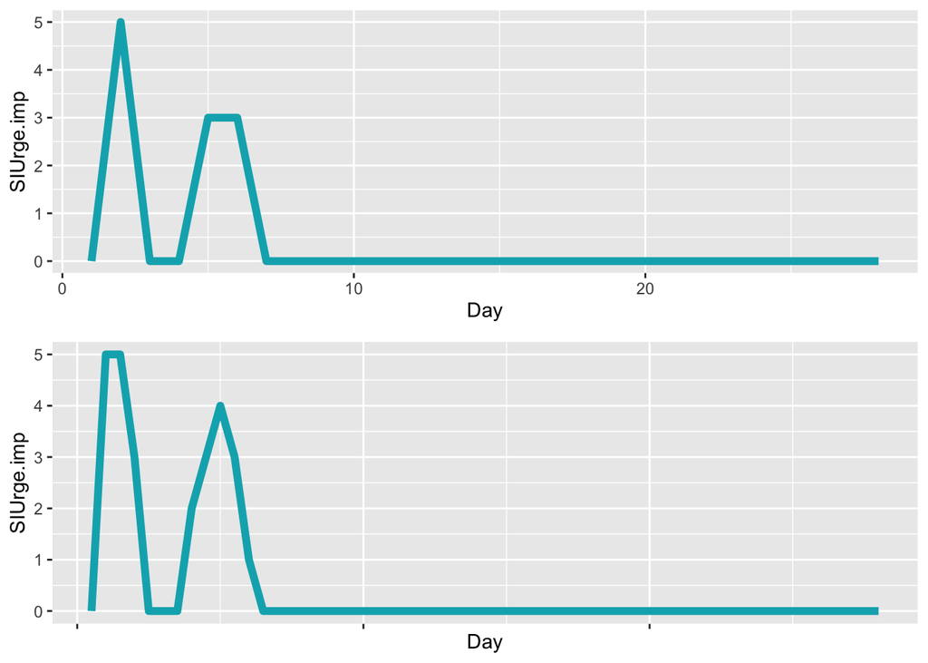

```r
a<-ggplot(data = pdat7, aes(x = Day, y = SIUrge.imp))+
  geom_line(color = "#00AFBB", size = 2)
b<-ggplot(data = pdat7.imp, aes(x = Day, y = SIUrge.imp))+
  geom_line(color = "#00AFBB", size = 2)
ggarrange(a, b + rremove("x.text"),
          ncol = 1, nrow = 2)
```

## Extracting residuals

```r
mod1<-lm(coping_sum_3avg.imp~Day, data=pdat7.imp)
Coping_sum_3avg_resid = as.numeric(rstandard(mod1))

mod2<-glm(all_coping_talkfamily.imp~Day, data=pdat7.imp, family=binomial(link="logit"))
Coping_TalkFamily_resid<-as.numeric(rstandard(mod2))

mod3<-glm(all_coping_talkMH.imp~Day, data=pdat7.imp, family=binomial(link="logit"))
Coping_TalkMH_resid<-as.numeric(rstandard(mod3))

mod4<-glm(all_coping_crisisline.imp~Day, data=pdat7.imp, family=binomial(link="logit"))
Coping_crisisline_resid<-as.numeric(rstandard(mod4))

mod5<-glm(all_coping_dis_rel_combined.imp~Day, data=pdat7.imp, family=binomial(link="logit"))
Coping_dis_rel_resid<-as.numeric(rstandard(mod5))

mod6<-glm(all_coping_copingthought.imp~Day, data=pdat7.imp, family=binomial(link="logit"))
Coping_Thought_resid<-as.numeric(rstandard(mod6))

mod7<-glm(all_coping_thinking.imp~Day, data=pdat7.imp, family=binomial(link="logit"))
Coping_Thinking_resid<-as.numeric(rstandard(mod7))

mod8<-lm(coping_sum.imp~Day, data=pdat7.imp)
Coping_sum_resid<-as.numeric(rstandard(mod8))

mod9<-glm(all_coping_talkfriend.imp~Day, data=pdat7.imp, family=binomial(link="logit"))
Coping_TalkFriend_resid<-as.numeric(rstandard(mod9))

mod10<-lm(SIUrge.imp~Day, data=pdat7.imp)
SIUrge_resid<-as.numeric(rstandard(mod10))

mod11<-lm(Self_Efficacy.imp~Day, data=pdat7.imp)
Efficacy_resid<-as.numeric(rstandard(mod11))

pdat7<-as.data.frame(cbind(Coping_TalkFamily_resid, Coping_TalkMH_resid, Coping_dis_rel_resid, Coping_Thought_resid, Coping_Thinking_resid, Coping_TalkFriend_resid, Coping_crisisline_resid, Coping_sum_resid, SIUrge_resid, Efficacy_resid, Coping_sum_3avg_resid))
```

## Calculating Difference Scores

```r
attach(pdat7)
Coping_TalkFamily_resid = diff(Coping_TalkFamily_resid)
Coping_TalkMH_resid = diff(Coping_TalkMH_resid)
Coping_dis_rel_resid = diff(Coping_dis_rel_resid)
Coping_Thought_resid = diff(Coping_Thought_resid)
Coping_Thinking_resid = diff(Coping_Thinking_resid)
Coping_TalkFriend_resid = diff(Coping_TalkFriend_resid)
Coping_crisisline_resid = diff(Coping_crisisline_resid)
Coping_sum_resid = diff(Coping_sum_resid)
SIUrge_resid =  diff(SIUrge_resid)
Efficacy_resid =  diff(Efficacy_resid)
Coping_sum_3avg_resid = diff(Coping_sum_3avg_resid)

pdat7<-as.data.frame(cbind(Coping_TalkFamily_resid, Coping_TalkMH_resid, Coping_dis_rel_resid, Coping_Thought_resid, Coping_Thinking_resid, Coping_TalkFriend_resid, Coping_sum_resid, SIUrge_resid, Efficacy_resid, Coping_sum_3avg_resid, Coping_crisisline_resid))
pdat7$day<-c(1:55)
```

## Person 7: Same Day models with SI Urge Predicting Changes in Coping

```r
pdat7.2<-c("Coping_TalkFamily_resid", "SIUrge_resid")
pdat7.2<-pdat7[pdat7.2]
coping_var=VAR(pdat7.2,p=1,  type="const")
causality(coping_var, cause="SIUrge_resid")$Granger
```

```
##
##  Granger causality H0: SIUrge_resid do not Granger-cause
##  Coping_TalkFamily_resid
##
## data:  VAR object coping_var
## F-Test = 14.922, df1 = 1, df2 = 102, p-value = 0.0001971
```

```r
summary(coping_var)
```

```
##
## VAR Estimation Results:
## =========================
## Endogenous variables: Coping_TalkFamily_resid, SIUrge_resid
## Deterministic variables: const
## Sample size: 54
## Log Likelihood: -121.926
## Roots of the characteristic polynomial:
## 0.2611 0.2611
## Call:
## VAR(y = pdat7.2, p = 1, type = "const")
##
##
## Estimation results for equation Coping_TalkFamily_resid:
## ========================================================
## Coping_TalkFamily_resid = Coping_TalkFamily_resid.l1 + SIUrge_resid.l1 + const
##
##                             Estimate Std. Error t value Pr(>|t|)
## Coping_TalkFamily_resid.l1 -0.044624   0.129921  -0.343 0.732654
## SIUrge_resid.l1            -0.569175   0.147346  -3.863 0.000318 ***
## const                      -0.009662   0.134673  -0.072 0.943085
## ---
## Signif. codes:  0 '***' 0.001 '**' 0.01 '*' 0.05 '.' 0.1 ' ' 1
##
##
## Residual standard error: 0.9887 on 51 degrees of freedom
## Multiple R-Squared: 0.2264,  Adjusted R-squared: 0.196
## F-statistic: 7.461 on 2 and 51 DF,  p-value: 0.001438
##
##
## Estimation results for equation SIUrge_resid:
## =============================================
## SIUrge_resid = Coping_TalkFamily_resid.l1 + SIUrge_resid.l1 + const
##
##                            Estimate Std. Error t value Pr(>|t|)
## Coping_TalkFamily_resid.l1  0.13946    0.07892   1.767   0.0832 .
## SIUrge_resid.l1             0.25156    0.08950   2.811   0.0070 **
## const                      -0.06232    0.08181  -0.762   0.4497
## ---
## Signif. codes:  0 '***' 0.001 '**' 0.01 '*' 0.05 '.' 0.1 ' ' 1
##
##
## Residual standard error: 0.6005 on 51 degrees of freedom
## Multiple R-Squared: 0.1669,  Adjusted R-squared: 0.1343
## F-statistic:  5.11 on 2 and 51 DF,  p-value: 0.009488
##
##
##
## Covariance matrix of residuals:
##                         Coping_TalkFamily_resid SIUrge_resid
## Coping_TalkFamily_resid                  0.9774       0.0327
## SIUrge_resid                             0.0327       0.3607
##
## Correlation matrix of residuals:
##                         Coping_TalkFamily_resid SIUrge_resid
## Coping_TalkFamily_resid                 1.00000      0.05507
## SIUrge_resid                            0.05507      1.00000
```

```r
pdat7.2<-c("Coping_TalkMH_resid", "SIUrge_resid")
pdat7.2<-pdat7[pdat7.2]
coping_var=VAR(pdat7.2,p=1,  type="const")
causality(coping_var, cause="SIUrge_resid")$Granger
```

```
##
##  Granger causality H0: SIUrge_resid do not Granger-cause
##  Coping_TalkMH_resid
##
## data:  VAR object coping_var
## F-Test = 4.4793, df1 = 1, df2 = 102, p-value = 0.03674
```

```r
summary(coping_var)
```

```
##
## VAR Estimation Results:
## =========================
## Endogenous variables: Coping_TalkMH_resid, SIUrge_resid
## Deterministic variables: const
## Sample size: 54
## Log Likelihood: -131.01
## Roots of the characteristic polynomial:
## 0.113 0.113
## Call:
## VAR(y = pdat7.2, p = 1, type = "const")
##
##
## Estimation results for equation Coping_TalkMH_resid:
## ====================================================
## Coping_TalkMH_resid = Coping_TalkMH_resid.l1 + SIUrge_resid.l1 + const
##
##                        Estimate Std. Error t value Pr(>|t|)
## Coping_TalkMH_resid.l1 -0.06194    0.14295  -0.433   0.6666
## SIUrge_resid.l1        -0.37574    0.17753  -2.116   0.0392 *
## const                  -0.02697    0.15944  -0.169   0.8663
## ---
## Signif. codes:  0 '***' 0.001 '**' 0.01 '*' 0.05 '.' 0.1 ' ' 1
##
##
## Residual standard error: 1.171 on 51 degrees of freedom
## Multiple R-Squared: 0.08074, Adjusted R-squared: 0.04469
## F-statistic:  2.24 on 2 and 51 DF,  p-value: 0.1169
##
##
## Estimation results for equation SIUrge_resid:
## =============================================
## SIUrge_resid = Coping_TalkMH_resid.l1 + SIUrge_resid.l1 + const
##
##                        Estimate Std. Error t value Pr(>|t|)
## Coping_TalkMH_resid.l1  0.07635    0.07479   1.021  0.31213
## SIUrge_resid.l1         0.25693    0.09288   2.766  0.00788 **
## const                  -0.06088    0.08342  -0.730  0.46883
## ---
## Signif. codes:  0 '***' 0.001 '**' 0.01 '*' 0.05 '.' 0.1 ' ' 1
##
##
## Residual standard error: 0.6124 on 51 degrees of freedom
## Multiple R-Squared: 0.1336,  Adjusted R-squared: 0.09967
## F-statistic: 3.934 on 2 and 51 DF,  p-value: 0.02578
##
##
##
## Covariance matrix of residuals:
##                     Coping_TalkMH_resid SIUrge_resid
## Coping_TalkMH_resid              1.3703      -0.1481
## SIUrge_resid                    -0.1481       0.3751
##
## Correlation matrix of residuals:
##                     Coping_TalkMH_resid SIUrge_resid
## Coping_TalkMH_resid              1.0000      -0.2065
## SIUrge_resid                    -0.2065       1.0000
```

```r
pdat7.2<-c("Coping_dis_rel_resid", "SIUrge_resid")
pdat7.2<-pdat7[pdat7.2]
coping_var=VAR(pdat7.2,p=1,  type="const")
causality(coping_var, cause="SIUrge_resid")$Granger
```

```
##
##  Granger causality H0: SIUrge_resid do not Granger-cause
##  Coping_dis_rel_resid
##
## data:  VAR object coping_var
## F-Test = 0.076027, df1 = 1, df2 = 102, p-value = 0.7833
```

```r
summary(coping_var)
```

```
##
## VAR Estimation Results:
## =========================
## Endogenous variables: Coping_dis_rel_resid, SIUrge_resid
## Deterministic variables: const
## Sample size: 54
## Log Likelihood: -134.452
## Roots of the characteristic polynomial:
## 0.207 0.02494
## Call:
## VAR(y = pdat7.2, p = 1, type = "const")
##
##
## Estimation results for equation Coping_dis_rel_resid:
## =====================================================
## Coping_dis_rel_resid = Coping_dis_rel_resid.l1 + SIUrge_resid.l1 + const
##
##                         Estimate Std. Error t value Pr(>|t|)
## Coping_dis_rel_resid.l1  0.01113    0.14426   0.077    0.939
## SIUrge_resid.l1         -0.05141    0.18645  -0.276    0.784
## const                   -0.03014    0.16600  -0.182    0.857
##
##
## Residual standard error: 1.218 on 51 degrees of freedom
## Multiple R-Squared: 0.00149, Adjusted R-squared: -0.03767
## F-statistic: 0.03806 on 2 and 51 DF,  p-value: 0.9627
##
##
## Estimation results for equation SIUrge_resid:
## =============================================
## SIUrge_resid = Coping_dis_rel_resid.l1 + SIUrge_resid.l1 + const
##
##                         Estimate Std. Error t value Pr(>|t|)
## Coping_dis_rel_resid.l1  0.05263    0.07292   0.722   0.4738
## SIUrge_resid.l1          0.22084    0.09425   2.343   0.0231 *
## const                   -0.06237    0.08391  -0.743   0.4607
## ---
## Signif. codes:  0 '***' 0.001 '**' 0.01 '*' 0.05 '.' 0.1 ' ' 1
##
##
## Residual standard error: 0.6155 on 51 degrees of freedom
## Multiple R-Squared: 0.1249,  Adjusted R-squared: 0.09056
## F-statistic: 3.639 on 2 and 51 DF,  p-value: 0.03332
##
##
##
## Covariance matrix of residuals:
##                      Coping_dis_rel_resid SIUrge_resid
## Coping_dis_rel_resid              1.48279      0.05343
## SIUrge_resid                      0.05343      0.37887
##
## Correlation matrix of residuals:
##                      Coping_dis_rel_resid SIUrge_resid
## Coping_dis_rel_resid              1.00000      0.07128
## SIUrge_resid                      0.07128      1.00000
```

```r
pdat7.2<-c("Coping_Thought_resid", "SIUrge_resid")
pdat7.2<-pdat7[pdat7.2]
coping_var=VAR(pdat7.2,p=1,  type="const")
causality(coping_var, cause="SIUrge_resid")$Granger
```

```
##
##  Granger causality H0: SIUrge_resid do not Granger-cause
##  Coping_Thought_resid
##
## data:  VAR object coping_var
## F-Test = 3.7054, df1 = 1, df2 = 102, p-value = 0.05702
```

```r
summary(coping_var)
```

```
##
## VAR Estimation Results:
## =========================
## Endogenous variables: Coping_Thought_resid, SIUrge_resid
## Deterministic variables: const
## Sample size: 54
## Log Likelihood: -125.271
## Roots of the characteristic polynomial:
## 0.2329 0.2329
## Call:
## VAR(y = pdat7.2, p = 1, type = "const")
##
##
## Estimation results for equation Coping_Thought_resid:
## =====================================================
## Coping_Thought_resid = Coping_Thought_resid.l1 + SIUrge_resid.l1 + const
##
##                         Estimate Std. Error t value Pr(>|t|)
## Coping_Thought_resid.l1 -0.01279    0.13532  -0.095   0.9251
## SIUrge_resid.l1         -0.30969    0.16088  -1.925   0.0598 .
## const                   -0.01706    0.14751  -0.116   0.9084
## ---
## Signif. codes:  0 '***' 0.001 '**' 0.01 '*' 0.05 '.' 0.1 ' ' 1
##
##
## Residual standard error: 1.083 on 51 degrees of freedom
## Multiple R-Squared: 0.06774, Adjusted R-squared: 0.03118
## F-statistic: 1.853 on 2 and 51 DF,  p-value: 0.1672
##
##
## Estimation results for equation SIUrge_resid:
## =============================================
## SIUrge_resid = Coping_Thought_resid.l1 + SIUrge_resid.l1 + const
##
##                         Estimate Std. Error t value Pr(>|t|)
## Coping_Thought_resid.l1  0.18531    0.07284   2.544  0.01402 *
## SIUrge_resid.l1          0.24688    0.08659   2.851  0.00627 **
## const                   -0.05492    0.07940  -0.692  0.49223
## ---
## Signif. codes:  0 '***' 0.001 '**' 0.01 '*' 0.05 '.' 0.1 ' ' 1
##
##
## Residual standard error: 0.5828 on 51 degrees of freedom
## Multiple R-Squared: 0.2155,  Adjusted R-squared: 0.1847
## F-statistic: 7.005 on 2 and 51 DF,  p-value: 0.002051
##
##
##
## Covariance matrix of residuals:
##                      Coping_Thought_resid SIUrge_resid
## Coping_Thought_resid              1.17239      0.01911
## SIUrge_resid                      0.01911      0.33963
##
## Correlation matrix of residuals:
##                      Coping_Thought_resid SIUrge_resid
## Coping_Thought_resid              1.00000      0.03028
## SIUrge_resid                      0.03028      1.00000
```

```r
pdat7.2<-c("Coping_Thinking_resid", "SIUrge_resid")
pdat7.2<-pdat7[pdat7.2]
coping_var=VAR(pdat7.2,p=1,  type="const")
causality(coping_var, cause="SIUrge_resid")$Granger
```

```
##
##  Granger causality H0: SIUrge_resid do not Granger-cause
##  Coping_Thinking_resid
##
## data:  VAR object coping_var
## F-Test = 4.4398, df1 = 1, df2 = 102, p-value = 0.03756
```

```r
summary(coping_var)
```

```
##
## VAR Estimation Results:
## =========================
## Endogenous variables: Coping_Thinking_resid, SIUrge_resid
## Deterministic variables: const
## Sample size: 54
## Log Likelihood: -122.948
## Roots of the characteristic polynomial:
## 0.2203 0.05468
## Call:
## VAR(y = pdat7.2, p = 1, type = "const")
##
##
## Estimation results for equation Coping_Thinking_resid:
## ======================================================
## Coping_Thinking_resid = Coping_Thinking_resid.l1 + SIUrge_resid.l1 + const
##
##                          Estimate Std. Error t value Pr(>|t|)
## Coping_Thinking_resid.l1 -0.07825    0.13938  -0.561    0.577
## SIUrge_resid.l1           0.33461    0.15881   2.107    0.040 *
## const                     0.00592    0.14040   0.042    0.967
## ---
## Signif. codes:  0 '***' 0.001 '**' 0.01 '*' 0.05 '.' 0.1 ' ' 1
##
##
## Residual standard error: 1.031 on 51 degrees of freedom
## Multiple R-Squared: 0.08008, Adjusted R-squared: 0.04401
## F-statistic:  2.22 on 2 and 51 DF,  p-value: 0.119
##
##
## Estimation results for equation SIUrge_resid:
## =============================================
## SIUrge_resid = Coping_Thinking_resid.l1 + SIUrge_resid.l1 + const
##
##                          Estimate Std. Error t value Pr(>|t|)
## Coping_Thinking_resid.l1 -0.02104    0.08360  -0.252   0.8023
## SIUrge_resid.l1           0.24392    0.09525   2.561   0.0134 *
## const                    -0.05969    0.08421  -0.709   0.4817
## ---
## Signif. codes:  0 '***' 0.001 '**' 0.01 '*' 0.05 '.' 0.1 ' ' 1
##
##
## Residual standard error: 0.6183 on 51 degrees of freedom
## Multiple R-Squared: 0.117,   Adjusted R-squared: 0.08241
## F-statistic:  3.38 on 2 and 51 DF,  p-value: 0.04183
##
##
##
## Covariance matrix of residuals:
##                       Coping_Thinking_resid SIUrge_resid
## Coping_Thinking_resid                1.0626       0.2029
## SIUrge_resid                         0.2029       0.3823
##
## Correlation matrix of residuals:
##                       Coping_Thinking_resid SIUrge_resid
## Coping_Thinking_resid                1.0000       0.3184
## SIUrge_resid                         0.3184       1.0000
```

```r
pdat7.2<-c("Coping_TalkFriend_resid", "SIUrge_resid")
pdat7.2<-pdat7[pdat7.2]
coping_var=VAR(pdat7.2,p=1,  type="const")
causality(coping_var, cause="SIUrge_resid")$Granger
```

```
##
##  Granger causality H0: SIUrge_resid do not Granger-cause
##  Coping_TalkFriend_resid
##
## data:  VAR object coping_var
## F-Test = 4.028, df1 = 1, df2 = 102, p-value = 0.0474
```

```r
summary(coping_var)
```

```
##
## VAR Estimation Results:
## =========================
## Endogenous variables: Coping_TalkFriend_resid, SIUrge_resid
## Deterministic variables: const
## Sample size: 54
## Log Likelihood: -119.462
## Roots of the characteristic polynomial:
## 0.1703 0.1703
## Call:
## VAR(y = pdat7.2, p = 1, type = "const")
##
##
## Estimation results for equation Coping_TalkFriend_resid:
## ========================================================
## Coping_TalkFriend_resid = Coping_TalkFriend_resid.l1 + SIUrge_resid.l1 + const
##
##                              Estimate Std. Error t value Pr(>|t|)
## Coping_TalkFriend_resid.l1 -0.0003395  0.1348057  -0.003   0.9980
## SIUrge_resid.l1             0.2779621  0.1384971   2.007   0.0501 .
## const                       0.0083263  0.1270940   0.066   0.9480
## ---
## Signif. codes:  0 '***' 0.001 '**' 0.01 '*' 0.05 '.' 0.1 ' ' 1
##
##
## Residual standard error: 0.933 on 51 degrees of freedom
## Multiple R-Squared: 0.0732,  Adjusted R-squared: 0.03685
## F-statistic: 2.014 on 2 and 51 DF,  p-value: 0.1439
##
##
## Estimation results for equation SIUrge_resid:
## =============================================
## SIUrge_resid = Coping_TalkFriend_resid.l1 + SIUrge_resid.l1 + const
##
##                            Estimate Std. Error t value Pr(>|t|)
## Coping_TalkFriend_resid.l1 -0.10458    0.08818  -1.186   0.2412
## SIUrge_resid.l1             0.23757    0.09060   2.622   0.0115 *
## const                      -0.05784    0.08314  -0.696   0.4898
## ---
## Signif. codes:  0 '***' 0.001 '**' 0.01 '*' 0.05 '.' 0.1 ' ' 1
##
##
## Residual standard error: 0.6103 on 51 degrees of freedom
## Multiple R-Squared: 0.1397,  Adjusted R-squared: 0.1059
## F-statistic:  4.14 on 2 and 51 DF,  p-value: 0.02158
##
##
##
## Covariance matrix of residuals:
##                         Coping_TalkFriend_resid SIUrge_resid
## Coping_TalkFriend_resid                 0.87044     -0.05836
## SIUrge_resid                           -0.05836      0.37247
##
## Correlation matrix of residuals:
##                         Coping_TalkFriend_resid SIUrge_resid
## Coping_TalkFriend_resid                  1.0000      -0.1025
## SIUrge_resid                            -0.1025       1.0000
```

```r
pdat7.2<-c("Coping_sum_resid", "SIUrge_resid")
pdat7.2<-pdat7[pdat7.2]
coping_var=VAR(pdat7.2,p=1,  type="const")
causality(coping_var, cause="SIUrge_resid")$Granger
```

```
##
##  Granger causality H0: SIUrge_resid do not Granger-cause
##  Coping_sum_resid
##
## data:  VAR object coping_var
## F-Test = 1.7472, df1 = 1, df2 = 102, p-value = 0.1892
```

```r
summary(coping_var)
```

```
##
## VAR Estimation Results:
## =========================
## Endogenous variables: Coping_sum_resid, SIUrge_resid
## Deterministic variables: const
## Sample size: 54
## Log Likelihood: -94.892
## Roots of the characteristic polynomial:
## 0.3543 0.3543
## Call:
## VAR(y = pdat7.2, p = 1, type = "const")
##
##
## Estimation results for equation Coping_sum_resid:
## =================================================
## Coping_sum_resid = Coping_sum_resid.l1 + SIUrge_resid.l1 + const
##
##                     Estimate Std. Error t value Pr(>|t|)
## Coping_sum_resid.l1  0.42290    0.13469   3.140  0.00281 **
## SIUrge_resid.l1     -0.11673    0.08831  -1.322  0.19213
## const               -0.01775    0.08101  -0.219  0.82746
## ---
## Signif. codes:  0 '***' 0.001 '**' 0.01 '*' 0.05 '.' 0.1 ' ' 1
##
##
## Residual standard error: 0.5946 on 51 degrees of freedom
## Multiple R-Squared: 0.1892,  Adjusted R-squared: 0.1574
## F-statistic:  5.95 on 2 and 51 DF,  p-value: 0.004757
##
##
## Estimation results for equation SIUrge_resid:
## =============================================
## SIUrge_resid = Coping_sum_resid.l1 + SIUrge_resid.l1 + const
##
##                     Estimate Std. Error t value Pr(>|t|)
## Coping_sum_resid.l1  0.19862    0.13735   1.446  0.15427
## SIUrge_resid.l1      0.24192    0.09006   2.686  0.00973 **
## const               -0.06304    0.08261  -0.763  0.44891
## ---
## Signif. codes:  0 '***' 0.001 '**' 0.01 '*' 0.05 '.' 0.1 ' ' 1
##
##
## Residual standard error: 0.6064 on 51 degrees of freedom
## Multiple R-Squared: 0.1508,  Adjusted R-squared: 0.1175
## F-statistic: 4.527 on 2 and 51 DF,  p-value: 0.0155
##
##
##
## Covariance matrix of residuals:
##                  Coping_sum_resid SIUrge_resid
## Coping_sum_resid          0.35353     -0.02912
## SIUrge_resid             -0.02912      0.36767
##
## Correlation matrix of residuals:
##                  Coping_sum_resid SIUrge_resid
## Coping_sum_resid          1.00000     -0.08078
## SIUrge_resid             -0.08078      1.00000
```

```r
pdat7.2<-c("Coping_crisisline_resid", "SIUrge_resid")
pdat7.2<-pdat7[pdat7.2]
coping_var=VAR(pdat7.2,p=1,  type="const")
causality(coping_var, cause="SIUrge_resid")$Granger
```

```
##
##  Granger causality H0: SIUrge_resid do not Granger-cause
##  Coping_crisisline_resid
##
## data:  VAR object coping_var
## F-Test = 0.66573, df1 = 1, df2 = 102, p-value = 0.4164
```

```r
summary(coping_var)
```

```
##
## VAR Estimation Results:
## =========================
## Endogenous variables: Coping_crisisline_resid, SIUrge_resid
## Deterministic variables: const
## Sample size: 54
## Log Likelihood: -118.337
## Roots of the characteristic polynomial:
## 0.2429 0.02563
## Call:
## VAR(y = pdat7.2, p = 1, type = "const")
##
##
## Estimation results for equation Coping_crisisline_resid:
## ========================================================
## Coping_crisisline_resid = Coping_crisisline_resid.l1 + SIUrge_resid.l1 + const
##
##                            Estimate Std. Error t value Pr(>|t|)
## Coping_crisisline_resid.l1 -0.05758    0.14895  -0.387    0.701
## SIUrge_resid.l1            -0.13194    0.16170  -0.816    0.418
## const                       0.01317    0.13073   0.101    0.920
##
##
## Residual standard error: 0.9597 on 51 degrees of freedom
## Multiple R-Squared: 0.01289, Adjusted R-squared: -0.02582
## F-statistic: 0.3329 on 2 and 51 DF,  p-value: 0.7184
##
##
## Estimation results for equation SIUrge_resid:
## =============================================
## SIUrge_resid = Coping_crisisline_resid.l1 + SIUrge_resid.l1 + const
##
##                            Estimate Std. Error t value Pr(>|t|)
## Coping_crisisline_resid.l1  0.07277    0.09548   0.762   0.4495
## SIUrge_resid.l1             0.27489    0.10365   2.652   0.0106 *
## const                      -0.05866    0.08380  -0.700   0.4871
## ---
## Signif. codes:  0 '***' 0.001 '**' 0.01 '*' 0.05 '.' 0.1 ' ' 1
##
##
## Residual standard error: 0.6152 on 51 degrees of freedom
## Multiple R-Squared: 0.1259,  Adjusted R-squared: 0.09162
## F-statistic: 3.673 on 2 and 51 DF,  p-value: 0.03235
##
##
##
## Covariance matrix of residuals:
##                         Coping_crisisline_resid SIUrge_resid
## Coping_crisisline_resid                   0.921      -0.2020
## SIUrge_resid                             -0.202       0.3784
##
## Correlation matrix of residuals:
##                         Coping_crisisline_resid SIUrge_resid
## Coping_crisisline_resid                  1.0000      -0.3422
## SIUrge_resid                            -0.3422       1.0000
```

```r
pdat7.2<-c("Efficacy_resid", "SIUrge_resid")
pdat7.2<-pdat7[pdat7.2]
coping_var=VAR(pdat7.2,p=1,  type="const")
causality(coping_var, cause="SIUrge_resid")$Granger
```

```
##
##  Granger causality H0: SIUrge_resid do not Granger-cause Efficacy_resid
##
## data:  VAR object coping_var
## F-Test = 8.2977, df1 = 1, df2 = 102, p-value = 0.004839
```

```r
summary(coping_var)
```

```
##
## VAR Estimation Results:
## =========================
## Endogenous variables: Efficacy_resid, SIUrge_resid
## Deterministic variables: const
## Sample size: 54
## Log Likelihood: -69.063
## Roots of the characteristic polynomial:
## 0.527 0.527
## Call:
## VAR(y = pdat7.2, p = 1, type = "const")
##
##
## Estimation results for equation Efficacy_resid:
## ===============================================
## Efficacy_resid = Efficacy_resid.l1 + SIUrge_resid.l1 + const
##
##                   Estimate Std. Error t value Pr(>|t|)
## Efficacy_resid.l1  0.54732    0.10874   5.033 6.37e-06 ***
## SIUrge_resid.l1   -0.21534    0.07476  -2.881  0.00579 **
## const              0.03590    0.06891   0.521  0.60468
## ---
## Signif. codes:  0 '***' 0.001 '**' 0.01 '*' 0.05 '.' 0.1 ' ' 1
##
##
## Residual standard error: 0.5035 on 51 degrees of freedom
## Multiple R-Squared: 0.4017,  Adjusted R-squared: 0.3782
## F-statistic: 17.12 on 2 and 51 DF,  p-value: 2.051e-06
##
##
## Estimation results for equation SIUrge_resid:
## =============================================
## SIUrge_resid = Efficacy_resid.l1 + SIUrge_resid.l1 + const
##
##                   Estimate Std. Error t value Pr(>|t|)
## Efficacy_resid.l1  0.66248    0.09617   6.889 8.15e-09 ***
## SIUrge_resid.l1    0.24681    0.06611   3.733 0.000477 ***
## const             -0.01816    0.06094  -0.298 0.766900
## ---
## Signif. codes:  0 '***' 0.001 '**' 0.01 '*' 0.05 '.' 0.1 ' ' 1
##
##
## Residual standard error: 0.4453 on 51 degrees of freedom
## Multiple R-Squared: 0.5421,  Adjusted R-squared: 0.5241
## F-statistic: 30.18 on 2 and 51 DF,  p-value: 2.241e-09
##
##
##
## Covariance matrix of residuals:
##                Efficacy_resid SIUrge_resid
## Efficacy_resid        0.25350      0.02546
## SIUrge_resid          0.02546      0.19826
##
## Correlation matrix of residuals:
##                Efficacy_resid SIUrge_resid
## Efficacy_resid         1.0000       0.1135
## SIUrge_resid           0.1135       1.0000
```

# 212

## Specifying the data structure for imputation

```r
MImodel = pdat11[c(-1,-2)]
MImodel[,1] = as.factor(MImodel[,1])
MImodel[,2] = as.factor(MImodel[,2])
MImodel[,3] = as.factor(MImodel[,3])
MImodel[,4] = as.factor(MImodel[,4])
MImodel[,5] = as.factor(MImodel[,5])
MImodel[,6] = as.factor(MImodel[,6])
MImodel[,7] = as.factor(MImodel[,7])
MImodel[,10] = as.factor(MImodel[,10])
MImodel[,14] = as.factor(MImodel[,14])
MImodel[,15] = as.factor(MImodel[,15])
MImodel[,16] = as.factor(MImodel[,16])
MImodel[,17] = as.factor(MImodel[,17])
MImodel[,18] = as.factor(MImodel[,18])
MImodel[,19] = as.factor(MImodel[,19])
MImodel[,20] = as.factor(MImodel[,20])
MImodel[,22] = as.factor(MImodel[,22])
```

## Imputation

```r
m = 5
imp = mice(MImodel,m = m)
```

```
##
##  * Please inspect the loggedEvents
```

```r
k=24

qhat = matrix(NA, nrow = m,ncol = k)

u = array(NA,dim = c(k,k,m))

for (i in 1:m) {
data.impute = mice::complete(imp,action = i)}

all_coping_talkfamily.imp = as.factor(data.impute[,1])
all_coping_talkMH.imp = as.factor(data.impute[,2])
all_coping_copingthought.imp = as.factor(data.impute[,3])
all_coping_thinking.imp = as.factor(data.impute[,4])
all_coping_talkfriend.imp = as.factor(data.impute[,5])
all_coping_dis_rel_combined.imp = as.factor(data.impute[,6])
all_coping_crisisline.imp  = as.factor(data.impute[,7])
coping_sum.imp = data.impute[,8]
coping_sum_3avg.imp  = data.impute[,9]
all_coping_any.imp = as.factor(data.impute[,10])
SIUrge.imp  = data.impute[,11]
Self_Efficacy.imp = data.impute[,12]

pdat11.imp<-data.frame(all_coping_talkfamily.imp = all_coping_talkfamily.imp,
                      all_coping_talkMH.imp = all_coping_talkMH.imp,
                      all_coping_crisisline.imp = all_coping_crisisline.imp,
                      all_coping_copingthought.imp = all_coping_copingthought.imp,
                      all_coping_thinking.imp = all_coping_thinking.imp,
                      all_coping_talkfriend.imp =  all_coping_talkfriend.imp,
                      all_coping_dis_rel_combined.imp = all_coping_dis_rel_combined.imp,
                      all_coping_any.imp = all_coping_any.imp,
                      SIUrge.imp = SIUrge.imp,
                      Self_Efficacy.imp = Self_Efficacy.imp,
                      coping_sum_3avg.imp = coping_sum_3avg.imp,
                      coping_sum.imp = coping_sum.imp)
```

## Restructuring Data file to create splines

```r
na.df <- data.frame(SIUrge.imp = NA)
vars<-c("SIUrge.imp")
pdat11.1<-pdat11.imp[vars]
pdat11.2<- do.call(rbind, apply(pdat11.1, 1, function(x) {rbind(x, na.df)}))

na.df <- data.frame(all_coping_talkfamily.imp = NA,
        all_coping_talkMH.imp = NA,
        all_coping_copingthought.imp = NA,
        all_coping_thinking.imp = NA,
        all_coping_talkfriend.imp = NA,
        all_coping_dis_rel_combined.imp = NA,
        all_coping_any.imp = NA,
        Self_Efficacy.imp = NA,
        coping_sum.imp = NA,
        coping_sum_3avg.imp = NA)

vars<-c("all_coping_talkfamily.imp",
        "all_coping_talkMH.imp",
        "all_coping_copingthought.imp",
        "all_coping_thinking.imp",
        "all_coping_talkfriend.imp",
        "all_coping_dis_rel_combined.imp",
        "all_coping_any.imp",
        "Self_Efficacy.imp",
        "coping_sum.imp",
        "coping_sum_3avg.imp")
pdat11.3<-pdat11.imp[vars]
pdat11.4 <- do.call(rbind, apply(pdat11.3, 1, function(x) {rbind(na.df, x)}))

pdat11.imp<-cbind(pdat11.4, pdat11.2)
pdat11.imp$Day<-c(1:56)
```

## Creating splines

```r
pdat11.imp<-data.frame(na.spline(pdat11.imp))
pdat11.imp<-round(pdat11.imp)
pdat11.imp$SIUrge.imp[pdat11.imp$SIUrge.imp>7]<-7
pdat11.imp$SIUrge.imp[pdat11.imp$SIUrge.imp<0]<-0
pdat11.imp$Self_Efficacy.imp[pdat11.imp$Self_Efficacy.imp>10]<-10
pdat11.imp$Self_Efficacy.imp[pdat11.imp$Self_Efficacy.imp<0]<-0
```

```r
cols <- c("all_coping_talkfamily.imp",
        "all_coping_talkMH.imp",
        "all_coping_copingthought.imp",
        "all_coping_thinking.imp",
        "all_coping_talkfriend.imp",
        "all_coping_dis_rel_combined.imp",
        "all_coping_any.imp")

pdat11.imp <- pdat11.imp %>%
     mutate_at(c(cols),list(~recode(., `-3`=0,`-2`=0,`-1`=0,`2`= 1,`3`=1)))

pdat11.imp[cols] <- lapply(pdat11.imp[cols], factor)
```

## Comparing pre vs post splines

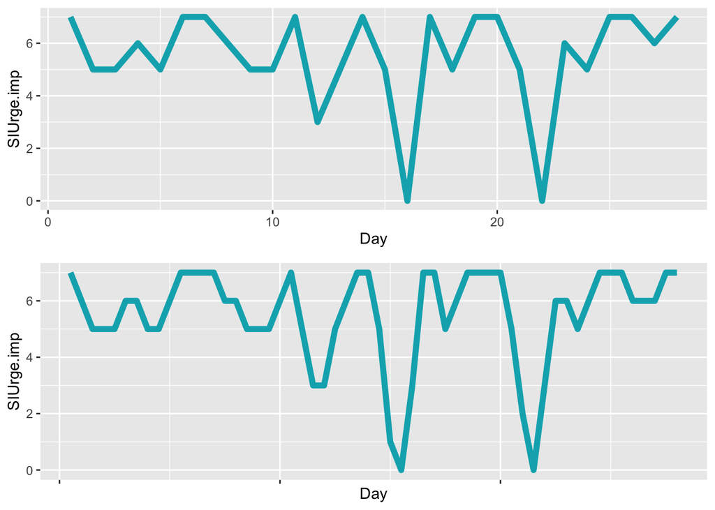

```r
a<-ggplot(data = pdat11, aes(x = Day, y = SIUrge.imp))+
  geom_line(color = "#00AFBB", size = 2)
b<-ggplot(data = pdat11.imp, aes(x = Day, y = SIUrge.imp))+
  geom_line(color = "#00AFBB", size = 2)
ggarrange(a, b + rremove("x.text"),
          ncol = 1, nrow = 2)
```

```r
mod1<-lm(coping_sum_3avg.imp~Day, data=pdat11.imp)
Coping_sum_3avg_resid = as.numeric(rstandard(mod1))

mod2<-glm(all_coping_talkfamily.imp~Day, data=pdat11.imp, family=binomial(link="logit"))
Coping_TalkFamily_resid<-as.numeric(rstandard(mod2))

mod5<-glm(all_coping_dis_rel_combined.imp~Day, data=pdat11.imp, family=binomial(link="logit"))
Coping_dis_rel_resid<-as.numeric(rstandard(mod5))

mod6<-glm(all_coping_copingthought.imp~Day, data=pdat11.imp, family=binomial(link="logit"))
Coping_Thought_resid<-as.numeric(rstandard(mod6))

mod7<-glm(all_coping_thinking.imp~Day, data=pdat11.imp, family=binomial(link="logit"))
Coping_Thinking_resid<-as.numeric(rstandard(mod7))

mod8<-lm(coping_sum.imp~Day, data=pdat11.imp)
Coping_sum_resid<-as.numeric(rstandard(mod8))

mod9<-glm(all_coping_talkfriend.imp~Day, data=pdat11.imp, family=binomial(link="logit"))
Coping_TalkFriend_resid<-as.numeric(rstandard(mod9))

mod10<-lm(SIUrge.imp~Day, data=pdat11.imp)
SIUrge_resid<-as.numeric(rstandard(mod10))

mod11<-lm(Self_Efficacy.imp~Day, data=pdat11.imp)
Efficacy_resid<-as.numeric(rstandard(mod11))

pdat11<-as.data.frame(cbind(Coping_TalkFamily_resid, Coping_dis_rel_resid, Coping_Thought_resid, Coping_Thinking_resid, Coping_TalkFriend_resid, Coping_any_resid, Coping_sum_resid, SIUrge_resid, Efficacy_resid, Coping_sum_3avg_resid))
```

## Person 11: Calculating the difference scores

```r
attach(pdat11)
Coping_TalkFamily_resid=diff(Coping_TalkFamily_resid)
Coping_dis_rel_resid = diff(Coping_dis_rel_resid)
Coping_Thought_resid = diff(Coping_Thought_resid)
Coping_Thinking_resid = diff(Coping_Thinking_resid)
Coping_TalkFriend_resid = diff(Coping_TalkFriend_resid)
Coping_sum_resid = diff(Coping_sum_resid)
SIUrge_resid =  diff(SIUrge_resid)
Efficacy_resid =  diff(Efficacy_resid)
Coping_sum_3avg_resid = diff(Coping_sum_3avg_resid)

pdat11<-as.data.frame(cbind(Coping_TalkFamily_resid, Coping_dis_rel_resid, Coping_Thought_resid, Coping_Thinking_resid, Coping_TalkFriend_resid, Coping_sum_resid, SIUrge_resid, Efficacy_resid, Coping_sum_3avg_resid))
pdat11$day<-c(1:55)
```

## Person 11: Same Day models with SI Urge Predicting Changes in Coping

```r
pdat11.2<-c("Coping_sum_3avg_resid", "SIUrge_resid")
pdat11.2<-pdat11[pdat11.2]
coping_var=VAR(pdat11.2,p=1,  type="const")
causality(coping_var, cause="SIUrge_resid")$Granger
```

```
##
##  Granger causality H0: SIUrge_resid do not Granger-cause
##  Coping_sum_3avg_resid
##
## data:  VAR object coping_var
## F-Test = 4.1814, df1 = 1, df2 = 102, p-value = 0.04344
```

```r
summary(coping_var)
```

```
##
## VAR Estimation Results:
## =========================
## Endogenous variables: Coping_sum_3avg_resid, SIUrge_resid
## Deterministic variables: const
## Sample size: 54
## Log Likelihood: -95.092
## Roots of the characteristic polynomial:
## 0.3332 0.3332
## Call:
## VAR(y = pdat11.2, p = 1, type = "const")
##
##
## Estimation results for equation Coping_sum_3avg_resid:
## ======================================================
## Coping_sum_3avg_resid = Coping_sum_3avg_resid.l1 + SIUrge_resid.l1 + const
##
##                          Estimate Std. Error t value Pr(>|t|)
## Coping_sum_3avg_resid.l1  0.14134    0.13317   1.061    0.294
## SIUrge_resid.l1          -0.15311    0.07488  -2.045    0.046 *
## const                    -0.02750    0.06310  -0.436    0.665
## ---
## Signif. codes:  0 '***' 0.001 '**' 0.01 '*' 0.05 '.' 0.1 ' ' 1
##
##
## Residual standard error: 0.4626 on 51 degrees of freedom
## Multiple R-Squared: 0.09846, Adjusted R-squared: 0.06311
## F-statistic: 2.785 on 2 and 51 DF,  p-value: 0.07114
##
##
## Estimation results for equation SIUrge_resid:
## =============================================
## SIUrge_resid = Coping_sum_3avg_resid.l1 + SIUrge_resid.l1 + const
##
##                          Estimate Std. Error t value Pr(>|t|)
## Coping_sum_3avg_resid.l1  0.37254    0.22449   1.659  0.10316
## SIUrge_resid.l1           0.38196    0.12623   3.026  0.00388 **
## const                     0.02298    0.10637   0.216  0.82985
## ---
## Signif. codes:  0 '***' 0.001 '**' 0.01 '*' 0.05 '.' 0.1 ' ' 1
##
##
## Residual standard error: 0.7799 on 51 degrees of freedom
## Multiple R-Squared: 0.1824,  Adjusted R-squared: 0.1504
## F-statistic:  5.69 on 2 and 51 DF,  p-value: 0.005878
##
##
##
## Covariance matrix of residuals:
##                       Coping_sum_3avg_resid SIUrge_resid
## Coping_sum_3avg_resid               0.21401      0.00803
## SIUrge_resid                        0.00803      0.60819
##
## Correlation matrix of residuals:
##                       Coping_sum_3avg_resid SIUrge_resid
## Coping_sum_3avg_resid               1.00000      0.02226
## SIUrge_resid                        0.02226      1.00000
```

```r
pdat11.2<-c("Coping_TalkFamily_resid", "SIUrge_resid")
pdat11.2<-pdat11[pdat11.2]
coping_var=VAR(pdat11.2,p=1,  type="const")
causality(coping_var, cause="SIUrge_resid")$Granger
```

```
##
##  Granger causality H0: SIUrge_resid do not Granger-cause
##  Coping_TalkFamily_resid
##
## data:  VAR object coping_var
## F-Test = 0.23877, df1 = 1, df2 = 102, p-value = 0.6261
```

```r
summary(coping_var)
```

```
##
## VAR Estimation Results:
## =========================
## Endogenous variables: Coping_TalkFamily_resid, SIUrge_resid
## Deterministic variables: const
## Sample size: 54
## Log Likelihood: -135.116
## Roots of the characteristic polynomial:
## 0.3727 0.04173
## Call:
## VAR(y = pdat11.2, p = 1, type = "const")
##
##
## Estimation results for equation Coping_TalkFamily_resid:
## ========================================================
## Coping_TalkFamily_resid = Coping_TalkFamily_resid.l1 + SIUrge_resid.l1 + const
##
##                            Estimate Std. Error t value Pr(>|t|)
## Coping_TalkFamily_resid.l1 -0.01128    0.14166  -0.080    0.937
## SIUrge_resid.l1            -0.07792    0.15946  -0.489    0.627
## const                      -0.01142    0.13244  -0.086    0.932
##
##
## Residual standard error: 0.9732 on 51 degrees of freedom
## Multiple R-Squared: 0.00466, Adjusted R-squared: -0.03437
## F-statistic: 0.1194 on 2 and 51 DF,  p-value: 0.8877
##
##
## Estimation results for equation SIUrge_resid:
## =============================================
## SIUrge_resid = Coping_TalkFamily_resid.l1 + SIUrge_resid.l1 + const
##
##                             Estimate Std. Error t value Pr(>|t|)
## Coping_TalkFamily_resid.l1 -0.150055   0.114635  -1.309   0.1964
## SIUrge_resid.l1             0.342208   0.129045   2.652   0.0106 *
## const                       0.009392   0.107176   0.088   0.9305
## ---
## Signif. codes:  0 '***' 0.001 '**' 0.01 '*' 0.05 '.' 0.1 ' ' 1
##
##
## Residual standard error: 0.7875 on 51 degrees of freedom
## Multiple R-Squared: 0.1663,  Adjusted R-squared: 0.1336
## F-statistic: 5.087 on 2 and 51 DF,  p-value: 0.009675
##
##
##
## Covariance matrix of residuals:
##                         Coping_TalkFamily_resid SIUrge_resid
## Coping_TalkFamily_resid                  0.9470      -0.1204
## SIUrge_resid                            -0.1204       0.6202
##
## Correlation matrix of residuals:
##                         Coping_TalkFamily_resid SIUrge_resid
## Coping_TalkFamily_resid                   1.000       -0.157
## SIUrge_resid                             -0.157        1.000
```

```r
pdat11.2<-c("Coping_dis_rel_resid", "SIUrge_resid")
pdat11.2<-pdat11[pdat11.2]
coping_var=VAR(pdat11.2,p=1,  type="const")
causality(coping_var, cause="SIUrge_resid")$Granger
```

```
##
##  Granger causality H0: SIUrge_resid do not Granger-cause
##  Coping_dis_rel_resid
##
## data:  VAR object coping_var
## F-Test = 2.2741, df1 = 1, df2 = 102, p-value = 0.1346
```

```r
summary(coping_var)
```

```
##
## VAR Estimation Results:
## =========================
## Endogenous variables: Coping_dis_rel_resid, SIUrge_resid
## Deterministic variables: const
## Sample size: 54
## Log Likelihood: -127.679
## Roots of the characteristic polynomial:
## 0.2522 0.2522
## Call:
## VAR(y = pdat11.2, p = 1, type = "const")
##
##
## Estimation results for equation Coping_dis_rel_resid:
## =====================================================
## Coping_dis_rel_resid = Coping_dis_rel_resid.l1 + SIUrge_resid.l1 + const
##
##                         Estimate Std. Error t value Pr(>|t|)
## Coping_dis_rel_resid.l1  0.01162    0.13734   0.085    0.933
## SIUrge_resid.l1          0.21463    0.14233   1.508    0.138
## const                   -0.02523    0.11961  -0.211    0.834
##
##
## Residual standard error: 0.8786 on 51 degrees of freedom
## Multiple R-Squared: 0.04269, Adjusted R-squared: 0.005153
## F-statistic: 1.137 on 2 and 51 DF,  p-value: 0.3287
##
##
## Estimation results for equation SIUrge_resid:
## =============================================
## SIUrge_resid = Coping_dis_rel_resid.l1 + SIUrge_resid.l1 + const
##
##                          Estimate Std. Error t value Pr(>|t|)
## Coping_dis_rel_resid.l1 -0.277494   0.118969  -2.332  0.02366 *
## SIUrge_resid.l1          0.350161   0.123290   2.840  0.00646 **
## const                    0.003956   0.103614   0.038  0.96970
## ---
## Signif. codes:  0 '***' 0.001 '**' 0.01 '*' 0.05 '.' 0.1 ' ' 1
##
##
## Residual standard error: 0.7611 on 51 degrees of freedom
## Multiple R-Squared: 0.2214,  Adjusted R-squared: 0.1908
## F-statistic: 7.249 on 2 and 51 DF,  p-value: 0.001695
##
##
##
## Covariance matrix of residuals:
##                      Coping_dis_rel_resid SIUrge_resid
## Coping_dis_rel_resid               0.7719      -0.1105
## SIUrge_resid                      -0.1105       0.5792
##
## Correlation matrix of residuals:
##                      Coping_dis_rel_resid SIUrge_resid
## Coping_dis_rel_resid               1.0000      -0.1653
## SIUrge_resid                      -0.1653       1.0000
```

```r
pdat11.2<-c("Coping_Thought_resid", "SIUrge_resid")
pdat11.2<-pdat11[pdat11.2]
coping_var=VAR(pdat11.2,p=1,  type="const")
causality(coping_var, cause="SIUrge_resid")$Granger
```

```
##
##  Granger causality H0: SIUrge_resid do not Granger-cause
##  Coping_Thought_resid
##
## data:  VAR object coping_var
## F-Test = 0.44697, df1 = 1, df2 = 102, p-value = 0.5053
```

```r
summary(coping_var)
```

```
##
## VAR Estimation Results:
## =========================
## Endogenous variables: Coping_Thought_resid, SIUrge_resid
## Deterministic variables: const
## Sample size: 54
## Log Likelihood: -137.709
## Roots of the characteristic polynomial:
## 0.3516 0.02228
## Call:
## VAR(y = pdat11.2, p = 1, type = "const")
##
##
## Estimation results for equation Coping_Thought_resid:
## =====================================================
## Coping_Thought_resid = Coping_Thought_resid.l1 + SIUrge_resid.l1 + const
##
##                         Estimate Std. Error t value Pr(>|t|)
## Coping_Thought_resid.l1 -0.01376    0.14051  -0.098    0.922
## SIUrge_resid.l1          0.10976    0.16418   0.669    0.507
## const                   -0.02738    0.13723  -0.199    0.843
##
##
## Residual standard error: 1.008 on 51 degrees of freedom
## Multiple R-Squared: 0.008692,    Adjusted R-squared: -0.03018
## F-statistic: 0.2236 on 2 and 51 DF,  p-value: 0.8004
##
##
## Estimation results for equation SIUrge_resid:
## =============================================
## SIUrge_resid = Coping_Thought_resid.l1 + SIUrge_resid.l1 + const
##
##                          Estimate Std. Error t value Pr(>|t|)
## Coping_Thought_resid.l1 -0.119946   0.110325  -1.087  0.28206
## SIUrge_resid.l1          0.387591   0.128912   3.007  0.00409 **
## const                    0.007813   0.107754   0.073  0.94248
## ---
## Signif. codes:  0 '***' 0.001 '**' 0.01 '*' 0.05 '.' 0.1 ' ' 1
##
##
## Residual standard error: 0.7915 on 51 degrees of freedom
## Multiple R-Squared: 0.1578,  Adjusted R-squared: 0.1248
## F-statistic: 4.778 on 2 and 51 DF,  p-value: 0.01253
##
##
##
## Covariance matrix of residuals:
##                      Coping_Thought_resid SIUrge_resid
## Coping_Thought_resid              1.01621      0.07791
## SIUrge_resid                      0.07791      0.62651
##
## Correlation matrix of residuals:
##                      Coping_Thought_resid SIUrge_resid
## Coping_Thought_resid              1.00000      0.09764
## SIUrge_resid                      0.09764      1.00000
```

```r
pdat11.2<-c("Coping_Thinking_resid", "SIUrge_resid")
pdat11.2<-pdat11[pdat11.2]
coping_var=VAR(pdat11.2,p=1,  type="const")
causality(coping_var, cause="SIUrge_resid")$Granger
```

```
##
##  Granger causality H0: SIUrge_resid do not Granger-cause
##  Coping_Thinking_resid
##
## data:  VAR object coping_var
## F-Test = 2.5672, df1 = 1, df2 = 102, p-value = 0.1122
```

```r
summary(coping_var)
```

```
##
## VAR Estimation Results:
## =========================
## Endogenous variables: Coping_Thinking_resid, SIUrge_resid
## Deterministic variables: const
## Sample size: 54
## Log Likelihood: -136.335
## Roots of the characteristic polynomial:
## 0.2903 0.0672
## Call:
## VAR(y = pdat11.2, p = 1, type = "const")
##
##
## Estimation results for equation Coping_Thinking_resid:
## ======================================================
## Coping_Thinking_resid = Coping_Thinking_resid.l1 + SIUrge_resid.l1 + const
##
##                          Estimate Std. Error t value Pr(>|t|)
## Coping_Thinking_resid.l1 -0.03557    0.13822  -0.257    0.798
## SIUrge_resid.l1           0.25737    0.16063   1.602    0.115
## const                    -0.02670    0.13376  -0.200    0.843
##
##
## Residual standard error: 0.9825 on 51 degrees of freedom
## Multiple R-Squared: 0.04793, Adjusted R-squared: 0.01059
## F-statistic: 1.284 on 2 and 51 DF,  p-value: 0.2858
##
##
## Estimation results for equation SIUrge_resid:
## =============================================
## SIUrge_resid = Coping_Thinking_resid.l1 + SIUrge_resid.l1 + const
##
##                           Estimate Std. Error t value Pr(>|t|)
## Coping_Thinking_resid.l1 -0.130103   0.111148  -1.171   0.2472
## SIUrge_resid.l1           0.393031   0.129167   3.043   0.0037 **
## const                     0.007701   0.107557   0.072   0.9432
## ---
## Signif. codes:  0 '***' 0.001 '**' 0.01 '*' 0.05 '.' 0.1 ' ' 1
##
##
## Residual standard error: 0.7901 on 51 degrees of freedom
## Multiple R-Squared: 0.1608,  Adjusted R-squared: 0.1279
## F-statistic: 4.888 on 2 and 51 DF,  p-value: 0.01143
##
##
##
## Covariance matrix of residuals:
##                       Coping_Thinking_resid SIUrge_resid
## Coping_Thinking_resid               0.96540      0.05803
## SIUrge_resid                        0.05803      0.62426
##
## Correlation matrix of residuals:
##                       Coping_Thinking_resid SIUrge_resid
## Coping_Thinking_resid               1.00000      0.07475
## SIUrge_resid                        0.07475      1.00000
```

```r
pdat11.2<-c("Coping_TalkFriend_resid", "SIUrge_resid")
pdat11.2<-pdat11[pdat11.2]
coping_var=VAR(pdat11.2,p=1,  type="const")
causality(coping_var, cause="SIUrge_resid")$Granger
```

```
##
##  Granger causality H0: SIUrge_resid do not Granger-cause
##  Coping_TalkFriend_resid
##
## data:  VAR object coping_var
## F-Test = 7.6837, df1 = 1, df2 = 102, p-value = 0.006625
```

```r
summary(coping_var)
```

```
##
## VAR Estimation Results:
## =========================
## Endogenous variables: Coping_TalkFriend_resid, SIUrge_resid
## Deterministic variables: const
## Sample size: 54
## Log Likelihood: -143.228
## Roots of the characteristic polynomial:
## 0.2667 0.2667
## Call:
## VAR(y = pdat11.2, p = 1, type = "const")
##
##
## Estimation results for equation Coping_TalkFriend_resid:
## ========================================================
## Coping_TalkFriend_resid = Coping_TalkFriend_resid.l1 + SIUrge_resid.l1 + const
##
##                            Estimate Std. Error t value Pr(>|t|)
## Coping_TalkFriend_resid.l1 -0.05086    0.13712  -0.371  0.71222
## SIUrge_resid.l1             0.51412    0.18547   2.772  0.00776 **
## const                       0.03444    0.15479   0.222  0.82482
## ---
## Signif. codes:  0 '***' 0.001 '**' 0.01 '*' 0.05 '.' 0.1 ' ' 1
##
##
## Residual standard error: 1.137 on 51 degrees of freedom
## Multiple R-Squared: 0.1309,  Adjusted R-squared: 0.09685
## F-statistic: 3.842 on 2 and 51 DF,  p-value: 0.02792
##
##
## Estimation results for equation SIUrge_resid:
## =============================================
## SIUrge_resid = Coping_TalkFriend_resid.l1 + SIUrge_resid.l1 + const
##
##                             Estimate Std. Error t value Pr(>|t|)
## Coping_TalkFriend_resid.l1 -0.178137   0.093243  -1.910  0.06170 .
## SIUrge_resid.l1             0.402400   0.126124   3.191  0.00243 **
## const                       0.009249   0.105257   0.088  0.93032
## ---
## Signif. codes:  0 '***' 0.001 '**' 0.01 '*' 0.05 '.' 0.1 ' ' 1
##
##
## Residual standard error: 0.7734 on 51 degrees of freedom
## Multiple R-Squared: 0.1958,  Adjusted R-squared: 0.1643
## F-statistic:  6.21 on 2 and 51 DF,  p-value: 0.003856
##
##
##
## Covariance matrix of residuals:
##                         Coping_TalkFriend_resid SIUrge_resid
## Coping_TalkFriend_resid                  1.2937      -0.0171
## SIUrge_resid                            -0.0171       0.5982
##
## Correlation matrix of residuals:
##                         Coping_TalkFriend_resid SIUrge_resid
## Coping_TalkFriend_resid                 1.00000     -0.01944
## SIUrge_resid                           -0.01944      1.00000
```

```r
pdat11.2<-c("Coping_sum_resid", "SIUrge_resid")
pdat11.2<-pdat11[pdat11.2]
coping_var=VAR(pdat11.2,p=1,  type="const")
causality(coping_var, cause="SIUrge_resid")$Granger
```

```
##
##  Granger causality H0: SIUrge_resid do not Granger-cause
##  Coping_sum_resid
##
## data:  VAR object coping_var
## F-Test = 4.7939, df1 = 1, df2 = 102, p-value = 0.03084
```

```r
summary(coping_var)
```

```
##
## VAR Estimation Results:
## =========================
## Endogenous variables: Coping_sum_resid, SIUrge_resid
## Deterministic variables: const
## Sample size: 54
## Log Likelihood: -106.746
## Roots of the characteristic polynomial:
## 0.4221 0.4221
## Call:
## VAR(y = pdat11.2, p = 1, type = "const")
##
##
## Estimation results for equation Coping_sum_resid:
## =================================================
## Coping_sum_resid = Coping_sum_resid.l1 + SIUrge_resid.l1 + const
##
##                     Estimate Std. Error t value Pr(>|t|)
## Coping_sum_resid.l1  0.34133    0.09954   3.429  0.00121 **
## SIUrge_resid.l1      0.20573    0.09396   2.190  0.03316 *
## const               -0.03330    0.07922  -0.420  0.67603
## ---
## Signif. codes:  0 '***' 0.001 '**' 0.01 '*' 0.05 '.' 0.1 ' ' 1
##
##
## Residual standard error: 0.5812 on 51 degrees of freedom
## Multiple R-Squared: 0.2408,  Adjusted R-squared: 0.211
## F-statistic: 8.088 on 2 and 51 DF,  p-value: 0.0008896
##
##
## Estimation results for equation SIUrge_resid:
## =============================================
## SIUrge_resid = Coping_sum_resid.l1 + SIUrge_resid.l1 + const
##
##                     Estimate Std. Error t value Pr(>|t|)
## Coping_sum_resid.l1 -0.26260    0.13209  -1.988  0.05219 .
## SIUrge_resid.l1      0.36375    0.12469   2.917  0.00524 **
## const                0.02281    0.10513   0.217  0.82913
## ---
## Signif. codes:  0 '***' 0.001 '**' 0.01 '*' 0.05 '.' 0.1 ' ' 1
##
##
## Residual standard error: 0.7713 on 51 degrees of freedom
## Multiple R-Squared: 0.2003,  Adjusted R-squared: 0.1689
## F-statistic: 6.386 on 2 and 51 DF,  p-value: 0.00335
##
##
##
## Covariance matrix of residuals:
##                  Coping_sum_resid SIUrge_resid
## Coping_sum_resid          0.33784      0.02608
## SIUrge_resid              0.02608      0.59493
##
## Correlation matrix of residuals:
##                  Coping_sum_resid SIUrge_resid
## Coping_sum_resid          1.00000      0.05817
## SIUrge_resid              0.05817      1.00000
```

```r
pdat11.2<-c("Efficacy_resid", "SIUrge_resid")
pdat11.2<-pdat11[pdat11.2]
coping_var=VAR(pdat11.2,p=1,  type="const")
causality(coping_var, cause="SIUrge_resid")$Granger
```

```
##
##  Granger causality H0: SIUrge_resid do not Granger-cause Efficacy_resid
##
## data:  VAR object coping_var
## F-Test = 5.0489, df1 = 1, df2 = 102, p-value = 0.0268
```

```r
summary(coping_var)
```

```
##
## VAR Estimation Results:
## =========================
## Endogenous variables: Efficacy_resid, SIUrge_resid
## Deterministic variables: const
## Sample size: 54
## Log Likelihood: -101.723
## Roots of the characteristic polynomial:
## 0.4845 0.4845
## Call:
## VAR(y = pdat11.2, p = 1, type = "const")
##
##
## Estimation results for equation Efficacy_resid:
## ===============================================
## Efficacy_resid = Efficacy_resid.l1 + SIUrge_resid.l1 + const
##
##                   Estimate Std. Error t value Pr(>|t|)
## Efficacy_resid.l1  0.56586    0.11096   5.099 5.06e-06 ***
## SIUrge_resid.l1   -0.20677    0.09202  -2.247    0.029 *
## const              0.03473    0.07422   0.468    0.642
## ---
## Signif. codes:  0 '***' 0.001 '**' 0.01 '*' 0.05 '.' 0.1 ' ' 1
##
##
## Residual standard error: 0.5454 on 51 degrees of freedom
## Multiple R-Squared: 0.3434,  Adjusted R-squared: 0.3176
## F-statistic: 13.34 on 2 and 51 DF,  p-value: 2.195e-05
##
##
## Estimation results for equation SIUrge_resid:
## =============================================
## SIUrge_resid = Efficacy_resid.l1 + SIUrge_resid.l1 + const
##
##                   Estimate Std. Error t value Pr(>|t|)
## Efficacy_resid.l1 0.350932   0.155299   2.260   0.0281 *
## SIUrge_resid.l1   0.286566   0.128786   2.225   0.0305 *
## const             0.009873   0.103879   0.095   0.9247
## ---
## Signif. codes:  0 '***' 0.001 '**' 0.01 '*' 0.05 '.' 0.1 ' ' 1
##
##
## Residual standard error: 0.7633 on 51 degrees of freedom
## Multiple R-Squared: 0.2167,  Adjusted R-squared: 0.186
## F-statistic: 7.056 on 2 and 51 DF,  p-value: 0.001972
##
##
##
## Covariance matrix of residuals:
##                Efficacy_resid SIUrge_resid
## Efficacy_resid        0.29749      0.08388
## SIUrge_resid          0.08388      0.58269
##
## Correlation matrix of residuals:
##                Efficacy_resid SIUrge_resid
## Efficacy_resid         1.0000       0.2015
## SIUrge_resid           0.2015       1.0000
```

# 214

## Specifying data structure for imputation

```r
MImodel = pdat13[c(-1,-2)]
MImodel[,1] = as.factor(MImodel[,1])
MImodel[,2] = as.factor(MImodel[,2])
MImodel[,3] = as.factor(MImodel[,3])
MImodel[,4] = as.factor(MImodel[,4])
MImodel[,5] = as.factor(MImodel[,5])
MImodel[,6] = as.factor(MImodel[,6])
MImodel[,7] = as.factor(MImodel[,7])
MImodel[,10] = as.factor(MImodel[,10])
MImodel[,14] = as.factor(MImodel[,14])
MImodel[,15] = as.factor(MImodel[,15])
MImodel[,16] = as.factor(MImodel[,16])
MImodel[,17] = as.factor(MImodel[,17])
MImodel[,18] = as.factor(MImodel[,18])
MImodel[,19] = as.factor(MImodel[,19])
MImodel[,20] = as.factor(MImodel[,20])
MImodel[,22] = as.factor(MImodel[,22])
```

## Person 13: Imputation

```r
m = 5
imp = mice(MImodel,m = m)
```

```
##
##  * Please inspect the loggedEvents
```

```r
k=24

qhat = matrix(NA, nrow = m,ncol = k)

u = array(NA,dim = c(k,k,m))

for (i in 1:m) {
data.impute = mice::complete(imp,action = i)}

all_coping_talkfamily.imp = as.factor(data.impute[,1])
all_coping_talkMH.imp = as.factor(data.impute[,2])
all_coping_copingthought.imp = as.factor(data.impute[,3])
all_coping_thinking.imp = as.factor(data.impute[,4])
all_coping_talkfriend.imp = as.factor(data.impute[,5])
all_coping_dis_rel_combined.imp = as.factor(data.impute[,6])
all_coping_crisisline.imp  = as.factor(data.impute[,7])
coping_sum.imp = data.impute[,8]
coping_sum_3avg.imp  = data.impute[,9]
all_coping_any.imp = as.factor(data.impute[,10])
SIUrge.imp  = data.impute[,11]
Self_Efficacy.imp = data.impute[,12]

pdat13.imp<-data.frame(all_coping_talkfamily.imp = all_coping_talkfamily.imp,
                      all_coping_talkMH.imp = all_coping_talkMH.imp,
                      all_coping_crisisline.imp = all_coping_crisisline.imp,
                      all_coping_copingthought.imp = all_coping_copingthought.imp,
                      all_coping_thinking.imp = all_coping_thinking.imp,
                      all_coping_talkfriend.imp =  all_coping_talkfriend.imp,
                      all_coping_dis_rel_combined.imp = all_coping_dis_rel_combined.imp,
                      all_coping_any.imp = all_coping_any.imp,
                      SIUrge.imp = SIUrge.imp,
                      Self_Efficacy.imp = Self_Efficacy.imp,
                      coping_sum_3avg.imp = coping_sum_3avg.imp,
                      coping_sum.imp = coping_sum.imp)
```

## Restructuring Data file to create splines

```r
na.df <- data.frame(SIUrge.imp = NA)
vars<-c("SIUrge.imp")
pdat13.1<-pdat13.imp[vars]
pdat13.2<- do.call(rbind, apply(pdat13.1, 1, function(x) {rbind(x, na.df)}))

na.df <- data.frame(all_coping_talkfamily.imp = NA,
        all_coping_talkMH.imp = NA,
        all_coping_copingthought.imp = NA,
        all_coping_thinking.imp = NA,
        all_coping_talkfriend.imp = NA,
        all_coping_dis_rel_combined.imp = NA,
        all_coping_any.imp = NA,
        Self_Efficacy.imp = NA,
        coping_sum.imp = NA,
        coping_sum_3avg.imp = NA)

vars<-c("all_coping_talkfamily.imp",
        "all_coping_talkMH.imp",
        "all_coping_copingthought.imp",
        "all_coping_thinking.imp",
        "all_coping_talkfriend.imp",
        "all_coping_dis_rel_combined.imp",
        "all_coping_any.imp",
        "Self_Efficacy.imp",
        "coping_sum.imp",
        "coping_sum_3avg.imp")
pdat13.3<-pdat13.imp[vars]
pdat13.4 <- do.call(rbind, apply(pdat13.3, 1, function(x) {rbind(na.df, x)}))

pdat13.imp<-cbind(pdat13.4, pdat13.2)
pdat13.imp$Day<-c(1:56)
```

## Creating splines

```r
pdat13.imp<-data.frame(na.spline(pdat13.imp))
pdat13.imp<-round(pdat13.imp)
pdat13.imp$SIUrge.imp[pdat13.imp$SIUrge.imp>7]<-7
pdat13.imp$SIUrge.imp[pdat13.imp$SIUrge.imp<0]<-0
pdat13.imp$Self_Efficacy.imp[pdat13.imp$Self_Efficacy.imp>10]<-10
pdat13.imp$Self_Efficacy.imp[pdat13.imp$Self_Efficacy.imp<0]<-0
```

```r
pdat13.imp <- pdat13.imp %>%
     mutate_at(c(cols),list(~recode(., `-3`=0,`-2`=0,`-1`=0,`2`= 1,`3`=1)))

cols <- c("all_coping_talkfamily.imp",
        "all_coping_talkMH.imp",
        "all_coping_copingthought.imp",
        "all_coping_thinking.imp",
        "all_coping_talkfriend.imp",
        "all_coping_dis_rel_combined.imp",
        "all_coping_any.imp")
pdat13.imp[cols] <- lapply(pdat13.imp[cols], factor)
```

## Comparing pre vs post splines

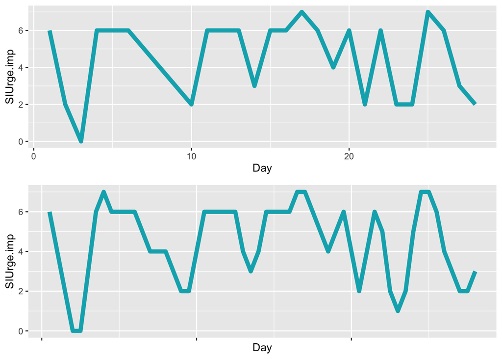

```r
a<-ggplot(data = pdat13, aes(x = Day, y = SIUrge.imp))+
  geom_line(color = "#00AFBB", size = 2)
b<-ggplot(data = pdat13.imp, aes(x = Day, y = SIUrge.imp))+
  geom_line(color = "#00AFBB", size = 2)
ggarrange(a, b + rremove("x.text"),
          ncol = 1, nrow = 2)
```

## Extracting residuals

```r
mod1<-lm(coping_sum_3avg.imp~Day, data=pdat13.imp)
Coping_sum_3avg_resid = as.numeric(rstandard(mod1))

mod2<-glm(all_coping_talkfamily.imp~Day, data=pdat13.imp, family=binomial(link="logit"))
Coping_TalkFamily_resid<-as.numeric(rstandard(mod2))

mod3<-glm(all_coping_talkMH.imp~Day, data=pdat13.imp, family=binomial(link="logit"))
Coping_TalkMH_resid<-as.numeric(rstandard(mod3))

mod5<-glm(all_coping_dis_rel_combined.imp~Day, data=pdat13.imp, family=binomial(link="logit"))
Coping_dis_rel_resid<-as.numeric(rstandard(mod5))

mod6<-glm(all_coping_copingthought.imp~Day, data=pdat13.imp, family=binomial(link="logit"))
Coping_Thought_resid<-as.numeric(rstandard(mod6))

mod7<-glm(all_coping_thinking.imp~Day, data=pdat13.imp, family=binomial(link="logit"))
Coping_Thinking_resid<-as.numeric(rstandard(mod7))

mod8<-lm(coping_sum.imp~Day, data=pdat13.imp)
Coping_sum_resid<-as.numeric(rstandard(mod8))

mod9<-glm(all_coping_talkfriend.imp~Day, data=pdat13.imp, family=binomial(link="logit"))
Coping_TalkFriend_resid<-as.numeric(rstandard(mod9))

mod10<-lm(SIUrge.imp~Day, data=pdat13.imp)
SIUrge_resid<-as.numeric(rstandard(mod10))

mod11<-lm(Self_Efficacy.imp~Day, data=pdat13.imp)
Efficacy_resid<-as.numeric(rstandard(mod11))

pdat13<-as.data.frame(cbind(Coping_TalkFamily_resid, Coping_TalkMH_resid, Coping_dis_rel_resid, Coping_Thought_resid, Coping_Thinking_resid, Coping_TalkFriend_resid, Coping_sum_resid, SIUrge_resid, Efficacy_resid, Coping_sum_3avg_resid))
```

## Person 13: Calculating Difference Scores

```r
attach(pdat13)
Coping_TalkFamily_resid = diff(Coping_TalkFamily_resid)
Coping_TalkMH_resid = diff(Coping_TalkMH_resid)
Coping_dis_rel_resid = diff(Coping_dis_rel_resid)
Coping_Thought_resid = diff(Coping_Thought_resid)
Coping_Thinking_resid = diff(Coping_Thinking_resid)
Coping_TalkFriend_resid = diff(Coping_TalkFriend_resid)
Coping_sum_resid = diff(Coping_sum_resid)
SIUrge_resid =  diff(SIUrge_resid)
Efficacy_resid =  diff(Efficacy_resid)
Coping_sum_3avg_resid = diff(Coping_sum_3avg_resid)

pdat13<-as.data.frame(cbind(Coping_TalkFamily_resid, Coping_TalkMH_resid, Coping_dis_rel_resid, Coping_Thought_resid, Coping_Thinking_resid, Coping_TalkFriend_resid, Coping_sum_resid, SIUrge_resid, Efficacy_resid, Coping_sum_3avg_resid))

pdat13$day<-c(1:55)
```

## Person 13: Same Day Models with SI Urge Predicting Changes in Coping

```r
pdat13.2<-c("Coping_sum_3avg_resid", "SIUrge_resid")
pdat13.2<-pdat13[pdat13.2]
coping_var=VAR(pdat13.2,p=1,  type="const")
causality(coping_var, cause="SIUrge_resid")$Granger
```

```
##
##  Granger causality H0: SIUrge_resid do not Granger-cause
##  Coping_sum_3avg_resid
##
## data:  VAR object coping_var
## F-Test = 0.30912, df1 = 1, df2 = 102, p-value = 0.5794
```

```r
summary(coping_var)
```

```
##
## VAR Estimation Results:
## =========================
## Endogenous variables: Coping_sum_3avg_resid, SIUrge_resid
## Deterministic variables: const
## Sample size: 54
## Log Likelihood: -110.207
## Roots of the characteristic polynomial:
## 0.323 0.323
## Call:
## VAR(y = pdat13.2, p = 1, type = "const")
##
##
## Estimation results for equation Coping_sum_3avg_resid:
## ======================================================
## Coping_sum_3avg_resid = Coping_sum_3avg_resid.l1 + SIUrge_resid.l1 + const
##
##                          Estimate Std. Error t value Pr(>|t|)
## Coping_sum_3avg_resid.l1  0.20153    0.14362   1.403    0.167
## SIUrge_resid.l1          -0.07443    0.13387  -0.556    0.581
## const                     0.02495    0.10102   0.247    0.806
##
##
## Residual standard error: 0.7413 on 51 degrees of freedom
## Multiple R-Squared: 0.03907, Adjusted R-squared: 0.00139
## F-statistic: 1.037 on 2 and 51 DF,  p-value: 0.3619
##
##
## Estimation results for equation SIUrge_resid:
## =============================================
## SIUrge_resid = Coping_sum_3avg_resid.l1 + SIUrge_resid.l1 + const
##
##                          Estimate Std. Error t value Pr(>|t|)
## Coping_sum_3avg_resid.l1 0.287698   0.127112   2.263  0.02790 *
## SIUrge_resid.l1          0.411310   0.118481   3.472  0.00106 **
## const                    0.005973   0.089408   0.067  0.94699
## ---
## Signif. codes:  0 '***' 0.001 '**' 0.01 '*' 0.05 '.' 0.1 ' ' 1
##
##
## Residual standard error: 0.6561 on 51 degrees of freedom
## Multiple R-Squared: 0.2858,  Adjusted R-squared: 0.2578
## F-statistic: 10.21 on 2 and 51 DF,  p-value: 0.0001871
##
##
##
## Covariance matrix of residuals:
##                       Coping_sum_3avg_resid SIUrge_resid
## Coping_sum_3avg_resid               0.54948      0.09379
## SIUrge_resid                        0.09379      0.43041
##
## Correlation matrix of residuals:
##                       Coping_sum_3avg_resid SIUrge_resid
## Coping_sum_3avg_resid                1.0000       0.1928
## SIUrge_resid                         0.1928       1.0000
```

```r
pdat13.2<-c("Coping_TalkFamily_resid", "SIUrge_resid")
pdat13.2<-pdat13[pdat13.2]
coping_var=VAR(pdat13.2,p=1,  type="const")
causality(coping_var, cause="SIUrge_resid")$Granger
```

```
##
##  Granger causality H0: SIUrge_resid do not Granger-cause
##  Coping_TalkFamily_resid
##
## data:  VAR object coping_var
## F-Test = 2.4319, df1 = 1, df2 = 102, p-value = 0.122
```

```r
summary(coping_var)
```

```
##
## VAR Estimation Results:
## =========================
## Endogenous variables: Coping_TalkFamily_resid, SIUrge_resid
## Deterministic variables: const
## Sample size: 54
## Log Likelihood: -143.409
## Roots of the characteristic polynomial:
## 0.2405 0.2405
## Call:
## VAR(y = pdat13.2, p = 1, type = "const")
##
##
## Estimation results for equation Coping_TalkFamily_resid:
## ========================================================
## Coping_TalkFamily_resid = Coping_TalkFamily_resid.l1 + SIUrge_resid.l1 + const
##
##                            Estimate Std. Error t value Pr(>|t|)
## Coping_TalkFamily_resid.l1  0.05755    0.14572   0.395    0.695
## SIUrge_resid.l1             0.40051    0.25682   1.559    0.125
## const                       0.01090    0.19049   0.057    0.955
##
##
## Residual standard error: 1.396 on 51 degrees of freedom
## Multiple R-Squared: 0.04551, Adjusted R-squared: 0.008084
## F-statistic: 1.216 on 2 and 51 DF,  p-value: 0.3049
##
##
## Estimation results for equation SIUrge_resid:
## =============================================
## SIUrge_resid = Coping_TalkFamily_resid.l1 + SIUrge_resid.l1 + const
##
##                             Estimate Std. Error t value Pr(>|t|)
## Coping_TalkFamily_resid.l1 -0.084241   0.070875  -1.189  0.24011
## SIUrge_resid.l1             0.419025   0.124909   3.355  0.00151 **
## const                       0.002952   0.092645   0.032  0.97471
## ---
## Signif. codes:  0 '***' 0.001 '**' 0.01 '*' 0.05 '.' 0.1 ' ' 1
##
##
## Residual standard error: 0.6789 on 51 degrees of freedom
## Multiple R-Squared: 0.2353,  Adjusted R-squared: 0.2053
## F-statistic: 7.845 on 2 and 51 DF,  p-value: 0.00107
##
##
##
## Covariance matrix of residuals:
##                         Coping_TalkFamily_resid SIUrge_resid
## Coping_TalkFamily_resid                  1.9483      -0.3452
## SIUrge_resid                            -0.3452       0.4609
##
## Correlation matrix of residuals:
##                         Coping_TalkFamily_resid SIUrge_resid
## Coping_TalkFamily_resid                  1.0000      -0.3643
## SIUrge_resid                            -0.3643       1.0000
```

```r
pdat13.2<-c("Coping_TalkMH_resid", "SIUrge_resid")
pdat13.2<-pdat13[pdat13.2]
coping_var=VAR(pdat13.2,p=1,  type="const")
causality(coping_var, cause="SIUrge_resid")$Granger
```

```
##
##  Granger causality H0: SIUrge_resid do not Granger-cause
##  Coping_TalkMH_resid
##
## data:  VAR object coping_var
## F-Test = 0.57991, df1 = 1, df2 = 102, p-value = 0.4481
```

```r
summary(coping_var)
```

```
##
## VAR Estimation Results:
## =========================
## Endogenous variables: Coping_TalkMH_resid, SIUrge_resid
## Deterministic variables: const
## Sample size: 54
## Log Likelihood: -138.324
## Roots of the characteristic polynomial:
## 0.4479 0.0275
## Call:
## VAR(y = pdat13.2, p = 1, type = "const")
##
##
## Estimation results for equation Coping_TalkMH_resid:
## ====================================================
## Coping_TalkMH_resid = Coping_TalkMH_resid.l1 + SIUrge_resid.l1 + const
##
##                        Estimate Std. Error t value Pr(>|t|)
## Coping_TalkMH_resid.l1 -0.01893    0.14183  -0.133    0.894
## SIUrge_resid.l1        -0.16842    0.22116  -0.762    0.450
## const                   0.03965    0.16647   0.238    0.813
##
##
## Residual standard error: 1.22 on 51 degrees of freedom
## Multiple R-Squared: 0.01124, Adjusted R-squared: -0.02753
## F-statistic:  0.29 on 2 and 51 DF,  p-value: 0.7495
##
##
## Estimation results for equation SIUrge_resid:
## =============================================
## SIUrge_resid = Coping_TalkMH_resid.l1 + SIUrge_resid.l1 + const
##
##                        Estimate Std. Error t value Pr(>|t|)
## Coping_TalkMH_resid.l1  0.12869    0.07793   1.651 0.104842
## SIUrge_resid.l1         0.49437    0.12153   4.068 0.000165 ***
## const                   0.01612    0.09147   0.176 0.860809
## ---
## Signif. codes:  0 '***' 0.001 '**' 0.01 '*' 0.05 '.' 0.1 ' ' 1
##
##
## Residual standard error: 0.6705 on 51 degrees of freedom
## Multiple R-Squared: 0.254,   Adjusted R-squared: 0.2247
## F-statistic: 8.681 on 2 and 51 DF,  p-value: 0.0005692
##
##
##
## Covariance matrix of residuals:
##                     Coping_TalkMH_resid SIUrge_resid
## Coping_TalkMH_resid              1.4890      -0.1561
## SIUrge_resid                    -0.1561       0.4496
##
## Correlation matrix of residuals:
##                     Coping_TalkMH_resid SIUrge_resid
## Coping_TalkMH_resid              1.0000      -0.1908
## SIUrge_resid                    -0.1908       1.0000
```

```r
pdat13.2<-c("Coping_dis_rel_resid", "SIUrge_resid")
pdat13.2<-pdat13[pdat13.2]
coping_var=VAR(pdat13.2,p=1,  type="const")
causality(coping_var, cause="SIUrge_resid")$Granger
```

```
##
##  Granger causality H0: SIUrge_resid do not Granger-cause
##  Coping_dis_rel_resid
##
## data:  VAR object coping_var
## F-Test = 6.4443, df1 = 1, df2 = 102, p-value = 0.01264
```

```r
summary(coping_var)
```

```
##
## VAR Estimation Results:
## =========================
## Endogenous variables: Coping_dis_rel_resid, SIUrge_resid
## Deterministic variables: const
## Sample size: 54
## Log Likelihood: -127.851
## Roots of the characteristic polynomial:
## 0.4469 0.08466
## Call:
## VAR(y = pdat13.2, p = 1, type = "const")
##
##
## Estimation results for equation Coping_dis_rel_resid:
## =====================================================
## Coping_dis_rel_resid = Coping_dis_rel_resid.l1 + SIUrge_resid.l1 + const
##
##                         Estimate Std. Error t value Pr(>|t|)
## Coping_dis_rel_resid.l1 -0.10105    0.14541  -0.695   0.4903
## SIUrge_resid.l1         -0.45370    0.17872  -2.539   0.0142 *
## const                    0.03468    0.13160   0.264   0.7932
## ---
## Signif. codes:  0 '***' 0.001 '**' 0.01 '*' 0.05 '.' 0.1 ' ' 1
##
##
## Residual standard error: 0.9657 on 51 degrees of freedom
## Multiple R-Squared: 0.1122,  Adjusted R-squared: 0.07737
## F-statistic: 3.222 on 2 and 51 DF,  p-value: 0.04811
##
##
## Estimation results for equation SIUrge_resid:
## =============================================
## SIUrge_resid = Coping_dis_rel_resid.l1 + SIUrge_resid.l1 + const
##
##                         Estimate Std. Error t value Pr(>|t|)
## Coping_dis_rel_resid.l1 0.019783   0.103590   0.191 0.849301
## SIUrge_resid.l1         0.463260   0.127320   3.639 0.000639 ***
## const                   0.009068   0.093750   0.097 0.923326
## ---
## Signif. codes:  0 '***' 0.001 '**' 0.01 '*' 0.05 '.' 0.1 ' ' 1
##
##
## Residual standard error: 0.688 on 51 degrees of freedom
## Multiple R-Squared: 0.2146,  Adjusted R-squared: 0.1839
## F-statistic:  6.97 on 2 and 51 DF,  p-value: 0.002109
##
##
##
## Covariance matrix of residuals:
##                      Coping_dis_rel_resid SIUrge_resid
## Coping_dis_rel_resid              0.93262     -0.06097
## SIUrge_resid                     -0.06097      0.47331
##
## Correlation matrix of residuals:
##                      Coping_dis_rel_resid SIUrge_resid
## Coping_dis_rel_resid              1.00000     -0.09176
## SIUrge_resid                     -0.09176      1.00000
```

```r
pdat13.2<-c("Coping_Thought_resid", "SIUrge_resid")
pdat13.2<-pdat13[pdat13.2]
coping_var=VAR(pdat13.2,p=1,  type="const")
causality(coping_var, cause="SIUrge_resid")$Granger
```

```
##
##  Granger causality H0: SIUrge_resid do not Granger-cause
##  Coping_Thought_resid
##
## data:  VAR object coping_var
## F-Test = 3.9739, df1 = 1, df2 = 102, p-value = 0.04888
```

```r
summary(coping_var)
```

```
##
## VAR Estimation Results:
## =========================
## Endogenous variables: Coping_Thought_resid, SIUrge_resid
## Deterministic variables: const
## Sample size: 54
## Log Likelihood: -131.933
## Roots of the characteristic polynomial:
## 0.3774 0.06035
## Call:
## VAR(y = pdat13.2, p = 1, type = "const")
##
##
## Estimation results for equation Coping_Thought_resid:
## =====================================================
## Coping_Thought_resid = Coping_Thought_resid.l1 + SIUrge_resid.l1 + const
##
##                         Estimate Std. Error t value Pr(>|t|)
## Coping_Thought_resid.l1 -0.06600    0.13868  -0.476   0.6362
## SIUrge_resid.l1         -0.39130    0.19629  -1.993   0.0516 .
## const                    0.02429    0.14619   0.166   0.8687
## ---
## Signif. codes:  0 '***' 0.001 '**' 0.01 '*' 0.05 '.' 0.1 ' ' 1
##
##
## Residual standard error: 1.073 on 51 degrees of freedom
## Multiple R-Squared: 0.07229, Adjusted R-squared: 0.03591
## F-statistic: 1.987 on 2 and 51 DF,  p-value: 0.1476
##
##
## Estimation results for equation SIUrge_resid:
## =============================================
## SIUrge_resid = Coping_Thought_resid.l1 + SIUrge_resid.l1 + const
##
##                         Estimate Std. Error t value Pr(>|t|)
## Coping_Thought_resid.l1 0.143171   0.086699   1.651 0.104811
## SIUrge_resid.l1         0.503748   0.122721   4.105 0.000146 ***
## const                   0.005458   0.091394   0.060 0.952611
## ---
## Signif. codes:  0 '***' 0.001 '**' 0.01 '*' 0.05 '.' 0.1 ' ' 1
##
##
## Residual standard error: 0.6705 on 51 degrees of freedom
## Multiple R-Squared: 0.254,   Adjusted R-squared: 0.2247
## F-statistic: 8.681 on 2 and 51 DF,  p-value: 0.0005691
##
##
##
## Covariance matrix of residuals:
##                      Coping_Thought_resid SIUrge_resid
## Coping_Thought_resid              1.15028     -0.08964
## SIUrge_resid                     -0.08964      0.44961
##
## Correlation matrix of residuals:
##                      Coping_Thought_resid SIUrge_resid
## Coping_Thought_resid               1.0000      -0.1247
## SIUrge_resid                      -0.1247       1.0000
```

```r
pdat13.2<-c("Coping_Thinking_resid", "SIUrge_resid")
pdat13.2<-pdat13[pdat13.2]
coping_var=VAR(pdat13.2,p=1,  type="const")
causality(coping_var, cause="SIUrge_resid")$Granger
```

```
##
##  Granger causality H0: SIUrge_resid do not Granger-cause
##  Coping_Thinking_resid
##
## data:  VAR object coping_var
## F-Test = 3.7242, df1 = 1, df2 = 102, p-value = 0.05641
```

```r
summary(coping_var)
```

```
##
## VAR Estimation Results:
## =========================
## Endogenous variables: Coping_Thinking_resid, SIUrge_resid
## Deterministic variables: const
## Sample size: 54
## Log Likelihood: -127.307
## Roots of the characteristic polynomial:
## 0.2313 0.2313
## Call:
## VAR(y = pdat13.2, p = 1, type = "const")
##
##
## Estimation results for equation Coping_Thinking_resid:
## ======================================================
## Coping_Thinking_resid = Coping_Thinking_resid.l1 + SIUrge_resid.l1 + const
##
##                          Estimate Std. Error t value Pr(>|t|)
## Coping_Thinking_resid.l1 -0.01485    0.12775  -0.116   0.9079
## SIUrge_resid.l1          -0.34115    0.17678  -1.930   0.0592 .
## const                     0.01464    0.13512   0.108   0.9141
## ---
## Signif. codes:  0 '***' 0.001 '**' 0.01 '*' 0.05 '.' 0.1 ' ' 1
##
##
## Residual standard error: 0.9914 on 51 degrees of freedom
## Multiple R-Squared: 0.06805, Adjusted R-squared: 0.03151
## F-statistic: 1.862 on 2 and 51 DF,  p-value: 0.1658
##
##
## Estimation results for equation SIUrge_resid:
## =============================================
## SIUrge_resid = Coping_Thinking_resid.l1 + SIUrge_resid.l1 + const
##
##                          Estimate Std. Error t value Pr(>|t|)
## Coping_Thinking_resid.l1  0.17731    0.08514   2.083 0.042321 *
## SIUrge_resid.l1           0.47128    0.11782   4.000 0.000205 ***
## const                     0.01288    0.09005   0.143 0.886833
## ---
## Signif. codes:  0 '***' 0.001 '**' 0.01 '*' 0.05 '.' 0.1 ' ' 1
##
##
## Residual standard error: 0.6607 on 51 degrees of freedom
## Multiple R-Squared: 0.2757,  Adjusted R-squared: 0.2473
## F-statistic: 9.706 on 2 and 51 DF,  p-value: 0.000268
##
##
##
## Covariance matrix of residuals:
##                       Coping_Thinking_resid SIUrge_resid
## Coping_Thinking_resid              0.982794    -0.006616
## SIUrge_resid                      -0.006616     0.436524
##
## Correlation matrix of residuals:
##                       Coping_Thinking_resid SIUrge_resid
## Coping_Thinking_resid                1.0000      -0.0101
## SIUrge_resid                        -0.0101       1.0000
```

```r
pdat13.2<-c("Coping_TalkFriend_resid", "SIUrge_resid")
pdat13.2<-pdat13[pdat13.2]
coping_var=VAR(pdat13.2,p=1,  type="const")
causality(coping_var, cause="SIUrge_resid")$Granger
```

```
##
##  Granger causality H0: SIUrge_resid do not Granger-cause
##  Coping_TalkFriend_resid
##
## data:  VAR object coping_var
## F-Test = 11.026, df1 = 1, df2 = 102, p-value = 0.001247
```

```r
summary(coping_var)
```

```
##
## VAR Estimation Results:
## =========================
## Endogenous variables: Coping_TalkFriend_resid, SIUrge_resid
## Deterministic variables: const
## Sample size: 54
## Log Likelihood: -130.994
## Roots of the characteristic polynomial:
## 0.4276 0.0633
## Call:
## VAR(y = pdat13.2, p = 1, type = "const")
##
##
## Estimation results for equation Coping_TalkFriend_resid:
## ========================================================
## Coping_TalkFriend_resid = Coping_TalkFriend_resid.l1 + SIUrge_resid.l1 + const
##
##                            Estimate Std. Error t value Pr(>|t|)
## Coping_TalkFriend_resid.l1 -0.10411    0.13067  -0.797  0.42930
## SIUrge_resid.l1             0.62177    0.18725   3.321  0.00167 **
## const                      -0.03348    0.13939  -0.240  0.81116
## ---
## Signif. codes:  0 '***' 0.001 '**' 0.01 '*' 0.05 '.' 0.1 ' ' 1
##
##
## Residual standard error: 1.022 on 51 degrees of freedom
## Multiple R-Squared: 0.1778,  Adjusted R-squared: 0.1455
## F-statistic: 5.513 on 2 and 51 DF,  p-value: 0.006798
##
##
## Estimation results for equation SIUrge_resid:
## =============================================
## SIUrge_resid = Coping_TalkFriend_resid.l1 + SIUrge_resid.l1 + const
##
##                             Estimate Std. Error t value Pr(>|t|)
## Coping_TalkFriend_resid.l1 -0.034896   0.087840  -0.397 0.692825
## SIUrge_resid.l1             0.468416   0.125875   3.721 0.000495 ***
## const                       0.007566   0.093700   0.081 0.935958
## ---
## Signif. codes:  0 '***' 0.001 '**' 0.01 '*' 0.05 '.' 0.1 ' ' 1
##
##
## Residual standard error: 0.6872 on 51 degrees of freedom
## Multiple R-Squared: 0.2165,  Adjusted R-squared: 0.1858
## F-statistic: 7.047 on 2 and 51 DF,  p-value: 0.001985
##
##
##
## Covariance matrix of residuals:
##                         Coping_TalkFriend_resid SIUrge_resid
## Coping_TalkFriend_resid                 1.04490      0.04072
## SIUrge_resid                            0.04072      0.47219
##
## Correlation matrix of residuals:
##                         Coping_TalkFriend_resid SIUrge_resid
## Coping_TalkFriend_resid                 1.00000      0.05797
## SIUrge_resid                            0.05797      1.00000
```

```r
pdat13.2<-c("Coping_sum_resid", "SIUrge_resid")
pdat13.2<-pdat13[pdat13.2]
coping_var=VAR(pdat13.2,p=1,  type="const")
causality(coping_var, cause="SIUrge_resid")$Granger
```

```
##
##  Granger causality H0: SIUrge_resid do not Granger-cause
##  Coping_sum_resid
##
## data:  VAR object coping_var
## F-Test = 0.58239, df1 = 1, df2 = 102, p-value = 0.4471
```

```r
summary(coping_var)
```

```
##
## VAR Estimation Results:
## =========================
## Endogenous variables: Coping_sum_resid, SIUrge_resid
## Deterministic variables: const
## Sample size: 54
## Log Likelihood: -119.966
## Roots of the characteristic polynomial:
## 0.3305 0.2965
## Call:
## VAR(y = pdat13.2, p = 1, type = "const")
##
##
## Estimation results for equation Coping_sum_resid:
## =================================================
## Coping_sum_resid = Coping_sum_resid.l1 + SIUrge_resid.l1 + const
##
##                     Estimate Std. Error t value Pr(>|t|)
## Coping_sum_resid.l1  0.18041    0.12942   1.394    0.169
## SIUrge_resid.l1     -0.11540    0.15122  -0.763    0.449
## const                0.04498    0.11561   0.389    0.699
##
##
## Residual standard error: 0.8482 on 51 degrees of freedom
## Multiple R-Squared: 0.04518, Adjusted R-squared: 0.007737
## F-statistic: 1.207 on 2 and 51 DF,  p-value: 0.3076
##
##
## Estimation results for equation SIUrge_resid:
## =============================================
## SIUrge_resid = Coping_sum_resid.l1 + SIUrge_resid.l1 + const
##
##                     Estimate Std. Error t value Pr(>|t|)
## Coping_sum_resid.l1  0.15106    0.10286   1.469 0.148088
## SIUrge_resid.l1      0.44665    0.12018   3.716 0.000503 ***
## const                0.01206    0.09188   0.131 0.896051
## ---
## Signif. codes:  0 '***' 0.001 '**' 0.01 '*' 0.05 '.' 0.1 ' ' 1
##
##
## Residual standard error: 0.6741 on 51 degrees of freedom
## Multiple R-Squared: 0.246,   Adjusted R-squared: 0.2164
## F-statistic: 8.318 on 2 and 51 DF,  p-value: 0.0007471
##
##
##
## Covariance matrix of residuals:
##                  Coping_sum_resid SIUrge_resid
## Coping_sum_resid          0.71942      0.00856
## SIUrge_resid              0.00856      0.45443
##
## Correlation matrix of residuals:
##                  Coping_sum_resid SIUrge_resid
## Coping_sum_resid          1.00000      0.01497
## SIUrge_resid              0.01497      1.00000
```

```r
pdat13.2<-c("Efficacy_resid", "SIUrge_resid")
pdat13.2<-pdat13[pdat13.2]
coping_var=VAR(pdat13.2,p=1,  type="const")
causality(coping_var, cause="SIUrge_resid")$Granger
```

```
##
##  Granger causality H0: SIUrge_resid do not Granger-cause Efficacy_resid
##
## data:  VAR object coping_var
## F-Test = 44.283, df1 = 1, df2 = 102, p-value = 1.447e-09
```

```r
summary(coping_var)
```

```
##
## VAR Estimation Results:
## =========================
## Endogenous variables: Efficacy_resid, SIUrge_resid
## Deterministic variables: const
## Sample size: 54
## Log Likelihood: -86.59
## Roots of the characteristic polynomial:
## 0.6438 0.6438
## Call:
## VAR(y = pdat13.2, p = 1, type = "const")
##
##
## Estimation results for equation Efficacy_resid:
## ===============================================
## Efficacy_resid = Efficacy_resid.l1 + SIUrge_resid.l1 + const
##
##                   Estimate Std. Error t value Pr(>|t|)
## Efficacy_resid.l1  0.26470    0.09113   2.905  0.00542 **
## SIUrge_resid.l1   -0.62554    0.09400  -6.655 1.91e-08 ***
## const             -0.01980    0.07017  -0.282  0.77893
## ---
## Signif. codes:  0 '***' 0.001 '**' 0.01 '*' 0.05 '.' 0.1 ' ' 1
##
##
## Residual standard error: 0.5142 on 51 degrees of freedom
## Multiple R-Squared: 0.5599,  Adjusted R-squared: 0.5427
## F-statistic: 32.45 on 2 and 51 DF,  p-value: 8.118e-10
##
##
## Estimation results for equation SIUrge_resid:
## =============================================
## SIUrge_resid = Efficacy_resid.l1 + SIUrge_resid.l1 + const
##
##                    Estimate Std. Error t value Pr(>|t|)
## Efficacy_resid.l1  0.426888   0.106312   4.015 0.000195 ***
## SIUrge_resid.l1    0.556916   0.109665   5.078 5.44e-06 ***
## const             -0.008608   0.081862  -0.105 0.916668
## ---
## Signif. codes:  0 '***' 0.001 '**' 0.01 '*' 0.05 '.' 0.1 ' ' 1
##
##
## Residual standard error: 0.5999 on 51 degrees of freedom
## Multiple R-Squared: 0.4029,  Adjusted R-squared: 0.3795
## F-statistic:  17.2 on 2 and 51 DF,  p-value: 1.949e-06
##
##
##
## Covariance matrix of residuals:
##                Efficacy_resid SIUrge_resid
## Efficacy_resid        0.26441      0.01429
## SIUrge_resid          0.01429      0.35987
##
## Correlation matrix of residuals:
##                Efficacy_resid SIUrge_resid
## Efficacy_resid        1.00000      0.04632
## SIUrge_resid          0.04632      1.00000
```

# Person 222

## Specifying the data structure for imputation

```r
MImodel = pdat20[c(-1,-2)]
MImodel[,1] = as.factor(MImodel[,1])
MImodel[,2] = as.factor(MImodel[,2])
MImodel[,3] = as.factor(MImodel[,3])
MImodel[,4] = as.factor(MImodel[,4])
MImodel[,5] = as.factor(MImodel[,5])
MImodel[,6] = as.factor(MImodel[,6])
MImodel[,7] = as.factor(MImodel[,7])
MImodel[,10] = as.factor(MImodel[,10])
MImodel[,14] = as.factor(MImodel[,14])
MImodel[,15] = as.factor(MImodel[,15])
MImodel[,16] = as.factor(MImodel[,16])
MImodel[,17] = as.factor(MImodel[,17])
MImodel[,18] = as.factor(MImodel[,18])
MImodel[,19] = as.factor(MImodel[,19])
MImodel[,20] = as.factor(MImodel[,20])
MImodel[,22] = as.factor(MImodel[,22])
```

## Person 20: Imputation

```r
m = 5
imp = mice(MImodel,m = m)
```

```
##
##  * Please inspect the loggedEvents
```

```r
k=24

qhat = matrix(NA, nrow = m,ncol = k)

u = array(NA,dim = c(k,k,m))

for (i in 1:m) {
data.impute = mice::complete(imp,action = i)}

all_coping_talkfamily.imp = as.factor(data.impute[,1])
all_coping_talkMH.imp = as.factor(data.impute[,2])
all_coping_copingthought.imp = as.factor(data.impute[,3])
all_coping_thinking.imp = as.factor(data.impute[,4])
all_coping_talkfriend.imp = as.factor(data.impute[,5])
all_coping_dis_rel_combined.imp = as.factor(data.impute[,6])
all_coping_crisisline.imp  = as.factor(data.impute[,7])
coping_sum.imp = data.impute[,8]
coping_sum_3avg.imp  = data.impute[,9]
all_coping_any.imp = as.factor(data.impute[,10])
SIUrge.imp  = data.impute[,11]
Self_Efficacy.imp = data.impute[,12]

pdat20.imp<-data.frame(all_coping_talkfamily.imp = all_coping_talkfamily.imp,
                      all_coping_talkMH.imp = all_coping_talkMH.imp,
                      all_coping_crisisline.imp = all_coping_crisisline.imp,
                      all_coping_copingthought.imp = all_coping_copingthought.imp,
                      all_coping_thinking.imp = all_coping_thinking.imp,
                      all_coping_talkfriend.imp =  all_coping_talkfriend.imp,
                      all_coping_dis_rel_combined.imp = all_coping_dis_rel_combined.imp,
                      all_coping_any.imp = all_coping_any.imp,
                      SIUrge.imp = SIUrge.imp,
                      Self_Efficacy.imp = Self_Efficacy.imp,
                      coping_sum_3avg.imp = coping_sum_3avg.imp,
                      coping_sum.imp = coping_sum.imp)
```

## Restructuring Data file to create splines

```r
na.df <- data.frame(SIUrge.imp = NA)
vars<-c("SIUrge.imp")
pdat20.1<-pdat20.imp[vars]
pdat20.2<- do.call(rbind, apply(pdat20.1, 1, function(x) {rbind(x, na.df)}))

na.df <- data.frame(all_coping_talkfamily.imp = NA,
        all_coping_talkMH.imp = NA,
        all_coping_copingthought.imp = NA,
        all_coping_thinking.imp = NA,
        all_coping_talkfriend.imp = NA,
        all_coping_dis_rel_combined.imp = NA,
        all_coping_any.imp = NA,
        Self_Efficacy.imp = NA,
        coping_sum.imp = NA,
        coping_sum_3avg.imp = NA)

vars<-c("all_coping_talkfamily.imp",
        "all_coping_talkMH.imp",
        "all_coping_copingthought.imp",
        "all_coping_thinking.imp",
        "all_coping_talkfriend.imp",
        "all_coping_dis_rel_combined.imp",
        "all_coping_any.imp",
        "Self_Efficacy.imp",
        "coping_sum.imp",
        "coping_sum_3avg.imp")
pdat20.3<-pdat20.imp[vars]
pdat20.4 <- do.call(rbind, apply(pdat20.3, 1, function(x) {rbind(na.df, x)}))

pdat20.imp<-cbind(pdat20.4, pdat20.2)
pdat20.imp$Day<-c(1:56)
```

## Creating splines

```r
pdat20.imp<-data.frame(na.spline(pdat20.imp))
pdat20.imp<-round(pdat20.imp)
pdat20.imp$SIUrge.imp[pdat20.imp$SIUrge.imp>7]<-7
pdat20.imp$SIUrge.imp[pdat20.imp$SIUrge.imp<0]<-0
pdat20.imp$Self_Efficacy.imp[pdat20.imp$Self_Efficacy.imp>10]<-10
pdat20.imp$Self_Efficacy.imp[pdat20.imp$Self_Efficacy.imp<0]<-0
```

```r
pdat20.imp <- pdat20.imp %>%
     mutate_at(c(cols),list(~recode(., `-3`=0,`-2`=0,`-1`=0,`2`= 1,`3`=1)))

cols <- c("all_coping_talkfamily.imp",
        "all_coping_talkMH.imp",
        "all_coping_copingthought.imp",
        "all_coping_thinking.imp",
        "all_coping_talkfriend.imp",
        "all_coping_dis_rel_combined.imp",
        "all_coping_any.imp")
pdat20.imp[cols] <- lapply(pdat20.imp[cols], factor)
```

## Comparing pre vs post splines

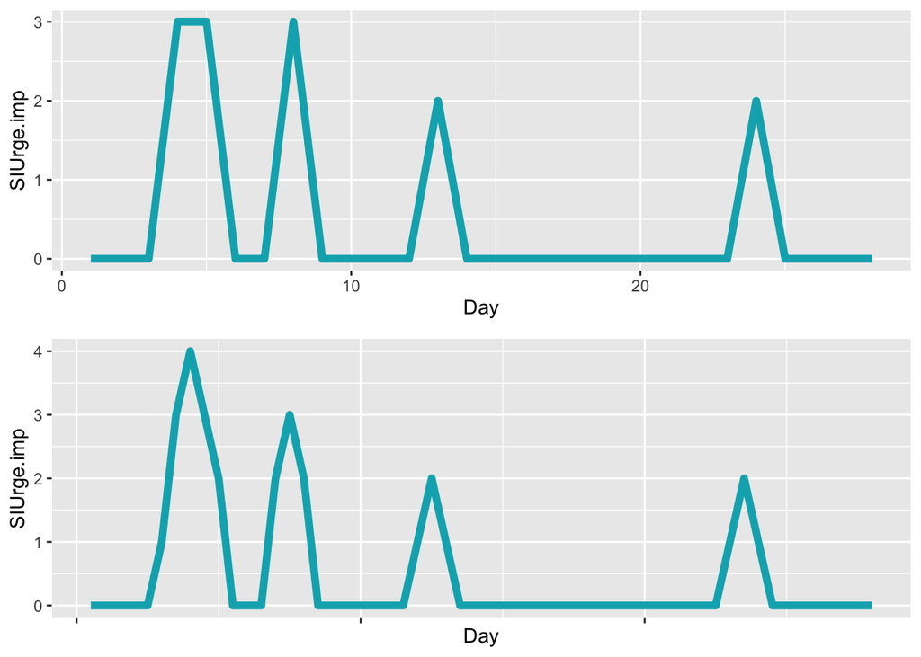

```r
a<-ggplot(data = pdat20, aes(x = Day, y = SIUrge.imp))+
  geom_line(color = "#00AFBB", size = 2)
b<-ggplot(data = pdat20.imp, aes(x = Day, y = SIUrge.imp))+
  geom_line(color = "#00AFBB", size = 2)
ggarrange(a, b + rremove("x.text"),
          ncol = 1, nrow = 2)
```

# Extracting standardized residuals

```r
mod1<-lm(coping_sum_3avg.imp~Day, data=pdat20.imp)
Coping_sum_3avg_resid = as.numeric(rstandard(mod1))

mod2<-glm(all_coping_talkfamily.imp~Day, data=pdat20.imp, family=binomial(link="logit"))
Coping_TalkFamily_resid<-as.numeric(rstandard(mod2))

mod3<-glm(all_coping_talkMH.imp~Day, data=pdat20.imp, family=binomial(link="logit"))
Coping_TalkMH_resid<-as.numeric(rstandard(mod3))

mod5<-glm(all_coping_dis_rel_combined.imp~Day, data=pdat20.imp, family=binomial(link="logit"))
Coping_dis_rel_resid<-as.numeric(rstandard(mod5))

mod6<-glm(all_coping_copingthought.imp~Day, data=pdat20.imp, family=binomial(link="logit"))
Coping_Thought_resid<-as.numeric(rstandard(mod6))

mod7<-glm(all_coping_thinking.imp~Day, data=pdat20.imp, family=binomial(link="logit"))
Coping_Thinking_resid<-as.numeric(rstandard(mod7))

mod8<-lm(coping_sum.imp~Day, data=pdat20.imp)
Coping_sum_resid<-as.numeric(rstandard(mod8))

mod9<-glm(all_coping_talkfriend.imp~Day, data=pdat20.imp, family=binomial(link="logit"))
Coping_TalkFriend_resid<-as.numeric(rstandard(mod9))

mod10<-lm(SIUrge.imp~Day, data=pdat20.imp)
SIUrge_resid<-as.numeric(rstandard(mod10))

mod11<-lm(Self_Efficacy.imp~Day, data=pdat20.imp)
Efficacy_resid<-as.numeric(rstandard(mod11))

pdat20<-as.data.frame(cbind(Coping_TalkFamily_resid, Coping_TalkMH_resid, Coping_dis_rel_resid, Coping_Thought_resid, Coping_Thinking_resid, Coping_TalkFriend_resid, Coping_sum_resid, SIUrge_resid, Efficacy_resid, Coping_sum_3avg_resid))
```

```r
attach(pdat20)
Coping_TalkFamily_resid=diff(Coping_TalkFamily_resid)
Coping_TalkMH_resid = diff(Coping_TalkMH_resid)
Coping_dis_rel_resid = diff(Coping_dis_rel_resid)
Coping_Thought_resid = diff(Coping_Thought_resid)
Coping_Thinking_resid = diff(Coping_Thinking_resid)
Coping_TalkFriend_resid = diff(Coping_TalkFriend_resid)
Coping_sum_resid = diff(Coping_sum_resid)
SIUrge_resid =  diff(SIUrge_resid)
Efficacy_resid =  diff(Efficacy_resid)
Coping_sum_3avg_resid = diff(Coping_sum_3avg_resid)

pdat20<-as.data.frame(cbind(Coping_TalkFamily_resid, Coping_TalkMH_resid, Coping_dis_rel_resid, Coping_Thought_resid, Coping_Thinking_resid, Coping_TalkFriend_resid, Coping_sum_resid, SIUrge_resid, Efficacy_resid, Coping_sum_3avg_resid))
pdat20$day<-c(1:55)
```

```r
df <- pdat20.imp %>%
  dplyr::select(Day, coping_sum.imp, SIUrge.imp) %>%
  tidyr::gather(key = "variable", value = "value", -Day)

a<-ggplot(df, aes(x = Day, y = value)) +
  geom_line(aes(linetype = variable), size = 1) + labs(y="Value", x = "Day of Study") + theme_bw()
a<-a+scale_linetype_manual(values=c("solid", "dashed"), name="Variable", labels=c("Suicidal Urge", "Sum of Coping Strategies"))

jpeg("Person 20.SUM.jpeg", res=300, height=6, width=9, units="in")
a
dev.off()
```

## Person 20: Same Day Models with SI Urge Predicting Coping

```r
pdat20.2<-c("Coping_sum_3avg_resid", "SIUrge_resid")
pdat20.2<-pdat20[pdat20.2]
coping_var=VAR(pdat20.2,p=1,  type="const")
causality(coping_var, cause="SIUrge_resid")$Granger
```

```
##
##  Granger causality H0: SIUrge_resid do not Granger-cause
##  Coping_sum_3avg_resid
##
## data:  VAR object coping_var
## F-Test = 0.16624, df1 = 1, df2 = 102, p-value = 0.6843
```

```r
summary(coping_var)
```

```
##
## VAR Estimation Results:
## =========================
## Endogenous variables: Coping_sum_3avg_resid, SIUrge_resid
## Deterministic variables: const
## Sample size: 54
## Log Likelihood: -89.977
## Roots of the characteristic polynomial:
## 0.3626 0.0849
## Call:
## VAR(y = pdat20.2, p = 1, type = "const")
##
##
## Estimation results for equation Coping_sum_3avg_resid:
## ======================================================
## Coping_sum_3avg_resid = Coping_sum_3avg_resid.l1 + SIUrge_resid.l1 + const
##
##                           Estimate Std. Error t value Pr(>|t|)
## Coping_sum_3avg_resid.l1 -0.093951   0.138034  -0.681    0.499
## SIUrge_resid.l1          -0.029396   0.072097  -0.408    0.685
## const                    -0.009174   0.058170  -0.158    0.875
##
##
## Residual standard error: 0.4267 on 51 degrees of freedom
## Multiple R-Squared: 0.01168, Adjusted R-squared: -0.02708
## F-statistic: 0.3013 on 2 and 51 DF,  p-value: 0.7412
##
##
## Estimation results for equation SIUrge_resid:
## =============================================
## SIUrge_resid = Coping_sum_3avg_resid.l1 + SIUrge_resid.l1 + const
##
##                          Estimate Std. Error t value Pr(>|t|)
## Coping_sum_3avg_resid.l1  0.14050    0.24885   0.565  0.57481
## SIUrge_resid.l1           0.37164    0.12997   2.859  0.00614 **
## const                     0.01101    0.10487   0.105  0.91677
## ---
## Signif. codes:  0 '***' 0.001 '**' 0.01 '*' 0.05 '.' 0.1 ' ' 1
##
##
## Residual standard error: 0.7692 on 51 degrees of freedom
## Multiple R-Squared: 0.1407,  Adjusted R-squared: 0.107
## F-statistic: 4.175 on 2 and 51 DF,  p-value: 0.02092
##
##
##
## Covariance matrix of residuals:
##                       Coping_sum_3avg_resid SIUrge_resid
## Coping_sum_3avg_resid              0.182060    -0.009222
## SIUrge_resid                      -0.009222     0.591702
##
## Correlation matrix of residuals:
##                       Coping_sum_3avg_resid SIUrge_resid
## Coping_sum_3avg_resid                1.0000      -0.0281
## SIUrge_resid                        -0.0281       1.0000
```

```r
pdat20.2<-c("Coping_TalkFamily_resid", "SIUrge_resid")
pdat20.2<-pdat20[pdat20.2]
coping_var=VAR(pdat20.2,p=1,  type="const")
causality(coping_var, cause="SIUrge_resid")$Granger
```

```
##
##  Granger causality H0: SIUrge_resid do not Granger-cause
##  Coping_TalkFamily_resid
##
## data:  VAR object coping_var
## F-Test = 6.9682, df1 = 1, df2 = 102, p-value = 0.0096
```

```r
summary(coping_var)
```

```
##
## VAR Estimation Results:
## =========================
## Endogenous variables: Coping_TalkFamily_resid, SIUrge_resid
## Deterministic variables: const
## Sample size: 54
## Log Likelihood: -120.136
## Roots of the characteristic polynomial:
## 0.2094 0.1337
## Call:
## VAR(y = pdat20.2, p = 1, type = "const")
##
##
## Estimation results for equation Coping_TalkFamily_resid:
## ========================================================
## Coping_TalkFamily_resid = Coping_TalkFamily_resid.l1 + SIUrge_resid.l1 + const
##
##                             Estimate Std. Error t value Pr(>|t|)
## Coping_TalkFamily_resid.l1 -0.035342   0.131868  -0.268    0.790
## SIUrge_resid.l1            -0.335525   0.127105  -2.640    0.011 *
## const                      -0.009713   0.102154  -0.095    0.925
## ---
## Signif. codes:  0 '***' 0.001 '**' 0.01 '*' 0.05 '.' 0.1 ' ' 1
##
##
## Residual standard error: 0.7502 on 51 degrees of freedom
## Multiple R-Squared: 0.1202,  Adjusted R-squared: 0.08572
## F-statistic: 3.485 on 2 and 51 DF,  p-value: 0.03815
##
##
## Estimation results for equation SIUrge_resid:
## =============================================
## SIUrge_resid = Coping_TalkFamily_resid.l1 + SIUrge_resid.l1 + const
##
##                            Estimate Std. Error t value Pr(>|t|)
## Coping_TalkFamily_resid.l1  0.12331    0.13452   0.917  0.36364
## SIUrge_resid.l1             0.37846    0.12966   2.919  0.00522 **
## const                       0.01604    0.10421   0.154  0.87826
## ---
## Signif. codes:  0 '***' 0.001 '**' 0.01 '*' 0.05 '.' 0.1 ' ' 1
##
##
## Residual standard error: 0.7653 on 51 degrees of freedom
## Multiple R-Squared: 0.1493,  Adjusted R-squared: 0.116
## F-statistic: 4.477 on 2 and 51 DF,  p-value: 0.01617
##
##
##
## Covariance matrix of residuals:
##                         Coping_TalkFamily_resid SIUrge_resid
## Coping_TalkFamily_resid                 0.56286      0.02791
## SIUrge_resid                            0.02791      0.58575
##
## Correlation matrix of residuals:
##                         Coping_TalkFamily_resid SIUrge_resid
## Coping_TalkFamily_resid                  1.0000       0.0486
## SIUrge_resid                             0.0486       1.0000
```

```r
pdat20.2<-c("Coping_TalkMH_resid", "SIUrge_resid")
pdat20.2<-pdat20[pdat20.2]
coping_var=VAR(pdat20.2,p=1,  type="const")
causality(coping_var, cause="SIUrge_resid")$Granger
```

```
##
##  Granger causality H0: SIUrge_resid do not Granger-cause
##  Coping_TalkMH_resid
##
## data:  VAR object coping_var
## F-Test = 0.58351, df1 = 1, df2 = 102, p-value = 0.4467
```

```r
summary(coping_var)
```

```
##
## VAR Estimation Results:
## =========================
## Endogenous variables: Coping_TalkMH_resid, SIUrge_resid
## Deterministic variables: const
## Sample size: 54
## Log Likelihood: -143.503
## Roots of the characteristic polynomial:
## 0.3621 0.0003779
## Call:
## VAR(y = pdat20.2, p = 1, type = "const")
##
##
## Estimation results for equation Coping_TalkMH_resid:
## ====================================================
## Coping_TalkMH_resid = Coping_TalkMH_resid.l1 + SIUrge_resid.l1 + const
##
##                         Estimate Std. Error t value Pr(>|t|)
## Coping_TalkMH_resid.l1 -0.022813   0.142420  -0.160    0.873
## SIUrge_resid.l1        -0.154251   0.201931  -0.764    0.448
## const                  -0.002242   0.159262  -0.014    0.989
##
##
## Residual standard error: 1.17 on 51 degrees of freedom
## Multiple R-Squared: 0.01131, Adjusted R-squared: -0.02746
## F-statistic: 0.2918 on 2 and 51 DF,  p-value: 0.7482
##
##
## Estimation results for equation SIUrge_resid:
## =============================================
## SIUrge_resid = Coping_TalkMH_resid.l1 + SIUrge_resid.l1 + const
##
##                        Estimate Std. Error t value Pr(>|t|)
## Coping_TalkMH_resid.l1  0.05599    0.09361   0.598  0.55240
## SIUrge_resid.l1         0.38458    0.13272   2.898  0.00553 **
## const                   0.01411    0.10468   0.135  0.89328
## ---
## Signif. codes:  0 '***' 0.001 '**' 0.01 '*' 0.05 '.' 0.1 ' ' 1
##
##
## Residual standard error: 0.7689 on 51 degrees of freedom
## Multiple R-Squared: 0.1414,  Adjusted R-squared: 0.1077
## F-statistic: 4.198 on 2 and 51 DF,  p-value: 0.02052
##
##
##
## Covariance matrix of residuals:
##                     Coping_TalkMH_resid SIUrge_resid
## Coping_TalkMH_resid              1.3686      -0.1663
## SIUrge_resid                    -0.1663       0.5913
##
## Correlation matrix of residuals:
##                     Coping_TalkMH_resid SIUrge_resid
## Coping_TalkMH_resid              1.0000      -0.1849
## SIUrge_resid                    -0.1849       1.0000
```

```r
pdat20.2<-c("Coping_dis_rel_resid", "SIUrge_resid")
pdat20.2<-pdat20[pdat20.2]
coping_var=VAR(pdat20.2,p=1,  type="const")
causality(coping_var, cause="SIUrge_resid")$Granger
```

```
##
##  Granger causality H0: SIUrge_resid do not Granger-cause
##  Coping_dis_rel_resid
##
## data:  VAR object coping_var
## F-Test = 1.0193, df1 = 1, df2 = 102, p-value = 0.3151
```

```r
summary(coping_var)
```

```
##
## VAR Estimation Results:
## =========================
## Endogenous variables: Coping_dis_rel_resid, SIUrge_resid
## Deterministic variables: const
## Sample size: 54
## Log Likelihood: -130.633
## Roots of the characteristic polynomial:
## 0.3351 0.02709
## Call:
## VAR(y = pdat20.2, p = 1, type = "const")
##
##
## Estimation results for equation Coping_dis_rel_resid:
## =====================================================
## Coping_dis_rel_resid = Coping_dis_rel_resid.l1 + SIUrge_resid.l1 + const
##
##                         Estimate Std. Error t value Pr(>|t|)
## Coping_dis_rel_resid.l1 -0.01218    0.13896  -0.088    0.930
## SIUrge_resid.l1         -0.15500    0.15353  -1.010    0.317
## const                   -0.02948    0.12366  -0.238    0.813
##
##
## Residual standard error: 0.9078 on 51 degrees of freedom
## Multiple R-Squared: 0.0196,  Adjusted R-squared: -0.01885
## F-statistic: 0.5098 on 2 and 51 DF,  p-value: 0.6036
##
##
## Estimation results for equation SIUrge_resid:
## =============================================
## SIUrge_resid = Coping_dis_rel_resid.l1 + SIUrge_resid.l1 + const
##
##                         Estimate Std. Error t value Pr(>|t|)
## Coping_dis_rel_resid.l1  0.08800    0.11747   0.749  0.45723
## SIUrge_resid.l1          0.37437    0.12979   2.884  0.00573 **
## const                    0.01691    0.10454   0.162  0.87213
## ---
## Signif. codes:  0 '***' 0.001 '**' 0.01 '*' 0.05 '.' 0.1 ' ' 1
##
##
## Residual standard error: 0.7674 on 51 degrees of freedom
## Multiple R-Squared: 0.1447,  Adjusted R-squared: 0.1112
## F-statistic: 4.316 on 2 and 51 DF,  p-value: 0.01855
##
##
##
## Covariance matrix of residuals:
##                      Coping_dis_rel_resid SIUrge_resid
## Coping_dis_rel_resid              0.82408     -0.01086
## SIUrge_resid                     -0.01086      0.58892
##
## Correlation matrix of residuals:
##                      Coping_dis_rel_resid SIUrge_resid
## Coping_dis_rel_resid              1.00000     -0.01559
## SIUrge_resid                     -0.01559      1.00000
```

```r
pdat20.2<-c("Coping_Thinking_resid", "SIUrge_resid")
pdat20.2<-pdat20[pdat20.2]
coping_var=VAR(pdat20.2,p=1,  type="const")
causality(coping_var, cause="SIUrge_resid")$Granger
```

```
##
##  Granger causality H0: SIUrge_resid do not Granger-cause
##  Coping_Thinking_resid
##
## data:  VAR object coping_var
## F-Test = 2.6012, df1 = 1, df2 = 102, p-value = 0.1099
```

```r
summary(coping_var)
```

```
##
## VAR Estimation Results:
## =========================
## Endogenous variables: Coping_Thinking_resid, SIUrge_resid
## Deterministic variables: const
## Sample size: 54
## Log Likelihood: -138.628
## Roots of the characteristic polynomial:
## 0.2457 0.2457
## Call:
## VAR(y = pdat20.2, p = 1, type = "const")
##
##
## Estimation results for equation Coping_Thinking_resid:
## ======================================================
## Coping_Thinking_resid = Coping_Thinking_resid.l1 + SIUrge_resid.l1 + const
##
##                          Estimate Std. Error t value Pr(>|t|)
## Coping_Thinking_resid.l1  0.01092    0.13681   0.080    0.937
## SIUrge_resid.l1          -0.30042    0.18627  -1.613    0.113
## const                    -0.01478    0.15007  -0.098    0.922
##
##
## Residual standard error: 1.102 on 51 degrees of freedom
## Multiple R-Squared: 0.04853, Adjusted R-squared: 0.01122
## F-statistic: 1.301 on 2 and 51 DF,  p-value: 0.2812
##
##
## Estimation results for equation SIUrge_resid:
## =============================================
## SIUrge_resid = Coping_Thinking_resid.l1 + SIUrge_resid.l1 + const
##
##                          Estimate Std. Error t value Pr(>|t|)
## Coping_Thinking_resid.l1  0.18814    0.09209   2.043  0.04625 *
## SIUrge_resid.l1           0.35330    0.12539   2.818  0.00687 **
## const                     0.01863    0.10102   0.184  0.85445
## ---
## Signif. codes:  0 '***' 0.001 '**' 0.01 '*' 0.05 '.' 0.1 ' ' 1
##
##
## Residual standard error: 0.7419 on 51 degrees of freedom
## Multiple R-Squared: 0.2007,  Adjusted R-squared: 0.1694
## F-statistic: 6.404 on 2 and 51 DF,  p-value: 0.003301
##
##
##
## Covariance matrix of residuals:
##                       Coping_Thinking_resid SIUrge_resid
## Coping_Thinking_resid                1.2145       0.1266
## SIUrge_resid                         0.1266       0.5504
##
## Correlation matrix of residuals:
##                       Coping_Thinking_resid SIUrge_resid
## Coping_Thinking_resid                1.0000       0.1549
## SIUrge_resid                         0.1549       1.0000
```

```r
pdat20.2<-c("Coping_Thought_resid", "SIUrge_resid")
pdat20.2<-pdat20[pdat20.2]
coping_var=VAR(pdat20.2,p=1,  type="const")
causality(coping_var, cause="SIUrge_resid")$Granger
```

```
##
##  Granger causality H0: SIUrge_resid do not Granger-cause
##  Coping_Thought_resid
##
## data:  VAR object coping_var
## F-Test = 2.5726, df1 = 1, df2 = 102, p-value = 0.1118
```

```r
summary(coping_var)
```

```
##
## VAR Estimation Results:
## =========================
## Endogenous variables: Coping_Thought_resid, SIUrge_resid
## Deterministic variables: const
## Sample size: 54
## Log Likelihood: -124.346
## Roots of the characteristic polynomial:
## 0.2195 0.2195
## Call:
## VAR(y = pdat20.2, p = 1, type = "const")
##
##
## Estimation results for equation Coping_Thought_resid:
## =====================================================
## Coping_Thought_resid = Coping_Thought_resid.l1 + SIUrge_resid.l1 + const
##
##                           Estimate Std. Error t value Pr(>|t|)
## Coping_Thought_resid.l1 -0.0002533  0.1366249  -0.002    0.999
## SIUrge_resid.l1         -0.2248436  0.1401836  -1.604    0.115
## const                    0.0345285  0.1131646   0.305    0.762
##
##
## Residual standard error: 0.8307 on 51 degrees of freedom
## Multiple R-Squared: 0.04802, Adjusted R-squared: 0.01069
## F-statistic: 1.286 on 2 and 51 DF,  p-value: 0.2851
##
##
## Estimation results for equation SIUrge_resid:
## =============================================
## SIUrge_resid = Coping_Thought_resid.l1 + SIUrge_resid.l1 + const
##
##                         Estimate Std. Error t value Pr(>|t|)
## Coping_Thought_resid.l1  0.21474    0.12329   1.742  0.08757 .
## SIUrge_resid.l1          0.36745    0.12650   2.905  0.00542 **
## const                    0.00783    0.10212   0.077  0.93919
## ---
## Signif. codes:  0 '***' 0.001 '**' 0.01 '*' 0.05 '.' 0.1 ' ' 1
##
##
## Residual standard error: 0.7496 on 51 degrees of freedom
## Multiple R-Squared: 0.1839,  Adjusted R-squared: 0.1519
## F-statistic: 5.745 on 2 and 51 DF,  p-value: 0.00562
##
##
##
## Covariance matrix of residuals:
##                      Coping_Thought_resid SIUrge_resid
## Coping_Thought_resid              0.69012      0.05837
## SIUrge_resid                      0.05837      0.56197
##
## Correlation matrix of residuals:
##                      Coping_Thought_resid SIUrge_resid
## Coping_Thought_resid              1.00000      0.09373
## SIUrge_resid                      0.09373      1.00000
```

```r
pdat20.2<-c("Coping_TalkFriend_resid", "SIUrge_resid")
pdat20.2<-pdat20[pdat20.2]
coping_var=VAR(pdat20.2,p=1,  type="const")
causality(coping_var, cause="SIUrge_resid")$Granger
```

```
##
##  Granger causality H0: SIUrge_resid do not Granger-cause
##  Coping_TalkFriend_resid
##
## data:  VAR object coping_var
## F-Test = 0.1695, df1 = 1, df2 = 102, p-value = 0.6814
```

```r
summary(coping_var)
```

```
##
## VAR Estimation Results:
## =========================
## Endogenous variables: Coping_TalkFriend_resid, SIUrge_resid
## Deterministic variables: const
## Sample size: 54
## Log Likelihood: -142.634
## Roots of the characteristic polynomial:
## 0.3674 0.001121
## Call:
## VAR(y = pdat20.2, p = 1, type = "const")
##
##
## Estimation results for equation Coping_TalkFriend_resid:
## ========================================================
## Coping_TalkFriend_resid = Coping_TalkFriend_resid.l1 + SIUrge_resid.l1 + const
##
##                             Estimate Std. Error t value Pr(>|t|)
## Coping_TalkFriend_resid.l1 -0.001593   0.139797  -0.011    0.991
## SIUrge_resid.l1            -0.078348   0.190303  -0.412    0.682
## const                      -0.020191   0.153558  -0.131    0.896
##
##
## Residual standard error: 1.128 on 51 degrees of freedom
## Multiple R-Squared: 0.003315,    Adjusted R-squared: -0.03577
## F-statistic: 0.08482 on 2 and 51 DF,  p-value: 0.9188
##
##
## Estimation results for equation SIUrge_resid:
## =============================================
## SIUrge_resid = Coping_TalkFriend_resid.l1 + SIUrge_resid.l1 + const
##
##                            Estimate Std. Error t value Pr(>|t|)
## Coping_TalkFriend_resid.l1 0.002222   0.095651   0.023  0.98155
## SIUrge_resid.l1            0.367871   0.130208   2.825  0.00673 **
## const                      0.014230   0.105066   0.135  0.89280
## ---
## Signif. codes:  0 '***' 0.001 '**' 0.01 '*' 0.05 '.' 0.1 ' ' 1
##
##
## Residual standard error: 0.7716 on 51 degrees of freedom
## Multiple R-Squared: 0.1353,  Adjusted R-squared: 0.1014
## F-statistic: 3.991 on 2 and 51 DF,  p-value: 0.02452
##
##
##
## Covariance matrix of residuals:
##                         Coping_TalkFriend_resid SIUrge_resid
## Coping_TalkFriend_resid                 1.27181      0.02153
## SIUrge_resid                            0.02153      0.59539
##
## Correlation matrix of residuals:
##                         Coping_TalkFriend_resid SIUrge_resid
## Coping_TalkFriend_resid                 1.00000      0.02474
## SIUrge_resid                            0.02474      1.00000
```

```r
pdat20.2<-c("Coping_sum_resid", "SIUrge_resid")
pdat20.2<-pdat20[pdat20.2]
coping_var=VAR(pdat20.2,p=1,  type="const")
causality(coping_var, cause="SIUrge_resid")$Granger
```

```
##
##  Granger causality H0: SIUrge_resid do not Granger-cause
##  Coping_sum_resid
##
## data:  VAR object coping_var
## F-Test = 8.2497, df1 = 1, df2 = 102, p-value = 0.004958
```

```r
summary(coping_var)
```

```
##
## VAR Estimation Results:
## =========================
## Endogenous variables: Coping_sum_resid, SIUrge_resid
## Deterministic variables: const
## Sample size: 54
## Log Likelihood: -110.853
## Roots of the characteristic polynomial:
## 0.4802 0.4802
## Call:
## VAR(y = pdat20.2, p = 1, type = "const")
##
##
## Estimation results for equation Coping_sum_resid:
## =================================================
## Coping_sum_resid = Coping_sum_resid.l1 + SIUrge_resid.l1 + const
##
##                     Estimate Std. Error t value Pr(>|t|)
## Coping_sum_resid.l1  0.41333    0.12368   3.342  0.00156 **
## SIUrge_resid.l1     -0.31394    0.10930  -2.872  0.00592 **
## const                0.02347    0.08815   0.266  0.79108
## ---
## Signif. codes:  0 '***' 0.001 '**' 0.01 '*' 0.05 '.' 0.1 ' ' 1
##
##
## Residual standard error: 0.6475 on 51 degrees of freedom
## Multiple R-Squared: 0.2704,  Adjusted R-squared: 0.2418
## F-statistic:  9.45 on 2 and 51 DF,  p-value: 0.0003227
##
##
## Estimation results for equation SIUrge_resid:
## =============================================
## SIUrge_resid = Coping_sum_resid.l1 + SIUrge_resid.l1 + const
##
##                     Estimate Std. Error t value Pr(>|t|)
## Coping_sum_resid.l1  0.25866    0.14287   1.810  0.07611 .
## SIUrge_resid.l1      0.36153    0.12626   2.863  0.00607 **
## const                0.01343    0.10182   0.132  0.89560
## ---
## Signif. codes:  0 '***' 0.001 '**' 0.01 '*' 0.05 '.' 0.1 ' ' 1
##
##
## Residual standard error: 0.748 on 51 degrees of freedom
## Multiple R-Squared: 0.1876,  Adjusted R-squared: 0.1557
## F-statistic: 5.887 on 2 and 51 DF,  p-value: 0.00501
##
##
##
## Covariance matrix of residuals:
##                  Coping_sum_resid SIUrge_resid
## Coping_sum_resid          0.41923      0.03636
## SIUrge_resid              0.03636      0.55944
##
## Correlation matrix of residuals:
##                  Coping_sum_resid SIUrge_resid
## Coping_sum_resid          1.00000      0.07507
## SIUrge_resid              0.07507      1.00000
```

```r
pdat20.2<-c("Efficacy_resid", "SIUrge_resid")
pdat20.2<-pdat20[pdat20.2]
coping_var=VAR(pdat20.2,p=1,  type="const")
causality(coping_var, cause="SIUrge_resid")$Granger
```

```
##
##  Granger causality H0: SIUrge_resid do not Granger-cause Efficacy_resid
##
## data:  VAR object coping_var
## F-Test = 0.51947, df1 = 1, df2 = 102, p-value = 0.4727
```

```r
summary(coping_var)
```

```
##
## VAR Estimation Results:
## =========================
## Endogenous variables: Efficacy_resid, SIUrge_resid
## Deterministic variables: const
## Sample size: 54
## Log Likelihood: -125.691
## Roots of the characteristic polynomial:
## 0.3674  0.22
## Call:
## VAR(y = pdat20.2, p = 1, type = "const")
##
##
## Estimation results for equation Efficacy_resid:
## ===============================================
## Efficacy_resid = Efficacy_resid.l1 + SIUrge_resid.l1 + const
##
##                   Estimate Std. Error t value Pr(>|t|)
## Efficacy_resid.l1 0.219380   0.122465   1.791   0.0792 .
## SIUrge_resid.l1   0.101333   0.140595   0.721   0.4744
## const             0.003779   0.112926   0.033   0.9734
## ---
## Signif. codes:  0 '***' 0.001 '**' 0.01 '*' 0.05 '.' 0.1 ' ' 1
##
##
## Residual standard error: 0.8274 on 51 degrees of freedom
## Multiple R-Squared: 0.0742,  Adjusted R-squared: 0.03789
## F-statistic: 2.044 on 2 and 51 DF,  p-value: 0.14
##
##
## Estimation results for equation SIUrge_resid:
## =============================================
## SIUrge_resid = Efficacy_resid.l1 + SIUrge_resid.l1 + const
##
##                     Estimate Std. Error t value Pr(>|t|)
## Efficacy_resid.l1 -0.0008334  0.1142064  -0.007  0.99421
## SIUrge_resid.l1    0.3679882  0.1311132   2.807  0.00707 **
## const              0.0141261  0.1053101   0.134  0.89382
## ---
## Signif. codes:  0 '***' 0.001 '**' 0.01 '*' 0.05 '.' 0.1 ' ' 1
##
##
## Residual standard error: 0.7716 on 51 degrees of freedom
## Multiple R-Squared: 0.1353,  Adjusted R-squared: 0.1014
## F-statistic: 3.991 on 2 and 51 DF,  p-value: 0.02453
##
##
##
## Covariance matrix of residuals:
##                Efficacy_resid SIUrge_resid
## Efficacy_resid        0.68463      0.05985
## SIUrge_resid          0.05985      0.59540
##
## Correlation matrix of residuals:
##                Efficacy_resid SIUrge_resid
## Efficacy_resid        1.00000      0.09375
## SIUrge_resid          0.09375      1.00000
```

# Person 223

## Specifying the data structure for imputation

```r
MImodel = pdat21[c(-1,-2)]
MImodel[,1] = as.factor(MImodel[,1])
MImodel[,2] = as.factor(MImodel[,2])
MImodel[,3] = as.factor(MImodel[,3])
MImodel[,4] = as.factor(MImodel[,4])
MImodel[,5] = as.factor(MImodel[,5])
MImodel[,6] = as.factor(MImodel[,6])
MImodel[,7] = as.factor(MImodel[,7])
MImodel[,10] = as.factor(MImodel[,10])
MImodel[,14] = as.factor(MImodel[,14])
MImodel[,15] = as.factor(MImodel[,15])
MImodel[,16] = as.factor(MImodel[,16])
MImodel[,17] = as.factor(MImodel[,17])
MImodel[,18] = as.factor(MImodel[,18])
MImodel[,19] = as.factor(MImodel[,19])
MImodel[,20] = as.factor(MImodel[,20])
MImodel[,22] = as.factor(MImodel[,22])
```

## Imputation

```r
m = 5
imp = mice(MImodel,m = m)
```

```
##
##  * Please inspect the loggedEvents
```

```r
k=24

qhat = matrix(NA, nrow = m,ncol = k)

u = array(NA,dim = c(k,k,m))

for (i in 1:m) {
data.impute = mice::complete(imp,action = i)}

all_coping_talkfamily.imp = as.factor(data.impute[,1])
all_coping_talkMH.imp = as.factor(data.impute[,2])
all_coping_copingthought.imp = as.factor(data.impute[,3])
all_coping_thinking.imp = as.factor(data.impute[,4])
all_coping_talkfriend.imp = as.factor(data.impute[,5])
all_coping_dis_rel_combined.imp = as.factor(data.impute[,6])
all_coping_crisisline.imp  = as.factor(data.impute[,7])
coping_sum.imp = data.impute[,8]
coping_sum_3avg.imp  = data.impute[,9]
all_coping_any.imp = as.factor(as.factor(data.impute[,10]))
SIUrge.imp  = data.impute[,11]
Self_Efficacy.imp = data.impute[,12]

pdat21.imp<-data.frame(all_coping_talkfamily.imp = all_coping_talkfamily.imp,
                      all_coping_talkMH.imp = all_coping_talkMH.imp,
                      all_coping_crisisline.imp = all_coping_crisisline.imp,
                      all_coping_copingthought.imp = all_coping_copingthought.imp,
                      all_coping_thinking.imp = all_coping_thinking.imp,
                      all_coping_talkfriend.imp =  all_coping_talkfriend.imp,
                      all_coping_dis_rel_combined.imp = all_coping_dis_rel_combined.imp,
                      all_coping_any.imp = all_coping_any.imp,
                      SIUrge.imp = SIUrge.imp,
                      Self_Efficacy.imp = Self_Efficacy.imp,
                      coping_sum_3avg.imp = coping_sum_3avg.imp,
                      coping_sum.imp = coping_sum.imp)
```

## Restructuring Data file to create splines

```r
na.df <- data.frame(SIUrge.imp = NA)
vars<-c("SIUrge.imp")
pdat21.1<-pdat21.imp[vars]
pdat21.2<- do.call(rbind, apply(pdat21.1, 1, function(x) {rbind(x, na.df)}))

na.df <- data.frame(all_coping_talkfamily.imp = NA,
        all_coping_talkMH.imp = NA,
        all_coping_copingthought.imp = NA,
        all_coping_thinking.imp = NA,
        all_coping_talkfriend.imp = NA,
        all_coping_dis_rel_combined.imp = NA,
        all_coping_any.imp = NA,
        Self_Efficacy.imp = NA,
        coping_sum.imp = NA,
        coping_sum_3avg.imp = NA)

vars<-c("all_coping_talkfamily.imp",
        "all_coping_talkMH.imp",
        "all_coping_copingthought.imp",
        "all_coping_thinking.imp",
        "all_coping_talkfriend.imp",
        "all_coping_dis_rel_combined.imp",
        "all_coping_any.imp",
        "Self_Efficacy.imp",
        "coping_sum.imp",
        "coping_sum_3avg.imp")
pdat21.3<-pdat21.imp[vars]
pdat21.4 <- do.call(rbind, apply(pdat21.3, 1, function(x) {rbind(na.df, x)}))

pdat21.imp<-cbind(pdat21.4, pdat21.2)
pdat21.imp$Day<-c(1:56)
```

## Creating splines

```r
pdat21.imp<-data.frame(na.spline(pdat21.imp))
pdat21.imp<-round(pdat21.imp)
pdat21.imp$SIUrge.imp[pdat21.imp$SIUrge.imp>7]<-7
pdat21.imp$SIUrge.imp[pdat21.imp$SIUrge.imp<0]<-0
pdat21.imp$Self_Efficacy.imp[pdat21.imp$Self_Efficacy.imp>10]<-10
pdat21.imp$Self_Efficacy.imp[pdat21.imp$Self_Efficacy.imp<0]<-0
```

```r
pdat21.imp <- pdat21.imp %>%
     mutate_at(c(cols),list(~recode(., `-3`=0,`-2`=0,`-1`=0,`2`= 1,`3`=1)))

cols <- c("all_coping_talkfamily.imp",
        "all_coping_talkMH.imp",
        "all_coping_copingthought.imp",
        "all_coping_thinking.imp",
        "all_coping_talkfriend.imp",
        "all_coping_dis_rel_combined.imp",
        "all_coping_any.imp")
pdat21.imp[cols] <- lapply(pdat21.imp[cols], factor)
```

## Comparing pre vs post splines

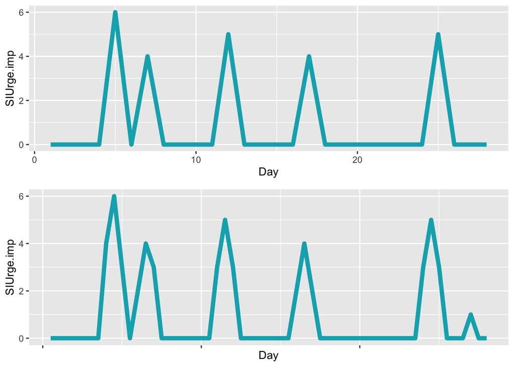

```r
a<-ggplot(data = pdat21, aes(x = Day, y = SIUrge.imp))+
  geom_line(color = "#00AFBB", size = 2)
b<-ggplot(data = pdat21.imp, aes(x = Day, y = SIUrge.imp))+
  geom_line(color = "#00AFBB", size = 2)
ggarrange(a, b + rremove("x.text"),
          ncol = 1, nrow = 2)
```

## Extracting standardized residuals

```r
mod1<-lm(coping_sum_3avg.imp~Day, data=pdat21.imp)
Coping_sum_3avg_resid = as.numeric(rstandard(mod1))

mod2<-glm(all_coping_talkfamily.imp~Day, data=pdat21.imp, family=binomial(link="logit"))
Coping_TalkFamily_resid<-as.numeric(rstandard(mod2))

mod3<-glm(all_coping_talkMH.imp~Day, data=pdat21.imp, family=binomial(link="logit"))
Coping_TalkMH_resid<-as.numeric(rstandard(mod3))

mod5<-glm(all_coping_dis_rel_combined.imp~Day, data=pdat21.imp, family=binomial(link="logit"))
Coping_dis_rel_resid<-as.numeric(rstandard(mod5))

mod6<-glm(all_coping_copingthought.imp~Day, data=pdat21.imp, family=binomial(link="logit"))
Coping_Thought_resid<-as.numeric(rstandard(mod6))

mod7<-glm(all_coping_thinking.imp~Day, data=pdat21.imp, family=binomial(link="logit"))
Coping_Thinking_resid<-as.numeric(rstandard(mod7))

mod8<-lm(coping_sum.imp~Day, data=pdat21.imp)
Coping_sum_resid<-as.numeric(rstandard(mod8))

mod9<-glm(all_coping_talkfriend.imp~Day, data=pdat21.imp, family=binomial(link="logit"))
Coping_TalkFriend_resid<-as.numeric(rstandard(mod9))

mod10<-lm(SIUrge.imp~Day, data=pdat21.imp)
SIUrge_resid<-as.numeric(rstandard(mod10))

mod11<-lm(Self_Efficacy.imp~Day, data=pdat21.imp)
Efficacy_resid<-as.numeric(rstandard(mod11))

pdat21<-as.data.frame(cbind(Coping_TalkFamily_resid, Coping_TalkMH_resid, Coping_dis_rel_resid, Coping_Thought_resid, Coping_Thinking_resid, Coping_TalkFriend_resid,Coping_sum_resid, SIUrge_resid, Efficacy_resid, Coping_sum_3avg_resid))
```

## Person 21: Calculating Difference Scores

```r
attach(pdat21)
Coping_TalkFamily_resid=diff(Coping_TalkFamily_resid)
Coping_TalkMH_resid = diff(Coping_TalkMH_resid)
Coping_dis_rel_resid = diff(Coping_dis_rel_resid)
Coping_Thought_resid = diff(Coping_Thought_resid)
Coping_Thinking_resid = diff(Coping_Thinking_resid)
Coping_TalkFriend_resid = diff(Coping_TalkFriend_resid)
Coping_sum_resid = diff(Coping_sum_resid)
SIUrge_resid =  diff(SIUrge_resid)
Efficacy_resid =  diff(Efficacy_resid)
Coping_sum_3avg_resid = diff(Coping_sum_3avg_resid)

pdat21<-as.data.frame(cbind(Coping_TalkFamily_resid, Coping_TalkMH_resid, Coping_dis_rel_resid, Coping_Thought_resid, Coping_Thinking_resid, Coping_TalkFriend_resid,Coping_sum_resid, SIUrge_resid, Efficacy_resid, Coping_sum_3avg_resid))
pdat21$day<-c(1:55)
```

## Person 21: Same Day Models with SI Urge Predicting Coping

```r
pdat21.2<-c("Coping_sum_3avg_resid", "SIUrge_resid")
pdat21.2<-pdat21[pdat21.2]
coping_var=VAR(pdat21.2,p=1,  type="const")
causality(coping_var, cause="SIUrge_resid")$Granger
```

```
##
##  Granger causality H0: SIUrge_resid do not Granger-cause
##  Coping_sum_3avg_resid
##
## data:  VAR object coping_var
## F-Test = 3.2147, df1 = 1, df2 = 102, p-value = 0.07594
```

```r
summary(coping_var)
```

```
##
## VAR Estimation Results:
## =========================
## Endogenous variables: Coping_sum_3avg_resid, SIUrge_resid
## Deterministic variables: const
## Sample size: 54
## Log Likelihood: -117.684
## Roots of the characteristic polynomial:
## 0.1254 0.1254
## Call:
## VAR(y = pdat21.2, p = 1, type = "const")
##
##
## Estimation results for equation Coping_sum_3avg_resid:
## ======================================================
## Coping_sum_3avg_resid = Coping_sum_3avg_resid.l1 + SIUrge_resid.l1 + const
##
##                          Estimate Std. Error t value Pr(>|t|)
## Coping_sum_3avg_resid.l1 -0.10358    0.13509  -0.767   0.4468
## SIUrge_resid.l1          -0.15487    0.08638  -1.793   0.0789 .
## const                     0.01967    0.08093   0.243   0.8090
## ---
## Signif. codes:  0 '***' 0.001 '**' 0.01 '*' 0.05 '.' 0.1 ' ' 1
##
##
## Residual standard error: 0.5945 on 51 degrees of freedom
## Multiple R-Squared: 0.06932, Adjusted R-squared: 0.03282
## F-statistic: 1.899 on 2 and 51 DF,  p-value: 0.1601
##
##
## Estimation results for equation SIUrge_resid:
## =============================================
## SIUrge_resid = Coping_sum_3avg_resid.l1 + SIUrge_resid.l1 + const
##
##                          Estimate Std. Error t value Pr(>|t|)
## Coping_sum_3avg_resid.l1 0.255330   0.210121   1.215    0.230
## SIUrge_resid.l1          0.229974   0.134352   1.712    0.093 .
## const                    0.001146   0.125883   0.009    0.993
## ---
## Signif. codes:  0 '***' 0.001 '**' 0.01 '*' 0.05 '.' 0.1 ' ' 1
##
##
## Residual standard error: 0.9247 on 51 degrees of freedom
## Multiple R-Squared: 0.07943, Adjusted R-squared: 0.04333
## F-statistic:   2.2 on 2 and 51 DF,  p-value: 0.1212
##
##
##
## Covariance matrix of residuals:
##                       Coping_sum_3avg_resid SIUrge_resid
## Coping_sum_3avg_resid               0.35339      0.04218
## SIUrge_resid                        0.04218      0.85498
##
## Correlation matrix of residuals:
##                       Coping_sum_3avg_resid SIUrge_resid
## Coping_sum_3avg_resid               1.00000      0.07674
## SIUrge_resid                        0.07674      1.00000
```

```r
pdat21.2<-c("Coping_TalkFamily_resid", "SIUrge_resid")
pdat21.2<-pdat21[pdat21.2]
coping_var=VAR(pdat21.2,p=1,  type="const")
causality(coping_var, cause="SIUrge_resid")$Granger
```

```
##
##  Granger causality H0: SIUrge_resid do not Granger-cause
##  Coping_TalkFamily_resid
##
## data:  VAR object coping_var
## F-Test = 0.70497, df1 = 1, df2 = 102, p-value = 0.4031
```

```r
summary(coping_var)
```

```
##
## VAR Estimation Results:
## =========================
## Endogenous variables: Coping_TalkFamily_resid, SIUrge_resid
## Deterministic variables: const
## Sample size: 54
## Log Likelihood: -156.772
## Roots of the characteristic polynomial:
## 0.2127 0.004878
## Call:
## VAR(y = pdat21.2, p = 1, type = "const")
##
##
## Estimation results for equation Coping_TalkFamily_resid:
## ========================================================
## Coping_TalkFamily_resid = Coping_TalkFamily_resid.l1 + SIUrge_resid.l1 + const
##
##                            Estimate Std. Error t value Pr(>|t|)
## Coping_TalkFamily_resid.l1 -0.01944    0.14073  -0.138    0.891
## SIUrge_resid.l1            -0.15023    0.17892  -0.840    0.405
## const                      -0.02258    0.16563  -0.136    0.892
##
##
## Residual standard error: 1.217 on 51 degrees of freedom
## Multiple R-Squared: 0.01364, Adjusted R-squared: -0.02504
## F-statistic: 0.3525 on 2 and 51 DF,  p-value: 0.7046
##
##
## Estimation results for equation SIUrge_resid:
## =============================================
## SIUrge_resid = Coping_TalkFamily_resid.l1 + SIUrge_resid.l1 + const
##
##                            Estimate Std. Error t value Pr(>|t|)
## Coping_TalkFamily_resid.l1 0.037590   0.108347   0.347   0.7301
## SIUrge_resid.l1            0.237056   0.137749   1.721   0.0913 .
## const                      0.006261   0.127513   0.049   0.9610
## ---
## Signif. codes:  0 '***' 0.001 '**' 0.01 '*' 0.05 '.' 0.1 ' ' 1
##
##
## Residual standard error: 0.9368 on 51 degrees of freedom
## Multiple R-Squared: 0.05501, Adjusted R-squared: 0.01795
## F-statistic: 1.484 on 2 and 51 DF,  p-value: 0.2363
##
##
##
## Covariance matrix of residuals:
##                         Coping_TalkFamily_resid SIUrge_resid
## Coping_TalkFamily_resid                  1.4808      -0.1486
## SIUrge_resid                            -0.1486       0.8777
##
## Correlation matrix of residuals:
##                         Coping_TalkFamily_resid SIUrge_resid
## Coping_TalkFamily_resid                  1.0000      -0.1304
## SIUrge_resid                            -0.1304       1.0000
```

```r
pdat21.2<-c("Coping_TalkMH_resid", "SIUrge_resid")
pdat21.2<-pdat21[pdat21.2]
coping_var=VAR(pdat21.2,p=1,  type="const")
causality(coping_var, cause="SIUrge_resid")$Granger
```

```
##
##  Granger causality H0: SIUrge_resid do not Granger-cause
##  Coping_TalkMH_resid
##
## data:  VAR object coping_var
## F-Test = 5.4866, df1 = 1, df2 = 102, p-value = 0.0211
```

```r
summary(coping_var)
```

```
##
## VAR Estimation Results:
## =========================
## Endogenous variables: Coping_TalkMH_resid, SIUrge_resid
## Deterministic variables: const
## Sample size: 54
## Log Likelihood: -147.2
## Roots of the characteristic polynomial:
## 0.247 0.247
## Call:
## VAR(y = pdat21.2, p = 1, type = "const")
##
##
## Estimation results for equation Coping_TalkMH_resid:
## ====================================================
## Coping_TalkMH_resid = Coping_TalkMH_resid.l1 + SIUrge_resid.l1 + const
##
##                        Estimate Std. Error t value Pr(>|t|)
## Coping_TalkMH_resid.l1 -0.10015    0.13953  -0.718   0.4762
## SIUrge_resid.l1        -0.38561    0.16462  -2.342   0.0231 *
## const                  -0.02796    0.14707  -0.190   0.8500
## ---
## Signif. codes:  0 '***' 0.001 '**' 0.01 '*' 0.05 '.' 0.1 ' ' 1
##
##
## Residual standard error: 1.08 on 51 degrees of freedom
## Multiple R-Squared: 0.09713, Adjusted R-squared: 0.06173
## F-statistic: 2.743 on 2 and 51 DF,  p-value: 0.07386
##
##
## Estimation results for equation SIUrge_resid:
## =============================================
## SIUrge_resid = Coping_TalkMH_resid.l1 + SIUrge_resid.l1 + const
##
##                        Estimate Std. Error t value Pr(>|t|)
## Coping_TalkMH_resid.l1   0.2400     0.1164   2.062   0.0443 *
## SIUrge_resid.l1          0.3150     0.1373   2.294   0.0259 *
## const                    0.0115     0.1227   0.094   0.9257
## ---
## Signif. codes:  0 '***' 0.001 '**' 0.01 '*' 0.05 '.' 0.1 ' ' 1
##
##
## Residual standard error: 0.9011 on 51 degrees of freedom
## Multiple R-Squared: 0.1257,  Adjusted R-squared: 0.09141
## F-statistic: 3.666 on 2 and 51 DF,  p-value: 0.03254
##
##
##
## Covariance matrix of residuals:
##                     Coping_TalkMH_resid SIUrge_resid
## Coping_TalkMH_resid              1.1672      -0.2271
## SIUrge_resid                    -0.2271       0.8120
##
## Correlation matrix of residuals:
##                     Coping_TalkMH_resid SIUrge_resid
## Coping_TalkMH_resid              1.0000      -0.2333
## SIUrge_resid                    -0.2333       1.0000
```

```r
pdat21.2<-c("Coping_dis_rel_resid", "SIUrge_resid")
pdat21.2<-pdat21[pdat21.2]
coping_var=VAR(pdat21.2,p=1,  type="const")
causality(coping_var, cause="SIUrge_resid")$Granger
```

```
##
##  Granger causality H0: SIUrge_resid do not Granger-cause
##  Coping_dis_rel_resid
##
## data:  VAR object coping_var
## F-Test = 0.43254, df1 = 1, df2 = 102, p-value = 0.5122
```

```r
summary(coping_var)
```

```
##
## VAR Estimation Results:
## =========================
## Endogenous variables: Coping_dis_rel_resid, SIUrge_resid
## Deterministic variables: const
## Sample size: 54
## Log Likelihood: -162.385
## Roots of the characteristic polynomial:
## 0.1772 0.05397
## Call:
## VAR(y = pdat21.2, p = 1, type = "const")
##
##
## Estimation results for equation Coping_dis_rel_resid:
## =====================================================
## Coping_dis_rel_resid = Coping_dis_rel_resid.l1 + SIUrge_resid.l1 + const
##
##                          Estimate Std. Error t value Pr(>|t|)
## Coping_dis_rel_resid.l1 -0.006218   0.144565  -0.043    0.966
## SIUrge_resid.l1          0.129084   0.196272   0.658    0.514
## const                    0.012763   0.183490   0.070    0.945
##
##
## Residual standard error: 1.348 on 51 degrees of freedom
## Multiple R-Squared: 0.00841, Adjusted R-squared: -0.03048
## F-statistic: 0.2163 on 2 and 51 DF,  p-value: 0.8063
##
##
## Estimation results for equation SIUrge_resid:
## =============================================
## SIUrge_resid = Coping_dis_rel_resid.l1 + SIUrge_resid.l1 + const
##
##                          Estimate Std. Error t value Pr(>|t|)
## Coping_dis_rel_resid.l1 -0.085504   0.099882  -0.856   0.3960
## SIUrge_resid.l1          0.237356   0.135607   1.750   0.0861 .
## const                    0.002681   0.126775   0.021   0.9832
## ---
## Signif. codes:  0 '***' 0.001 '**' 0.01 '*' 0.05 '.' 0.1 ' ' 1
##
##
## Residual standard error: 0.9313 on 51 degrees of freedom
## Multiple R-Squared: 0.0662,  Adjusted R-squared: 0.02958
## F-statistic: 1.808 on 2 and 51 DF,  p-value: 0.1744
##
##
##
## Covariance matrix of residuals:
##                      Coping_dis_rel_resid SIUrge_resid
## Coping_dis_rel_resid              1.81682      0.05444
## SIUrge_resid                      0.05444      0.86728
##
## Correlation matrix of residuals:
##                      Coping_dis_rel_resid SIUrge_resid
## Coping_dis_rel_resid              1.00000      0.04337
## SIUrge_resid                      0.04337      1.00000
```

```r
pdat21.2<-c("Coping_Thought_resid", "SIUrge_resid")
pdat21.2<-pdat21[pdat21.2]
coping_var=VAR(pdat21.2,p=1,  type="const")
causality(coping_var, cause="SIUrge_resid")$Granger
```

```
##
##  Granger causality H0: SIUrge_resid do not Granger-cause
##  Coping_Thought_resid
##
## data:  VAR object coping_var
## F-Test = 3.2225, df1 = 1, df2 = 102, p-value = 0.07559
```

```r
summary(coping_var)
```

```
##
## VAR Estimation Results:
## =========================
## Endogenous variables: Coping_Thought_resid, SIUrge_resid
## Deterministic variables: const
## Sample size: 54
## Log Likelihood: -156.166
## Roots of the characteristic polynomial:
## 0.1788 0.1788
## Call:
## VAR(y = pdat21.2, p = 1, type = "const")
##
##
## Estimation results for equation Coping_Thought_resid:
## =====================================================
## Coping_Thought_resid = Coping_Thought_resid.l1 + SIUrge_resid.l1 + const
##
##                         Estimate Std. Error t value Pr(>|t|)
## Coping_Thought_resid.l1 -0.06504    0.14581  -0.446   0.6574
## SIUrge_resid.l1          0.33274    0.18536   1.795   0.0786 .
## const                    0.01582    0.16820   0.094   0.9255
## ---
## Signif. codes:  0 '***' 0.001 '**' 0.01 '*' 0.05 '.' 0.1 ' ' 1
##
##
## Residual standard error: 1.236 on 51 degrees of freedom
## Multiple R-Squared: 0.05943, Adjusted R-squared: 0.02255
## F-statistic: 1.611 on 2 and 51 DF,  p-value: 0.2096
##
##
## Estimation results for equation SIUrge_resid:
## =============================================
## SIUrge_resid = Coping_Thought_resid.l1 + SIUrge_resid.l1 + const
##
##                         Estimate Std. Error t value Pr(>|t|)
## Coping_Thought_resid.l1 -0.15030    0.10866  -1.383   0.1726
## SIUrge_resid.l1          0.27724    0.13813   2.007   0.0501 .
## const                    0.00118    0.12535   0.009   0.9925
## ---
## Signif. codes:  0 '***' 0.001 '**' 0.01 '*' 0.05 '.' 0.1 ' ' 1
##
##
## Residual standard error: 0.9208 on 51 degrees of freedom
## Multiple R-Squared: 0.08703, Adjusted R-squared: 0.05122
## F-statistic: 2.431 on 2 and 51 DF,  p-value: 0.0981
##
##
##
## Covariance matrix of residuals:
##                      Coping_Thought_resid SIUrge_resid
## Coping_Thought_resid               1.5268       0.2131
## SIUrge_resid                       0.2131       0.8479
##
## Correlation matrix of residuals:
##                      Coping_Thought_resid SIUrge_resid
## Coping_Thought_resid               1.0000       0.1873
## SIUrge_resid                       0.1873       1.0000
```

```r
pdat21.2<-c("Coping_Thinking_resid", "SIUrge_resid")
pdat21.2<-pdat21[pdat21.2]
coping_var=VAR(pdat21.2,p=1,  type="const")
causality(coping_var, cause="SIUrge_resid")$Granger
```

```
##
##  Granger causality H0: SIUrge_resid do not Granger-cause
##  Coping_Thinking_resid
##
## data:  VAR object coping_var
## F-Test = 2.3289, df1 = 1, df2 = 102, p-value = 0.1301
```

```r
summary(coping_var)
```

```
##
## VAR Estimation Results:
## =========================
## Endogenous variables: Coping_Thinking_resid, SIUrge_resid
## Deterministic variables: const
## Sample size: 54
## Log Likelihood: -164.094
## Roots of the characteristic polynomial:
## 0.1804 0.1804
## Call:
## VAR(y = pdat21.2, p = 1, type = "const")
##
##
## Estimation results for equation Coping_Thinking_resid:
## ======================================================
## Coping_Thinking_resid = Coping_Thinking_resid.l1 + SIUrge_resid.l1 + const
##
##                           Estimate Std. Error t value Pr(>|t|)
## Coping_Thinking_resid.l1  0.004530   0.141176   0.032    0.975
## SIUrge_resid.l1          -0.310402   0.203398  -1.526    0.133
## const                     0.002394   0.190569   0.013    0.990
##
##
## Residual standard error: 1.4 on 51 degrees of freedom
## Multiple R-Squared: 0.04367, Adjusted R-squared: 0.006168
## F-statistic: 1.164 on 2 and 51 DF,  p-value: 0.3202
##
##
## Estimation results for equation SIUrge_resid:
## =============================================
## SIUrge_resid = Coping_Thinking_resid.l1 + SIUrge_resid.l1 + const
##
##                          Estimate Std. Error t value Pr(>|t|)
## Coping_Thinking_resid.l1  0.10155    0.09354   1.086   0.2828
## SIUrge_resid.l1           0.22666    0.13476   1.682   0.0987 .
## const                     0.01008    0.12626   0.080   0.9367
## ---
## Signif. codes:  0 '***' 0.001 '**' 0.01 '*' 0.05 '.' 0.1 ' ' 1
##
##
## Residual standard error: 0.9273 on 51 degrees of freedom
## Multiple R-Squared: 0.07417, Adjusted R-squared: 0.03787
## F-statistic: 2.043 on 2 and 51 DF,  p-value: 0.1401
##
##
##
## Covariance matrix of residuals:
##                       Coping_Thinking_resid SIUrge_resid
## Coping_Thinking_resid               1.95872      0.09334
## SIUrge_resid                        0.09334      0.85987
##
## Correlation matrix of residuals:
##                       Coping_Thinking_resid SIUrge_resid
## Coping_Thinking_resid               1.00000      0.07192
## SIUrge_resid                        0.07192      1.00000
```

```r
pdat21.2<-c("Coping_TalkFriend_resid", "SIUrge_resid")
pdat21.2<-pdat21[pdat21.2]
coping_var=VAR(pdat21.2,p=1,  type="const")
causality(coping_var, cause="SIUrge_resid")$Granger
```

```
##
##  Granger causality H0: SIUrge_resid do not Granger-cause
##  Coping_TalkFriend_resid
##
## data:  VAR object coping_var
## F-Test = 2.3892, df1 = 1, df2 = 102, p-value = 0.1253
```

```r
summary(coping_var)
```

```
##
## VAR Estimation Results:
## =========================
## Endogenous variables: Coping_TalkFriend_resid, SIUrge_resid
## Deterministic variables: const
## Sample size: 54
## Log Likelihood: -157.929
## Roots of the characteristic polynomial:
## 0.2065 0.0006176
## Call:
## VAR(y = pdat21.2, p = 1, type = "const")
##
##
## Estimation results for equation Coping_TalkFriend_resid:
## ========================================================
## Coping_TalkFriend_resid = Coping_TalkFriend_resid.l1 + SIUrge_resid.l1 + const
##
##                             Estimate Std. Error t value Pr(>|t|)
## Coping_TalkFriend_resid.l1 -0.027302   0.143558  -0.190    0.850
## SIUrge_resid.l1            -0.279481   0.180811  -1.546    0.128
## const                      -0.005163   0.168152  -0.031    0.976
##
##
## Residual standard error: 1.235 on 51 degrees of freedom
## Multiple R-Squared: 0.04475, Adjusted R-squared: 0.00729
## F-statistic: 1.195 on 2 and 51 DF,  p-value: 0.3112
##
##
## Estimation results for equation SIUrge_resid:
## =============================================
## SIUrge_resid = Coping_TalkFriend_resid.l1 + SIUrge_resid.l1 + const
##
##                            Estimate Std. Error t value Pr(>|t|)
## Coping_TalkFriend_resid.l1  0.02232    0.10899   0.205   0.8385
## SIUrge_resid.l1             0.23319    0.13727   1.699   0.0955 .
## const                       0.00457    0.12766   0.036   0.9716
## ---
## Signif. codes:  0 '***' 0.001 '**' 0.01 '*' 0.05 '.' 0.1 ' ' 1
##
##
## Residual standard error: 0.9376 on 51 degrees of freedom
## Multiple R-Squared: 0.05356, Adjusted R-squared: 0.01644
## F-statistic: 1.443 on 2 and 51 DF,  p-value: 0.2457
##
##
##
## Covariance matrix of residuals:
##                         Coping_TalkFriend_resid SIUrge_resid
## Coping_TalkFriend_resid                  1.5251      -0.0843
## SIUrge_resid                            -0.0843       0.8790
##
## Correlation matrix of residuals:
##                         Coping_TalkFriend_resid SIUrge_resid
## Coping_TalkFriend_resid                 1.00000     -0.07281
## SIUrge_resid                           -0.07281      1.00000
```

```r
pdat21.2<-c("Coping_sum_resid", "SIUrge_resid")
pdat21.2<-pdat21[pdat21.2]
coping_var=VAR(pdat21.2,p=1,  type="const")
causality(coping_var, cause="SIUrge_resid")$Granger
```

```
##
##  Granger causality H0: SIUrge_resid do not Granger-cause
##  Coping_sum_resid
##
## data:  VAR object coping_var
## F-Test = 0.49748, df1 = 1, df2 = 102, p-value = 0.4822
```

```r
summary(coping_var)
```

```
##
## VAR Estimation Results:
## =========================
## Endogenous variables: Coping_sum_resid, SIUrge_resid
## Deterministic variables: const
## Sample size: 54
## Log Likelihood: -136.865
## Roots of the characteristic polynomial:
## 0.2784 0.2496
## Call:
## VAR(y = pdat21.2, p = 1, type = "const")
##
##
## Estimation results for equation Coping_sum_resid:
## =================================================
## Coping_sum_resid = Coping_sum_resid.l1 + SIUrge_resid.l1 + const
##
##                     Estimate Std. Error t value Pr(>|t|)
## Coping_sum_resid.l1  0.29638    0.13574   2.184   0.0336 *
## SIUrge_resid.l1     -0.08884    0.12596  -0.705   0.4838
## const                0.02305    0.11564   0.199   0.8428
## ---
## Signif. codes:  0 '***' 0.001 '**' 0.01 '*' 0.05 '.' 0.1 ' ' 1
##
##
## Residual standard error: 0.8484 on 51 degrees of freedom
## Multiple R-Squared: 0.1077,  Adjusted R-squared: 0.07274
## F-statistic: 3.079 on 2 and 51 DF,  p-value: 0.05465
##
##
## Estimation results for equation SIUrge_resid:
## =============================================
## SIUrge_resid = Coping_sum_resid.l1 + SIUrge_resid.l1 + const
##
##                     Estimate Std. Error t value Pr(>|t|)
## Coping_sum_resid.l1 0.009495   0.150061   0.063    0.950
## SIUrge_resid.l1     0.231543   0.139248   1.663    0.102
## const               0.005905   0.127848   0.046    0.963
##
##
## Residual standard error: 0.9379 on 51 degrees of freedom
## Multiple R-Squared: 0.05285, Adjusted R-squared: 0.01571
## F-statistic: 1.423 on 2 and 51 DF,  p-value: 0.2504
##
##
##
## Covariance matrix of residuals:
##                  Coping_sum_resid SIUrge_resid
## Coping_sum_resid           0.7198      -0.1482
## SIUrge_resid              -0.1482       0.8797
##
## Correlation matrix of residuals:
##                  Coping_sum_resid SIUrge_resid
## Coping_sum_resid           1.0000      -0.1862
## SIUrge_resid              -0.1862       1.0000
```

```r
pdat21.2<-c("Efficacy_resid", "SIUrge_resid")
pdat21.2<-pdat21[pdat21.2]
coping_var=VAR(pdat21.2,p=1,  type="const")
causality(coping_var, cause="SIUrge_resid")$Granger
```

```
##
##  Granger causality H0: SIUrge_resid do not Granger-cause Efficacy_resid
##
## data:  VAR object coping_var
## F-Test = 62.337, df1 = 1, df2 = 102, p-value = 3.44e-12
```

```r
summary(coping_var)
```

```
##
## VAR Estimation Results:
## =========================
## Endogenous variables: Efficacy_resid, SIUrge_resid
## Deterministic variables: const
## Sample size: 54
## Log Likelihood: -109.343
## Roots of the characteristic polynomial:
## 0.6877 0.6877
## Call:
## VAR(y = pdat21.2, p = 1, type = "const")
##
##
## Estimation results for equation Efficacy_resid:
## ===============================================
## Efficacy_resid = Efficacy_resid.l1 + SIUrge_resid.l1 + const
##
##                    Estimate Std. Error t value Pr(>|t|)
## Efficacy_resid.l1  0.126074   0.090913   1.387    0.172
## SIUrge_resid.l1   -0.775457   0.098217  -7.895 2.12e-10 ***
## const             -0.004827   0.088822  -0.054    0.957
## ---
## Signif. codes:  0 '***' 0.001 '**' 0.01 '*' 0.05 '.' 0.1 ' ' 1
##
##
## Residual standard error: 0.6525 on 51 degrees of freedom
## Multiple R-Squared: 0.5955,  Adjusted R-squared: 0.5797
## F-statistic: 37.55 on 2 and 51 DF,  p-value: 9.45e-11
##
##
## Estimation results for equation SIUrge_resid:
## =============================================
## SIUrge_resid = Efficacy_resid.l1 + SIUrge_resid.l1 + const
##
##                   Estimate Std. Error t value Pr(>|t|)
## Efficacy_resid.l1  0.54748    0.10583   5.173  3.9e-06 ***
## SIUrge_resid.l1    0.38412    0.11433   3.360  0.00148 **
## const              0.01737    0.10340   0.168  0.86722
## ---
## Signif. codes:  0 '***' 0.001 '**' 0.01 '*' 0.05 '.' 0.1 ' ' 1
##
##
## Residual standard error: 0.7596 on 51 degrees of freedom
## Multiple R-Squared: 0.3788,  Adjusted R-squared: 0.3544
## F-statistic: 15.55 on 2 and 51 DF,  p-value: 5.345e-06
##
##
##
## Covariance matrix of residuals:
##                Efficacy_resid SIUrge_resid
## Efficacy_resid         0.4258      -0.1585
## SIUrge_resid          -0.1585       0.5770
##
## Correlation matrix of residuals:
##                Efficacy_resid SIUrge_resid
## Efficacy_resid         1.0000      -0.3198
## SIUrge_resid          -0.3198       1.0000
```

# Person 225

## Specifying the data structure for imputation

```r
MImodel = pdat23[c(-1,-2)]
MImodel[,1] = as.factor(MImodel[,1])
MImodel[,2] = as.factor(MImodel[,2])
MImodel[,3] = as.factor(MImodel[,3])
MImodel[,4] = as.factor(MImodel[,4])
MImodel[,5] = as.factor(MImodel[,5])
MImodel[,6] = as.factor(MImodel[,6])
MImodel[,7] = as.factor(MImodel[,7])
MImodel[,10] = as.factor(MImodel[,10])
MImodel[,14] = as.factor(MImodel[,14])
MImodel[,15] = as.factor(MImodel[,15])
MImodel[,16] = as.factor(MImodel[,16])
MImodel[,17] = as.factor(MImodel[,17])
MImodel[,18] = as.factor(MImodel[,18])
MImodel[,19] = as.factor(MImodel[,19])
MImodel[,20] = as.factor(MImodel[,20])
MImodel[,22] = as.factor(MImodel[,22])
```

## Imputation

```r
m = 5
imp = mice(MImodel,m = m)
```

```
##
##  * Please inspect the loggedEvents
```

```r
k=24

qhat = matrix(NA, nrow = m,ncol = k)

u = array(NA,dim = c(k,k,m))

for (i in 1:m) {
data.impute = mice::complete(imp,action = i)}

all_coping_talkfamily.imp = as.factor(data.impute[,1])
all_coping_talkMH.imp = as.factor(data.impute[,2])
all_coping_copingthought.imp = as.factor(data.impute[,3])
all_coping_thinking.imp = as.factor(data.impute[,4])
all_coping_talkfriend.imp = as.factor(data.impute[,5])
all_coping_dis_rel_combined.imp = as.factor(data.impute[,6])
all_coping_crisisline.imp  = as.factor(data.impute[,7])
coping_sum.imp = data.impute[,8]
coping_sum_3avg.imp  = data.impute[,9]
all_coping_any.imp = as.factor(data.impute[,10])
SIUrge.imp  = data.impute[,11]
Self_Efficacy.imp = data.impute[,12]

pdat23.imp<-data.frame(all_coping_talkfamily.imp = all_coping_talkfamily.imp,
                      all_coping_talkMH.imp = all_coping_talkMH.imp,
                      all_coping_crisisline.imp = all_coping_crisisline.imp,
                      all_coping_copingthought.imp = all_coping_copingthought.imp,
                      all_coping_thinking.imp = all_coping_thinking.imp,
                      all_coping_talkfriend.imp =  all_coping_talkfriend.imp,
                      all_coping_dis_rel_combined.imp = all_coping_dis_rel_combined.imp,
                      all_coping_any.imp = all_coping_any.imp,
                      SIUrge.imp = SIUrge.imp,
                      Self_Efficacy.imp = Self_Efficacy.imp,
                      coping_sum_3avg.imp = coping_sum_3avg.imp,
                      coping_sum.imp = coping_sum.imp)
```

## Restructuring Data file to create splines

```r
na.df <- data.frame(SIUrge.imp = NA)
vars<-c("SIUrge.imp")
pdat23.1<-pdat23.imp[vars]
pdat23.2<- do.call(rbind, apply(pdat23.1, 1, function(x) {rbind(x, na.df)}))

na.df <- data.frame(all_coping_talkfamily.imp = NA,
        all_coping_talkMH.imp = NA,
        all_coping_copingthought.imp = NA,
        all_coping_thinking.imp = NA,
        all_coping_talkfriend.imp = NA,
        all_coping_dis_rel_combined.imp = NA,
        all_coping_any.imp = NA,
        Self_Efficacy.imp = NA,
        coping_sum.imp = NA,
        coping_sum_3avg.imp = NA)

vars<-c("all_coping_talkfamily.imp",
        "all_coping_talkMH.imp",
        "all_coping_copingthought.imp",
        "all_coping_thinking.imp",
        "all_coping_talkfriend.imp",
        "all_coping_dis_rel_combined.imp",
        "all_coping_any.imp",
        "Self_Efficacy.imp",
        "coping_sum.imp",
        "coping_sum_3avg.imp")
pdat23.3<-pdat23.imp[vars]
pdat23.4 <- do.call(rbind, apply(pdat23.3, 1, function(x) {rbind(na.df, x)}))

pdat23.imp<-cbind(pdat23.4, pdat23.2)
pdat23.imp$Day<-c(1:56)
```

## Creating splines

```r
pdat23.imp<-data.frame(na.spline(pdat23.imp))
pdat23.imp<-round(pdat23.imp)
pdat23.imp$SIUrge.imp[pdat23.imp$SIUrge.imp>7]<-7
pdat23.imp$SIUrge.imp[pdat23.imp$SIUrge.imp<0]<-0
pdat23.imp$Self_Efficacy.imp[pdat23.imp$Self_Efficacy.imp>10]<-10
pdat23.imp$Self_Efficacy.imp[pdat23.imp$Self_Efficacy.imp<0]<-0
```

```r
pdat23.imp <- pdat23.imp %>%
     mutate_at(c(cols),list(~recode(., `4`= 0,`-3`=0,`-2`=0,`-1`=0,`2`= 1,`3`=1)))

cols <- c("all_coping_talkfamily.imp",
        "all_coping_talkMH.imp",
        "all_coping_copingthought.imp",
        "all_coping_thinking.imp",
        "all_coping_talkfriend.imp",
        "all_coping_dis_rel_combined.imp",
        "all_coping_any.imp")
pdat23.imp[cols] <- lapply(pdat23.imp[cols], factor)
```